# 是非題分析_全部

## **7-5 計算全部人/肥胖者/其他人彙整表格（分成生是非、技是非兩種情形）**

```r
mean_score<-matrix(NA,3,12)
rownames(mean_score)<-c("全部人 (n=109)","肥胖者 (n=20)","其他人 (n=89)")
colnames(mean_score)<-rep(c("平均答對率","標準差","平均答對率","標準差","t統計量","p-value"),2)

mean_score[1,]<-mean_table(Cdat1_yn%>%filter((Cfat.bf|Cnofat.bf)),
                           Cdat2_yn%>%filter((Cfat.bf|Cnofat.bf)))
mean_score[2,]<-mean_table(Cdat1_yn%>%filter(Cfat&(Cfat.bf|Cnofat.bf)),
                           Cdat2_yn%>%filter(Cfat&(Cfat.bf|Cnofat.bf)))
mean_score[3,]<-mean_table(Cdat1_yn%>%filter(Cnofat&(Cfat.bf|Cnofat.bf)),
                           Cdat2_yn%>%filter(Cnofat&(Cfat.bf|Cnofat.bf)))

mean_score[,6]<-str_c(mean_score[,6]%>%as.numeric()%>%round(digits=3),cut(mean_score[,6]%>%as.numeric(), breaks=c(0,0.001,0.01,0.05,1),labels=c("***","**","*","")))

mean_score[,12]<-str_c(mean_score[,12]%>%as.numeric()%>%round(digits=3),cut(mean_score[,12]%>%as.numeric(), breaks=c(0,0.001,0.01,0.05,1),labels=c("***","**","*","")))

mean_score%>%kableExtra::kable("html",escape = F,booktabs = TRUE, caption="7-5 計算全部人/肥胖者/其他人彙整表格（分成生是非、技是非兩種情形）")%>%
  kable_styling(c("striped", "bordered"))%>%
  add_header_above(c(" " = 1, "前測" = 2, "後測" = 2, "前後測成對t檢定" = 2,  "前測" = 2, "後測" = 2, "前後測成對t檢定" = 2))%>%
  add_header_above(c(" " = 1, "生是非" = 6, "技是非" = 6))%>%
  column_spec(1, bold = T)
```

7-5 計算全部人/肥胖者/其他人彙整表格（分成生是非、技是非兩種情形）

|  | 生是非 前測 平均答對率 | 生是非 前測 標準差 | 生是非 後測 平均答對率 | 生是非 後測 標準差 | 生是非 前後測成對t檢定 t統計量 | 生是非 前後測成對t檢定 p-value | 技是非 前測 平均答對率 | 技是非 前測 標準差 | 技是非 後測 平均答對率 | 技是非 後測 標準差 | 技是非 前後測成對t檢定 t統計量 | 技是非 前後測成對t檢定 p-value |
| --- | --- | --- | --- | --- | --- | --- | --- | --- | --- | --- | --- | --- |
| 全部人 (n=109) | 0.621 | 0.16 | 0.717 | 0.17 | 5.727 | 0*** | 0.372 | 0.3 | 0.785 | 0.26 | 13.373 | 0*** |
| 肥胖者 (n=20) | 0.567 | 0.15 | 0.678 | 0.2 | 2.489 | 0.022* | 0.25 | 0.24 | 0.805 | 0.28 | 8.528 | 0*** |
| 其他人 (n=89) | 0.633 | 0.16 | 0.725 | 0.16 | 5.14 | 0*** | 0.399 | 0.31 | 0.781 | 0.26 | 11.164 | 0*** |

```r
#write.xlsx(mean_score, rowNames=T,startCol=1,"C:/Users/h2407/OneDrive/文件/1121/師培中心分析案/報表資料檔/生是非與技是非的整體平均.xlsx")
```

### **7-5-1 全部生是非、知識性質及覺察類是非題彙整表格（肥胖者n=20 vs. 其他人n=89）**

```r
kk<-mean_table_all2(Cdat1_yn%>%filter(Cfat&(Cfat.bf|Cnofat.bf)), Cdat2_yn%>%filter(Cfat&(Cfat.bf|Cnofat.bf)),
               Cdat1_yn%>%filter(Cnofat&(Cfat.bf|Cnofat.bf)), Cdat2_yn%>%filter(Cnofat&(Cfat.bf|Cnofat.bf)), state=2)

#kk<-mean_table_all(Cdat1_yn%>%filter(Cfat), Cdat2_yn%>%filter(Cfat),Cdat1_yn%>%filter(!Cfat), Cdat2_yn%>%filter(!Cfat), state=2)

kk[[1]]%>%kableExtra::kable("html",escape = F,booktabs = TRUE,digits=c(0,0,3,2,3,2,3,3,3,3,3,3,3,3,3,3,3,3),caption="7-5-1 全部生是非、知識性質及覺察類是非題彙整表格（肥胖者n=20 vs. 其他人n=89）")%>%
  kable_styling(c("striped", "bordered"))%>%
  add_header_above(c(" " = 2, "前測" = 2, "後測" = 2,"前後測成對t檢定" = 3, "肥胖者-其他人獨立t檢定 (進步量)"=3, "肥胖者-其他人獨立t檢定 (前測)"=3, "肥胖者-其他人獨立t檢定 (後測)"=3))%>%
  column_spec(1, bold = T)%>%
  collapse_rows(columns = c(1,10:18))
```

7-5-1 全部生是非、知識性質及覺察類是非題彙整表格（肥胖者n=20 vs. 其他人n=89）

|  |  | 前測 平均答對率 | 前測 標準差 | 後測 平均答對率 | 後測 標準差 | 前後測成對t檢定 平均進步量 | 前後測成對t檢定 t統計量 | 前後測成對t檢定 p-value | 肥胖者-其他人獨立t檢定 (進步量) 肥胖者-其他人進步量差異 | 肥胖者-其他人獨立t檢定 (進步量) t統計量 | 肥胖者-其他人獨立t檢定 (進步量) p-value | 肥胖者-其他人獨立t檢定 (前測) 肥胖者-其他人組間平均差異 | 肥胖者-其他人獨立t檢定 (前測) t統計量 | 肥胖者-其他人獨立t檢定 (前測) p-value | 肥胖者-其他人獨立t檢定 (後測) 肥胖者-其他人組間平均差異 | 肥胖者-其他人獨立t檢定 (後測) t統計量 | 肥胖者-其他人獨立t檢定 (後測) p-value |  |  |  |  |  |  |  |  |  |  |  |  | … |
| --- | --- | --- | --- | --- | --- | --- | --- | --- | --- | --- | --- | --- | --- | --- | --- | --- | --- | --- | --- | --- | --- | --- | --- | --- | --- | --- | --- | --- | --- | --- |
| 全部生是非 | 肥胖者 | 0.567 | 0.15 | 0.678 | 0.20 | 0.112 | 2.489 | 0.022* | 0.020 | 0.412 | 0.684 | -0.067 | -1.757 | 0.089 | -0.047 | -0.974 | 0.34 |  |  |  |  |  |  |  |  |  |  |  |  | … |
|  | 其他人 | 0.633 | 0.16 | 0.725 | 0.16 | 0.092 | 5.140 | 0*** |  |  |  |  |  |  |  |  |  |  |  |  |  |  |  |  |  |  |  |  |  | … |
| 知識 | 肥胖者 | 0.665 | 0.16 | 0.760 | 0.22 | 0.095 | 2.230 | 0.038* |  |  |  |  |  |  |  |  |  | 0.048 | 1.005 | 0.323 | -0.056 | -1.390 | 0.175 | -0.009 | -0.159 | 0.875 |  |  |  | … |
|  | 其他人 | 0.721 | 0.18 | 0.769 | 0.19 | 0.047 | 2.232 | 0.028* |  |  |  |  |  |  |  |  |  |  |  |  |  |  |  |  |  |  |  |  |  | … |
| 推論 | 肥胖者 | 0.577 | 0.19 | 0.683 | 0.23 | 0.107 | 2.002 | 0.06 | 0.015 | 0.257 | 0.799 | -0.085 | -1.859 | 0.074 | -0.070 | -1.272 | 0.216 |  |  |  |  |  |  |  |  |  |  |  |  | … |
|  | 其他人 | 0.661 | 0.17 | 0.754 | 0.17 | 0.092 | 4.892 | 0*** |  |  |  |  |  |  |  |  |  |  |  |  |  |  |  |  |  |  |  |  |  | … |
| 計算 | 肥胖者 | 0.340 | 0.23 | 0.500 | 0.28 | 0.160 | 1.931 | 0.068 |  |  |  |  |  |  |  |  |  |  |  |  |  |  |  |  |  |  | -0.020 | -0.222 | 0.826 | … |
|  | 其他人 | 0.373 | 0.27 | 0.553 | 0.24 | 0.180 | 5.568 | 0*** |  |  |  |  |  |  |  |  |  |  |  |  |  |  |  |  |  |  |  |  |  | … |
| 覺察 | 肥胖者 | 0.603 | 0.18 | 0.730 | 0.23 | 0.127 | 2.402 | 0.027* | 0.035 | 0.618 | 0.542 | -0.090 | -2.029 | 0.052 | -0.054 | -0.992 | 0.33 |  |  |  |  |  |  |  |  |  |  |  |  | … |
|  | 其他人 | 0.693 | 0.19 | 0.784 | 0.20 | 0.091 | 4.184 | 0*** |  |  |  |  |  |  |  |  |  |  |  |  |  |  |  |  |  |  |  |  |  | … |

### **7-5-2 全部生是非、知識性質及覺察類是非題彙整表格（肥胖者n=20 vs. 其他人n=89）**

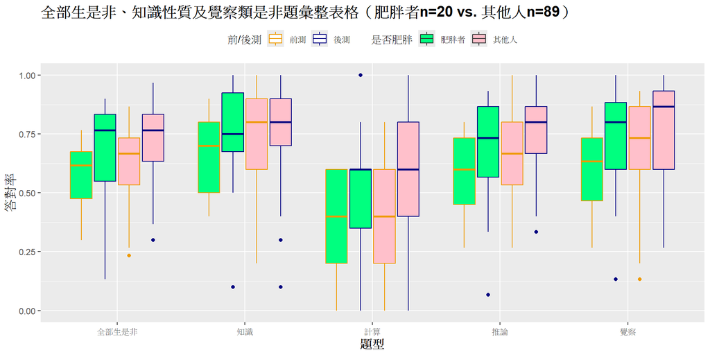

```r
yn.prepost.compare.boxplot(Cdat1_yn%>%filter(Cfat&(Cfat.bf|Cnofat.bf)),
                           Cdat2_yn%>%filter(Cfat&(Cfat.bf|Cnofat.bf)),
                           Cdat1_yn%>%filter(Cnofat&(Cfat.bf|Cnofat.bf)),
                           Cdat2_yn%>%filter(Cnofat&(Cfat.bf|Cnofat.bf)), state=2, title="全部生是非、知識性質及覺察類是非題彙整表格（肥胖者n=20 vs. 其他人n=89）")
```

# **8. 早餐肥胖程度的影響分析**

## **8-1 是非題前後測答對率（早餐肥胖者n=23 vs. 其他人n=86）**

```r
kk<-yn.prepost.compare.table(Cdat1_yn%>%filter(Cfat.bf), Cdat2_yn%>%filter(Cfat.bf),
                             Cdat1_yn%>%filter(!Cfat.bf), Cdat2_yn%>%filter(!Cfat.bf), 3)

colnames(kk)<-c("","","平均答對率","標準差","平均答對率","標準差","t統計量","p-value","檢定結果")


kk[,7]<-kk[,7]%>%as.numeric%>%round(digits=3)

kk[,8]<-str_c(kk[,8]%>%as.numeric%>%round(digits=3),cut(kk[,8]%>%as.numeric, breaks=c(0,0.001,0.01,0.05,1),labels=c("***","**","*","")))

kk%>%kable("html",escape = F,booktabs = TRUE, digits=c(0,0,3,2,3,2,3,3,3), caption="8-1 是非題前後測答對率（早餐肥胖者n=23 vs. 其他人n=86）")%>%
  kable_styling(c("striped", "bordered"))%>%
  add_header_above(c(" " = 2, "前測" = 2, "後測" = 2,"前後測成對t檢定" = 3))%>%
  column_spec(1, bold = T)%>%
  collapse_rows(columns = 1)%>%
  group_rows("生是非", 1, 60)%>%
  group_rows("技是非", 61, 80)
```

8-1 是非題前後測答對率（早餐肥胖者n=23 vs. 其他人n=86）

|  |  | 前測 平均答對率 | 前測 標準差 | 後測 平均答對率 | 後測 標準差 | 前後測成對t檢定 t統計量 | 前後測成對t檢定 p-value | 前後測成對t檢定 檢定結果 |
| --- | --- | --- | --- | --- | --- | --- | --- | --- |
| **生是非** |  |  |  |  |  |  |  |  |
| 生是非1 | 早餐肥胖者 | 0.783 | 0.42 | 0.739 | 0.45 | -0.569 | 0.575 | Don’t Reject H0 |
|  | 其他人 | 0.748 | 0.44 | 0.764 | 0.43 | 0.364 | 0.717 | Don’t Reject H0 |
| 生是非2 | 早餐肥胖者 | 0.913 | 0.29 | 0.870 | 0.34 | -0.439 | 0.665 | Don’t Reject H0 |
|  | 其他人 | 0.911 | 0.29 | 0.911 | 0.29 | 0.000 | 1 | No Change |
| 生是非3 | 早餐肥胖者 | 0.826 | 0.39 | 0.913 | 0.29 | 0.810 | 0.426 | Don’t Reject H0 |
|  | 其他人 | 0.756 | 0.43 | 0.813 | 0.39 | 1.260 | 0.21 | Don’t Reject H0 |
| 生是非4 | 早餐肥胖者 | 0.870 | 0.34 | 0.826 | 0.39 | -1.000 | 0.328 | Don’t Reject H0 |
|  | 其他人 | 0.837 | 0.37 | 0.789 | 0.41 | -1.227 | 0.222 | Don’t Reject H0 |
| 生是非5 | 早餐肥胖者 | 0.522 | 0.51 | 0.696 | 0.47 | 2.152 | 0.043* | Reject H0 |
|  | 其他人 | 0.374 | 0.49 | 0.455 | 0.50 | 1.591 | 0.114 | Don’t Reject H0 |
| 生是非6 | 早餐肥胖者 | 0.696 | 0.47 | 0.739 | 0.45 | 0.439 | 0.665 | Don’t Reject H0 |
|  | 其他人 | 0.780 | 0.42 | 0.789 | 0.41 | 0.185 | 0.854 | Don’t Reject H0 |
| 生是非7 | 早餐肥胖者 | 0.957 | 0.21 | 0.826 | 0.39 | -1.367 | 0.186 | Don’t Reject H0 |
|  | 其他人 | 0.764 | 0.43 | 0.821 | 0.38 | 1.185 | 0.238 | Don’t Reject H0 |
| 生是非8 | 早餐肥胖者 | 0.609 | 0.50 | 0.783 | 0.42 | 1.447 | 0.162 | Don’t Reject H0 |
|  | 其他人 | 0.423 | 0.50 | 0.634 | 0.48 | 4.069 | 0*** | Reject H0 |
| 生是非9 | 早餐肥胖者 | 0.957 | 0.21 | 0.870 | 0.34 | -1.447 | 0.162 | Don’t Reject H0 |
|  | 其他人 | 0.886 | 0.32 | 0.886 | 0.32 | 0.000 | 1 | No Change |
| 生是非10 | 早餐肥胖者 | 0.696 | 0.47 | 0.783 | 0.42 | 0.810 | 0.426 | Don’t Reject H0 |
|  | 其他人 | 0.634 | 0.48 | 0.724 | 0.45 | 1.581 | 0.116 | Don’t Reject H0 |
| 生是非11 | 早餐肥胖者 | 0.174 | 0.39 | 0.391 | 0.50 | 1.553 | 0.135 | Don’t Reject H0 |
|  | 其他人 | 0.187 | 0.39 | 0.382 | 0.49 | 3.719 | 0*** | Reject H0 |
| 生是非12 | 早餐肥胖者 | 0.783 | 0.42 | 0.826 | 0.39 | 0.371 | 0.714 | Don’t Reject H0 |
|  | 其他人 | 0.748 | 0.44 | 0.821 | 0.38 | 1.487 | 0.14 | Don’t Reject H0 |
| 生是非13 | 早餐肥胖者 | 0.478 | 0.51 | 0.826 | 0.39 | 2.577 | 0.017* | Reject H0 |
|  | 其他人 | 0.634 | 0.48 | 0.846 | 0.36 | 3.972 | 0*** | Reject H0 |
| 生是非14 | 早餐肥胖者 | 0.739 | 0.45 | 0.652 | 0.49 | -0.624 | 0.539 | Don’t Reject H0 |
|  | 其他人 | 0.715 | 0.45 | 0.650 | 0.48 | -1.377 | 0.171 | Don’t Reject H0 |
| 生是非15 | 早餐肥胖者 | 0.739 | 0.45 | 0.652 | 0.49 | -0.810 | 0.426 | Don’t Reject H0 |

[output cut: 52 more lines]

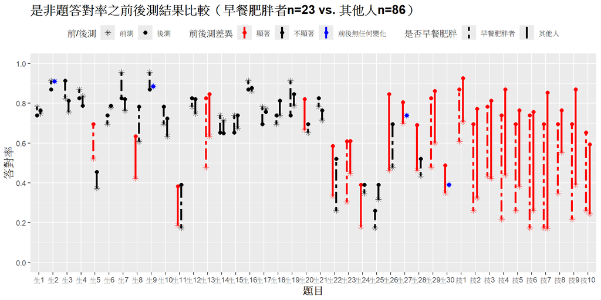

```r
res_fat<-yn.prepost.table(Cdat1_yn%>%filter(Cfat.bf), Cdat2_yn%>%filter(Cfat.bf))
res_nofat<-yn.prepost.table(Cdat1_yn%>%filter(!Cfat.bf), Cdat2_yn%>%filter(!Cfat.bf))
res2<-rbind(res_fat, res_nofat)

yn.prepost.compare.plot(res2, "是非題答對率之前後測結果比較（早餐肥胖者n=23 vs. 其他人n=86）", state=3)
```

## **8-2 知識性質生是非前後測答對率（早餐肥胖者n=23 vs. 其他人n=86）**

```r
kk<-yn_life.prepost.compare.table(Cdat1_yn%>%filter(Cfat.bf), Cdat2_yn%>%filter(Cfat.bf),
                                  Cdat1_yn%>%filter(!Cfat.bf), Cdat2_yn%>%filter(!Cfat.bf),3)%>%
  arrange(知識性質)%>%dplyr::select(!c("知識性質","生活主題","覺察"))

colnames(kk)<-c("","","平均答對率","標準差","平均答對率","標準差","t統計量","p-value","檢定結果")

kk[,7]<-kk[,7]%>%as.numeric%>%round(digits=3)

kk[,8]<-str_c(kk[,8]%>%as.numeric%>%round(digits=3),cut(kk[,8]%>%as.numeric, breaks=c(0,0.001,0.01,0.05,1),labels=c("***","**","*","")))

kk%>%kable("html",escape = F,booktabs = TRUE, digits=c(0,0,3,2,3,2,3,3,3), caption="8-2 知識性質生是非前後測答對率（早餐肥胖者n=23 vs. 其他人n=86）")%>%
  kable_styling(c("striped", "bordered"))%>%
  add_header_above(c(" " = 2, "前測" = 2, "後測" = 2,"前後測成對t檢定" = 3))%>%
  column_spec(1, bold = T)%>%
  collapse_rows(columns = 1)%>%
  group_rows("知識", 1, 20)%>%
  group_rows("推論", 21, 50)%>%
  group_rows("計算", 51, 60)
```

8-2 知識性質生是非前後測答對率（早餐肥胖者n=23 vs. 其他人n=86）

|  |  | 前測 平均答對率 | 前測 標準差 | 後測 平均答對率 | 後測 標準差 | 前後測成對t檢定 t統計量 | 前後測成對t檢定 p-value | 前後測成對t檢定 檢定結果 |
| --- | --- | --- | --- | --- | --- | --- | --- | --- |
| **知識** |  |  |  |  |  |  |  |  |
| 生是非1 | 早餐肥胖者 | 0.783 | 0.42 | 0.739 | 0.45 | -0.569 | 0.575 | Don’t Reject H0 |
|  | 其他人 | 0.748 | 0.44 | 0.764 | 0.43 | 0.364 | 0.717 | Don’t Reject H0 |
| 生是非2 | 早餐肥胖者 | 0.913 | 0.29 | 0.870 | 0.34 | -0.439 | 0.665 | Don’t Reject H0 |
|  | 其他人 | 0.911 | 0.29 | 0.911 | 0.29 | 0.000 | 1 | No Change |
| 生是非4 | 早餐肥胖者 | 0.870 | 0.34 | 0.826 | 0.39 | -1.000 | 0.328 | Don’t Reject H0 |
|  | 其他人 | 0.837 | 0.37 | 0.789 | 0.41 | -1.227 | 0.222 | Don’t Reject H0 |
| 生是非5 | 早餐肥胖者 | 0.522 | 0.51 | 0.696 | 0.47 | 2.152 | 0.043* | Reject H0 |
|  | 其他人 | 0.374 | 0.49 | 0.455 | 0.50 | 1.591 | 0.114 | Don’t Reject H0 |
| 生是非6 | 早餐肥胖者 | 0.696 | 0.47 | 0.739 | 0.45 | 0.439 | 0.665 | Don’t Reject H0 |
|  | 其他人 | 0.780 | 0.42 | 0.789 | 0.41 | 0.185 | 0.854 | Don’t Reject H0 |
| 生是非7 | 早餐肥胖者 | 0.957 | 0.21 | 0.826 | 0.39 | -1.367 | 0.186 | Don’t Reject H0 |
|  | 其他人 | 0.764 | 0.43 | 0.821 | 0.38 | 1.185 | 0.238 | Don’t Reject H0 |
| 生是非13 | 早餐肥胖者 | 0.478 | 0.51 | 0.826 | 0.39 | 2.577 | 0.017* | Reject H0 |
|  | 其他人 | 0.634 | 0.48 | 0.846 | 0.36 | 3.972 | 0*** | Reject H0 |
| 生是非14 | 早餐肥胖者 | 0.739 | 0.45 | 0.652 | 0.49 | -0.624 | 0.539 | Don’t Reject H0 |
|  | 其他人 | 0.715 | 0.45 | 0.650 | 0.48 | -1.377 | 0.171 | Don’t Reject H0 |
| 生是非18 | 早餐肥胖者 | 0.696 | 0.47 | 0.739 | 0.45 | 0.439 | 0.665 | Don’t Reject H0 |
|  | 其他人 | 0.740 | 0.44 | 0.813 | 0.39 | 1.530 | 0.129 | Don’t Reject H0 |
| 生是非29 | 早餐肥胖者 | 0.478 | 0.51 | 0.826 | 0.39 | 2.912 | 0.008** | Reject H0 |
|  | 其他人 | 0.602 | 0.49 | 0.862 | 0.35 | 5.192 | 0*** | Reject H0 |
| **推論** |  |  |  |  |  |  |  |  |
| 生是非3 | 早餐肥胖者 | 0.826 | 0.39 | 0.913 | 0.29 | 0.810 | 0.426 | Don’t Reject H0 |
|  | 其他人 | 0.756 | 0.43 | 0.813 | 0.39 | 1.260 | 0.21 | Don’t Reject H0 |
| 生是非8 | 早餐肥胖者 | 0.609 | 0.50 | 0.783 | 0.42 | 1.447 | 0.162 | Don’t Reject H0 |
|  | 其他人 | 0.423 | 0.50 | 0.634 | 0.48 | 4.069 | 0*** | Reject H0 |
| 生是非9 | 早餐肥胖者 | 0.957 | 0.21 | 0.870 | 0.34 | -1.447 | 0.162 | Don’t Reject H0 |
|  | 其他人 | 0.886 | 0.32 | 0.886 | 0.32 | 0.000 | 1 | No Change |
| 生是非10 | 早餐肥胖者 | 0.696 | 0.47 | 0.783 | 0.42 | 0.810 | 0.426 | Don’t Reject H0 |
|  | 其他人 | 0.634 | 0.48 | 0.724 | 0.45 | 1.581 | 0.116 | Don’t Reject H0 |
| 生是非11 | 早餐肥胖者 | 0.174 | 0.39 | 0.391 | 0.50 | 1.553 | 0.135 | Don’t Reject H0 |
|  | 其他人 | 0.187 | 0.39 | 0.382 | 0.49 | 3.719 | 0*** | Reject H0 |
| 生是非12 | 早餐肥胖者 | 0.783 | 0.42 | 0.826 | 0.39 | 0.371 | 0.714 | Don’t Reject H0 |
|  | 其他人 | 0.748 | 0.44 | 0.821 | 0.38 | 1.487 | 0.14 | Don’t Reject H0 |
| 生是非15 | 早餐肥胖者 | 0.739 | 0.45 | 0.652 | 0.49 | -0.810 | 0.426 | Don’t Reject H0 |
|  | 其他人 | 0.675 | 0.47 | 0.740 | 0.44 | 1.520 | 0.131 | Don’t Reject H0 |
| 生是非16 | 早餐肥胖者 | 0.913 | 0.29 | 0.870 | 0.34 | -0.569 | 0.575 | Don’t Reject H0 |
|  | 其他人 | 0.862 | 0.35 | 0.878 | 0.33 | 0.446 | 0.657 | Don’t Reject H0 |
| 生是非17 | 早餐肥胖者 | 0.783 | 0.42 | 0.696 | 0.47 | -0.699 | 0.492 | Don’t Reject H0 |
|  | 其他人 | 0.772 | 0.42 | 0.756 | 0.43 | -0.315 | 0.753 | Don’t Reject H0 |
| 生是非19 | 早餐肥胖者 | 0.913 | 0.29 | 0.739 | 0.45 | -1.447 | 0.162 | Don’t Reject H0 |
|  | 其他人 | 0.789 | 0.41 | 0.846 | 0.36 | 1.466 | 0.145 | Don’t Reject H0 |
| 生是非20 | 早餐肥胖者 | 0.652 | 0.49 | 0.696 | 0.47 | 0.371 | 0.714 | Don’t Reject H0 |
|  | 其他人 | 0.667 | 0.47 | 0.821 | 0.38 | 3.067 | 0.003** | Reject H0 |
| 生是非21 | 早餐肥胖者 | 0.783 | 0.42 | 0.826 | 0.39 | 0.569 | 0.575 | Don’t Reject H0 |
|  | 其他人 | 0.715 | 0.45 | 0.764 | 0.43 | 1.000 | 0.319 | Don’t Reject H0 |
| 生是非22 | 早餐肥胖者 | 0.261 | 0.45 | 0.522 | 0.51 | 1.817 | 0.083 | Don’t Reject H0 |
|  | 其他人 | 0.333 | 0.47 | 0.585 | 0.49 | 4.494 | 0*** | Reject H0 |
| 生是非23 | 早餐肥胖者 | 0.304 | 0.47 | 0.609 | 0.50 | 2.612 | 0.016* | Reject H0 |
|  | 其他人 | 0.447 | 0.50 | 0.610 | 0.49 | 3.379 | 0.001*** | Reject H0 |
| 生是非27 | 早餐肥胖者 | 0.739 | 0.45 | 0.739 | 0.45 | 0.000 | 1 | No Change |
|  | 其他人 | 0.699 | 0.46 | 0.805 | 0.40 | 2.169 | 0.032* | Reject H0 |
| **計算** |  |  |  |  |  |  |  |  |
| 生是非24 | 早餐肥胖者 | 0.348 | 0.49 | 0.391 | 0.50 | 0.327 | 0.747 | Don’t Reject H0 |
|  | 其他人 | 0.179 | 0.38 | 0.390 | 0.49 | 3.882 | 0*** | Reject H0 |
| 生是非25 | 早餐肥胖者 | 0.174 | 0.39 | 0.261 | 0.45 | 0.810 | 0.426 | Don’t Reject H0 |
|  | 其他人 | 0.317 | 0.47 | 0.390 | 0.49 | 1.487 | 0.14 | Don’t Reject H0 |
| 生是非26 | 早餐肥胖者 | 0.478 | 0.51 | 0.696 | 0.47 | 1.553 | 0.135 | Don’t Reject H0 |
|  | 其他人 | 0.463 | 0.50 | 0.846 | 0.36 | 7.491 | 0*** | Reject H0 |
| 生是非28 | 早餐肥胖者 | 0.435 | 0.51 | 0.522 | 0.51 | 0.569 | 0.575 | Don’t Reject H0 |
|  | 其他人 | 0.463 | 0.50 | 0.691 | 0.46 | 3.808 | 0*** | Reject H0 |
| 生是非30 | 早餐肥胖者 | 0.391 | 0.50 | 0.391 | 0.50 | 0.000 | 1 | No Change |
|  | 其他人 | 0.350 | 0.48 | 0.488 | 0.50 | 2.723 | 0.007** | Reject H0 |

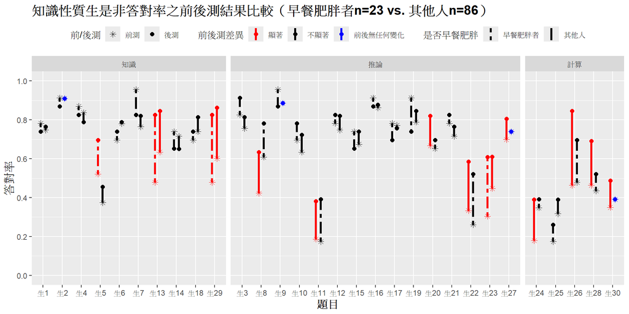

```r
res_fat<-yn_life.prepost.table(Cdat1_yn%>%filter(Cfat.bf), Cdat2_yn%>%filter(Cfat.bf))
res_nofat<-yn_life.prepost.table(Cdat1_yn%>%filter(!Cfat.bf), Cdat2_yn%>%filter(!Cfat.bf))
res21<-rbind(res_fat, res_nofat)

yn.prepost.compare.plot(res21, "知識性質生是非答對率之前後測結果比較（早餐肥胖者n=23 vs. 其他人n=86）", state=3)+
  facet_grid(cols=vars(知識性質), scales = "free", space = "free")
```

## **8-3 生活主題生是非前後測答對率（早餐肥胖者n=23 vs. 其他人n=86）**

```r
kk<-yn_life.prepost.compare.table(Cdat1_yn%>%filter(Cfat.bf), Cdat2_yn%>%filter(Cfat.bf),
                                  Cdat1_yn%>%filter(!Cfat.bf), Cdat2_yn%>%filter(!Cfat.bf),3)%>%
  arrange(生活主題)
kk1<-kk%>%dplyr::select(!c("知識性質","生活主題","覺察"))
colnames(kk1)<-c("","","平均答對率","標準差","平均答對率","標準差","t統計量","p-value","檢定結果")

kk1[,7]<-kk1[,7]%>%as.numeric%>%round(digits=3)

kk1[,8]<-str_c(kk1[,8]%>%as.numeric%>%round(digits=3),cut(kk1[,8]%>%as.numeric, breaks=c(0,0.001,0.01,0.05,1),labels=c("***","**","*","")))

kk1%>%kable("html",escape = F,booktabs = TRUE, digits=c(0,0,3,2,3,2,3,3,3), caption="8-3 生活主題生是非前後測答對率（早餐肥胖者n=23 vs. 其他人n=86）")%>%
  kable_styling(c("striped", "bordered"))%>%
  add_header_above(c(" " = 2, "前測" = 2, "後測" = 2,"前後測成對t檢定" = 3))%>%
  column_spec(1, bold = T)%>%
  collapse_rows(columns = 1)%>%
  group_rows(levels(kk$生活主題)[1], 1, cumsum(table(kk$生活主題))[[1]])%>%
  group_rows(levels(kk$生活主題)[2], cumsum(table(kk$生活主題))[[1]]+1, cumsum(table(kk$生活主題))[[2]])%>%
  group_rows(levels(kk$生活主題)[3], cumsum(table(kk$生活主題))[[2]]+1, cumsum(table(kk$生活主題))[[3]])%>%
  group_rows(levels(kk$生活主題)[4], cumsum(table(kk$生活主題))[[3]]+1, cumsum(table(kk$生活主題))[[4]])%>%
  group_rows(levels(kk$生活主題)[5], cumsum(table(kk$生活主題))[[4]]+1, cumsum(table(kk$生活主題))[[5]])%>%
  group_rows(levels(kk$生活主題)[6], cumsum(table(kk$生活主題))[[5]]+1, cumsum(table(kk$生活主題))[[6]])%>%
  group_rows(levels(kk$生活主題)[7], cumsum(table(kk$生活主題))[[6]]+1, cumsum(table(kk$生活主題))[[7]])%>%
  group_rows(levels(kk$生活主題)[8], cumsum(table(kk$生活主題))[[7]]+1, cumsum(table(kk$生活主題))[[8]])
```

8-3 生活主題生是非前後測答對率（早餐肥胖者n=23 vs. 其他人n=86）

|  |  | 前測 平均答對率 | 前測 標準差 | 後測 平均答對率 | 後測 標準差 | 前後測成對t檢定 t統計量 | 前後測成對t檢定 p-value | 前後測成對t檢定 檢定結果 |
| --- | --- | --- | --- | --- | --- | --- | --- | --- |
| **01營養素** |  |  |  |  |  |  |  |  |
| 生是非1 | 早餐肥胖者 | 0.783 | 0.42 | 0.739 | 0.45 | -0.569 | 0.575 | Don’t Reject H0 |
|  | 其他人 | 0.748 | 0.44 | 0.764 | 0.43 | 0.364 | 0.717 | Don’t Reject H0 |
| 生是非2 | 早餐肥胖者 | 0.913 | 0.29 | 0.870 | 0.34 | -0.439 | 0.665 | Don’t Reject H0 |
|  | 其他人 | 0.911 | 0.29 | 0.911 | 0.29 | 0.000 | 1 | No Change |
| 生是非4 | 早餐肥胖者 | 0.870 | 0.34 | 0.826 | 0.39 | -1.000 | 0.328 | Don’t Reject H0 |
|  | 其他人 | 0.837 | 0.37 | 0.789 | 0.41 | -1.227 | 0.222 | Don’t Reject H0 |
| 生是非24 | 早餐肥胖者 | 0.348 | 0.49 | 0.391 | 0.50 | 0.327 | 0.747 | Don’t Reject H0 |
|  | 其他人 | 0.179 | 0.38 | 0.390 | 0.49 | 3.882 | 0*** | Reject H0 |
| **02細胞** |  |  |  |  |  |  |  |  |
| 生是非3 | 早餐肥胖者 | 0.826 | 0.39 | 0.913 | 0.29 | 0.810 | 0.426 | Don’t Reject H0 |
|  | 其他人 | 0.756 | 0.43 | 0.813 | 0.39 | 1.260 | 0.21 | Don’t Reject H0 |
| 生是非5 | 早餐肥胖者 | 0.522 | 0.51 | 0.696 | 0.47 | 2.152 | 0.043* | Reject H0 |
|  | 其他人 | 0.374 | 0.49 | 0.455 | 0.50 | 1.591 | 0.114 | Don’t Reject H0 |
| 生是非8 | 早餐肥胖者 | 0.609 | 0.50 | 0.783 | 0.42 | 1.447 | 0.162 | Don’t Reject H0 |
|  | 其他人 | 0.423 | 0.50 | 0.634 | 0.48 | 4.069 | 0*** | Reject H0 |
| 生是非10 | 早餐肥胖者 | 0.696 | 0.47 | 0.783 | 0.42 | 0.810 | 0.426 | Don’t Reject H0 |
|  | 其他人 | 0.634 | 0.48 | 0.724 | 0.45 | 1.581 | 0.116 | Don’t Reject H0 |
| **03食物** |  |  |  |  |  |  |  |  |
| 生是非12 | 早餐肥胖者 | 0.783 | 0.42 | 0.826 | 0.39 | 0.371 | 0.714 | Don’t Reject H0 |
|  | 其他人 | 0.748 | 0.44 | 0.821 | 0.38 | 1.487 | 0.14 | Don’t Reject H0 |
| 生是非18 | 早餐肥胖者 | 0.696 | 0.47 | 0.739 | 0.45 | 0.439 | 0.665 | Don’t Reject H0 |
|  | 其他人 | 0.740 | 0.44 | 0.813 | 0.39 | 1.530 | 0.129 | Don’t Reject H0 |
| 生是非20 | 早餐肥胖者 | 0.652 | 0.49 | 0.696 | 0.47 | 0.371 | 0.714 | Don’t Reject H0 |
|  | 其他人 | 0.667 | 0.47 | 0.821 | 0.38 | 3.067 | 0.003** | Reject H0 |
| 生是非23 | 早餐肥胖者 | 0.304 | 0.47 | 0.609 | 0.50 | 2.612 | 0.016* | Reject H0 |
|  | 其他人 | 0.447 | 0.50 | 0.610 | 0.49 | 3.379 | 0.001*** | Reject H0 |
| 生是非30 | 早餐肥胖者 | 0.391 | 0.50 | 0.391 | 0.50 | 0.000 | 1 | No Change |
|  | 其他人 | 0.350 | 0.48 | 0.488 | 0.50 | 2.723 | 0.007** | Reject H0 |
| **04飲食習慣** |  |  |  |  |  |  |  |  |
| 生是非6 | 早餐肥胖者 | 0.696 | 0.47 | 0.739 | 0.45 | 0.439 | 0.665 | Don’t Reject H0 |
|  | 其他人 | 0.780 | 0.42 | 0.789 | 0.41 | 0.185 | 0.854 | Don’t Reject H0 |
| 生是非9 | 早餐肥胖者 | 0.957 | 0.21 | 0.870 | 0.34 | -1.447 | 0.162 | Don’t Reject H0 |
|  | 其他人 | 0.886 | 0.32 | 0.886 | 0.32 | 0.000 | 1 | No Change |
| 生是非15 | 早餐肥胖者 | 0.739 | 0.45 | 0.652 | 0.49 | -0.810 | 0.426 | Don’t Reject H0 |
|  | 其他人 | 0.675 | 0.47 | 0.740 | 0.44 | 1.520 | 0.131 | Don’t Reject H0 |
| 生是非16 | 早餐肥胖者 | 0.913 | 0.29 | 0.870 | 0.34 | -0.569 | 0.575 | Don’t Reject H0 |
|  | 其他人 | 0.862 | 0.35 | 0.878 | 0.33 | 0.446 | 0.657 | Don’t Reject H0 |
| 生是非17 | 早餐肥胖者 | 0.783 | 0.42 | 0.696 | 0.47 | -0.699 | 0.492 | Don’t Reject H0 |
|  | 其他人 | 0.772 | 0.42 | 0.756 | 0.43 | -0.315 | 0.753 | Don’t Reject H0 |
| **05運動** |  |  |  |  |  |  |  |  |
| 生是非7 | 早餐肥胖者 | 0.957 | 0.21 | 0.826 | 0.39 | -1.367 | 0.186 | Don’t Reject H0 |
|  | 其他人 | 0.764 | 0.43 | 0.821 | 0.38 | 1.185 | 0.238 | Don’t Reject H0 |
| 生是非27 | 早餐肥胖者 | 0.739 | 0.45 | 0.739 | 0.45 | 0.000 | 1 | No Change |
|  | 其他人 | 0.699 | 0.46 | 0.805 | 0.40 | 2.169 | 0.032* | Reject H0 |
| **06肥胖** |  |  |  |  |  |  |  |  |
| 生是非11 | 早餐肥胖者 | 0.174 | 0.39 | 0.391 | 0.50 | 1.553 | 0.135 | Don’t Reject H0 |
|  | 其他人 | 0.187 | 0.39 | 0.382 | 0.49 | 3.719 | 0*** | Reject H0 |
| 生是非25 | 早餐肥胖者 | 0.174 | 0.39 | 0.261 | 0.45 | 0.810 | 0.426 | Don’t Reject H0 |
|  | 其他人 | 0.317 | 0.47 | 0.390 | 0.49 | 1.487 | 0.14 | Don’t Reject H0 |
| 生是非26 | 早餐肥胖者 | 0.478 | 0.51 | 0.696 | 0.47 | 1.553 | 0.135 | Don’t Reject H0 |
|  | 其他人 | 0.463 | 0.50 | 0.846 | 0.36 | 7.491 | 0*** | Reject H0 |
| **07糖尿病** |  |  |  |  |  |  |  |  |
| 生是非13 | 早餐肥胖者 | 0.478 | 0.51 | 0.826 | 0.39 | 2.577 | 0.017* | Reject H0 |
|  | 其他人 | 0.634 | 0.48 | 0.846 | 0.36 | 3.972 | 0*** | Reject H0 |
| 生是非14 | 早餐肥胖者 | 0.739 | 0.45 | 0.652 | 0.49 | -0.624 | 0.539 | Don’t Reject H0 |
|  | 其他人 | 0.715 | 0.45 | 0.650 | 0.48 | -1.377 | 0.171 | Don’t Reject H0 |
| 生是非19 | 早餐肥胖者 | 0.913 | 0.29 | 0.739 | 0.45 | -1.447 | 0.162 | Don’t Reject H0 |
|  | 其他人 | 0.789 | 0.41 | 0.846 | 0.36 | 1.466 | 0.145 | Don’t Reject H0 |
| 生是非21 | 早餐肥胖者 | 0.783 | 0.42 | 0.826 | 0.39 | 0.569 | 0.575 | Don’t Reject H0 |
|  | 其他人 | 0.715 | 0.45 | 0.764 | 0.43 | 1.000 | 0.319 | Don’t Reject H0 |
| 生是非22 | 早餐肥胖者 | 0.261 | 0.45 | 0.522 | 0.51 | 1.817 | 0.083 | Don’t Reject H0 |
|  | 其他人 | 0.333 | 0.47 | 0.585 | 0.49 | 4.494 | 0*** | Reject H0 |
| 生是非28 | 早餐肥胖者 | 0.435 | 0.51 | 0.522 | 0.51 | 0.569 | 0.575 | Don’t Reject H0 |
|  | 其他人 | 0.463 | 0.50 | 0.691 | 0.46 | 3.808 | 0*** | Reject H0 |
| **08量測** |  |  |  |  |  |  |  |  |
| 生是非29 | 早餐肥胖者 | 0.478 | 0.51 | 0.826 | 0.39 | 2.912 | 0.008** | Reject H0 |
|  | 其他人 | 0.602 | 0.49 | 0.862 | 0.35 | 5.192 | 0*** | Reject H0 |

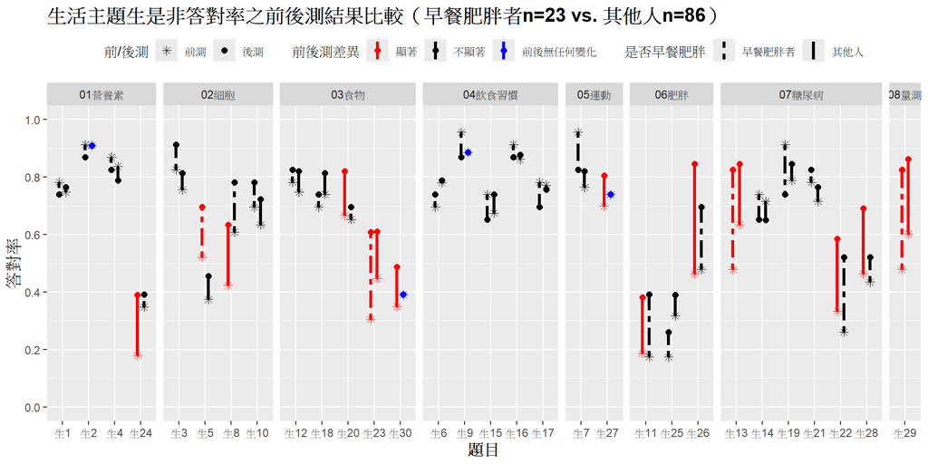

```r
yn.prepost.compare.plot(res21, "生活主題生是非答對率之前後測結果比較（早餐肥胖者n=23 vs. 其他人n=86）", state=3)+
  facet_grid(cols=vars(生活主題), scales = "free", space = "free")
```

## **8-4 覺察類生是非前後測答對率（早餐肥胖者n=23 vs. 其他人n=86）**

```r
kk<-yn_life.prepost.compare.table(Cdat1_yn%>%filter(Cfat.bf), Cdat2_yn%>%filter(Cfat.bf),
                                  Cdat1_yn%>%filter(!Cfat.bf), Cdat2_yn%>%filter(!Cfat.bf),3)%>%
  filter(覺察==1)%>%dplyr::select(!c("知識性質","生活主題","覺察"))

colnames(kk)<-c("","","平均答對率","標準差","平均答對率","標準差","t統計量","p-value","檢定結果")

kk[,7]<-kk[,7]%>%as.numeric%>%round(digits=3)

kk[,8]<-str_c(kk[,8]%>%as.numeric%>%round(digits=3),cut(kk[,8]%>%as.numeric, breaks=c(0,0.001,0.01,0.05,1),labels=c("***","**","*","")))

kk%>%kable("html",escape = F,booktabs = TRUE, digits=c(0,0,3,2,3,2,3,3,3), caption="8-4 覺察類生是非前後測答對率（早餐肥胖者n=23 vs. 其他人n=86）")%>%
  kable_styling(c("striped", "bordered"))%>%
  add_header_above(c(" " = 2, "前測" = 2, "後測" = 2,"前後測成對t檢定" = 3))%>%
  column_spec(1, bold = T)%>%
  collapse_rows(columns = 1)%>%
  group_rows("覺察", 1, dim(kk)[1])
```

8-4 覺察類生是非前後測答對率（早餐肥胖者n=23 vs. 其他人n=86）

|  |  | 前測 平均答對率 | 前測 標準差 | 後測 平均答對率 | 後測 標準差 | 前後測成對t檢定 t統計量 | 前後測成對t檢定 p-value | 前後測成對t檢定 檢定結果 |
| --- | --- | --- | --- | --- | --- | --- | --- | --- |
| **覺察** |  |  |  |  |  |  |  |  |
| 生是非2 | 早餐肥胖者 | 0.913 | 0.29 | 0.870 | 0.34 | -0.439 | 0.665 | Don’t Reject H0 |
|  | 其他人 | 0.911 | 0.29 | 0.911 | 0.29 | 0.000 | 1 | No Change |
| 生是非6 | 早餐肥胖者 | 0.696 | 0.47 | 0.739 | 0.45 | 0.439 | 0.665 | Don’t Reject H0 |
|  | 其他人 | 0.780 | 0.42 | 0.789 | 0.41 | 0.185 | 0.854 | Don’t Reject H0 |
| 生是非9 | 早餐肥胖者 | 0.957 | 0.21 | 0.870 | 0.34 | -1.447 | 0.162 | Don’t Reject H0 |
|  | 其他人 | 0.886 | 0.32 | 0.886 | 0.32 | 0.000 | 1 | No Change |
| 生是非11 | 早餐肥胖者 | 0.174 | 0.39 | 0.391 | 0.50 | 1.553 | 0.135 | Don’t Reject H0 |
|  | 其他人 | 0.187 | 0.39 | 0.382 | 0.49 | 3.719 | 0*** | Reject H0 |
| 生是非12 | 早餐肥胖者 | 0.783 | 0.42 | 0.826 | 0.39 | 0.371 | 0.714 | Don’t Reject H0 |
|  | 其他人 | 0.748 | 0.44 | 0.821 | 0.38 | 1.487 | 0.14 | Don’t Reject H0 |
| 生是非13 | 早餐肥胖者 | 0.478 | 0.51 | 0.826 | 0.39 | 2.577 | 0.017* | Reject H0 |
|  | 其他人 | 0.634 | 0.48 | 0.846 | 0.36 | 3.972 | 0*** | Reject H0 |
| 生是非15 | 早餐肥胖者 | 0.739 | 0.45 | 0.652 | 0.49 | -0.810 | 0.426 | Don’t Reject H0 |
|  | 其他人 | 0.675 | 0.47 | 0.740 | 0.44 | 1.520 | 0.131 | Don’t Reject H0 |
| 生是非16 | 早餐肥胖者 | 0.913 | 0.29 | 0.870 | 0.34 | -0.569 | 0.575 | Don’t Reject H0 |
|  | 其他人 | 0.862 | 0.35 | 0.878 | 0.33 | 0.446 | 0.657 | Don’t Reject H0 |
| 生是非17 | 早餐肥胖者 | 0.783 | 0.42 | 0.696 | 0.47 | -0.699 | 0.492 | Don’t Reject H0 |
|  | 其他人 | 0.772 | 0.42 | 0.756 | 0.43 | -0.315 | 0.753 | Don’t Reject H0 |
| 生是非18 | 早餐肥胖者 | 0.696 | 0.47 | 0.739 | 0.45 | 0.439 | 0.665 | Don’t Reject H0 |
|  | 其他人 | 0.740 | 0.44 | 0.813 | 0.39 | 1.530 | 0.129 | Don’t Reject H0 |
| 生是非19 | 早餐肥胖者 | 0.913 | 0.29 | 0.739 | 0.45 | -1.447 | 0.162 | Don’t Reject H0 |
|  | 其他人 | 0.789 | 0.41 | 0.846 | 0.36 | 1.466 | 0.145 | Don’t Reject H0 |
| 生是非20 | 早餐肥胖者 | 0.652 | 0.49 | 0.696 | 0.47 | 0.371 | 0.714 | Don’t Reject H0 |
|  | 其他人 | 0.667 | 0.47 | 0.821 | 0.38 | 3.067 | 0.003** | Reject H0 |
| 生是非23 | 早餐肥胖者 | 0.304 | 0.47 | 0.609 | 0.50 | 2.612 | 0.016* | Reject H0 |
|  | 其他人 | 0.447 | 0.50 | 0.610 | 0.49 | 3.379 | 0.001*** | Reject H0 |
| 生是非26 | 早餐肥胖者 | 0.478 | 0.51 | 0.696 | 0.47 | 1.553 | 0.135 | Don’t Reject H0 |
|  | 其他人 | 0.463 | 0.50 | 0.846 | 0.36 | 7.491 | 0*** | Reject H0 |
| 生是非27 | 早餐肥胖者 | 0.739 | 0.45 | 0.739 | 0.45 | 0.000 | 1 | No Change |
|  | 其他人 | 0.699 | 0.46 | 0.805 | 0.40 | 2.169 | 0.032* | Reject H0 |

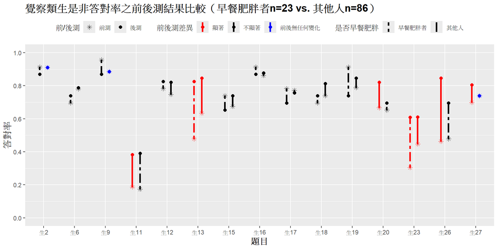

```r
yn.prepost.compare.plot(res21[res21$覺察==1,], "覺察類生是非答對率之前後測結果比較（早餐肥胖者n=23 vs. 其他人n=86）", state = 3)
```

## **8-5 計算全部人/早餐肥胖者/其他人彙整表格（分成生是非、技是非兩種情形）**

```r
mean_score<-matrix(NA,3,12)
rownames(mean_score)<-c("全部人 (n=109)","早餐肥胖者 (n=23)","其他人 (n=86)")
colnames(mean_score)<-rep(c("平均答對率","標準差","平均答對率","標準差","t統計量","p-value"),2)

mean_score[1,]<-mean_table(Cdat1_yn%>%filter(Cfat.bf|Cnofat.bf), Cdat2_yn%>%filter(Cfat.bf|Cnofat.bf))
mean_score[2,]<-mean_table(Cdat1_yn%>%filter(Cfat.bf), Cdat2_yn%>%filter(Cfat.bf))
mean_score[3,]<-mean_table(Cdat1_yn%>%filter(Cnofat.bf), Cdat2_yn%>%filter(Cnofat.bf))

mean_score[,6]<-str_c(mean_score[,6]%>%as.numeric()%>%round(digits=3),cut(mean_score[,6]%>%as.numeric(), breaks=c(0,0.001,0.01,0.05,1),labels=c("***","**","*","")))

mean_score[,12]<-str_c(mean_score[,12]%>%as.numeric()%>%round(digits=3),cut(mean_score[,12]%>%as.numeric(), breaks=c(0,0.001,0.01,0.05,1),labels=c("***","**","*","")))

mean_score%>%kableExtra::kable("html",escape = F,booktabs = TRUE, caption="8-5 計算全部人/早餐肥胖者/其他人彙整表格（分成生是非、技是非兩種情形）")%>%
  kable_styling(c("striped", "bordered"))%>%
  add_header_above(c(" " = 1, "前測" = 2, "後測" = 2, "前後測成對t檢定" = 2,  "前測" = 2, "後測" = 2, "前後測成對t檢定" = 2))%>%
  add_header_above(c(" " = 1, "生是非" = 6, "技是非" = 6))%>%
  column_spec(1, bold = T)
```

8-5 計算全部人/早餐肥胖者/其他人彙整表格（分成生是非、技是非兩種情形）

|  | 生是非 前測 平均答對率 | 生是非 前測 標準差 | 生是非 後測 平均答對率 | 生是非 後測 標準差 | 生是非 前後測成對t檢定 t統計量 | 生是非 前後測成對t檢定 p-value | 技是非 前測 平均答對率 | 技是非 前測 標準差 | 技是非 後測 平均答對率 | 技是非 後測 標準差 | 技是非 前後測成對t檢定 t統計量 | 技是非 前後測成對t檢定 p-value |
| --- | --- | --- | --- | --- | --- | --- | --- | --- | --- | --- | --- | --- |
| 全部人 (n=109) | 0.621 | 0.16 | 0.717 | 0.17 | 5.727 | 0*** | 0.372 | 0.3 | 0.785 | 0.26 | 13.373 | 0*** |
| 早餐肥胖者 (n=23) | 0.636 | 0.12 | 0.697 | 0.18 | 1.766 | 0.091 | 0.296 | 0.29 | 0.726 | 0.34 | 6.162 | 0*** |
| 其他人 (n=86) | 0.617 | 0.17 | 0.722 | 0.16 | 5.516 | 0*** | 0.392 | 0.3 | 0.801 | 0.23 | 11.802 | 0*** |

```r
#write.xlsx(mean_score, rowNames=T,startCol=1,"C:/Users/h2407/OneDrive/文件/1121/師培中心分析案/報表資料檔/生是非與技是非的整體平均.xlsx")
```

### **8-5-1 全部生是非、知識性質及覺察類是非題彙整表格（早餐肥胖者n=23 vs. 其他人n=86）**

```r
kk<-mean_table_all2(Cdat1_yn%>%filter(Cfat.bf), Cdat2_yn%>%filter(Cfat.bf),
                   Cdat1_yn%>%filter(Cnofat.bf), Cdat2_yn%>%filter(Cnofat.bf), state=3)

kk[[1]]%>%kableExtra::kable("html",escape = F,booktabs = TRUE,digits=c(0,0,3,2,3,2,3,3,3,3,3,3,3,3,3,3,3,3),caption="8-5-1 全部生是非、知識性質及覺察類是非題彙整表格（早餐肥胖者n=23 vs. 其他人n=86）")%>%
  kable_styling(c("striped", "bordered"))%>%
  add_header_above(c(" " = 2, "前測" = 2, "後測" = 2,"前後測成對t檢定" = 3, "早餐肥胖者-其他人獨立t檢定 (進步量)"=3, "早餐肥胖者-其他人獨立t檢定 (前測)"=3, "早餐肥胖者-其他人獨立t檢定 (後測)"=3))%>%
  column_spec(1, bold = T)%>%
  collapse_rows(columns = c(1,10:18))
```

8-5-1 全部生是非、知識性質及覺察類是非題彙整表格（早餐肥胖者n=23 vs. 其他人n=86）

|  |  | 前測 平均答對率 | 前測 標準差 | 後測 平均答對率 | 後測 標準差 | 前後測成對t檢定 平均進步量 | 前後測成對t檢定 t統計量 | 前後測成對t檢定 p-value | 早餐肥胖者-其他人獨立t檢定 (進步量) 早餐肥胖者-其他人進步量差異 | 早餐肥胖者-其他人獨立t檢定 (進步量) t統計量 | 早餐肥胖者-其他人獨立t檢定 (進步量) p-value | 早餐肥胖者-其他人獨立t檢定 (前測) 早餐肥胖者-其他人組間平均差異 | 早餐肥胖者-其他人獨立t檢定 (前測) t統計量 | 早餐肥胖者-其他人獨立t檢定 (前測) p-value | 早餐肥胖者-其他人獨立t檢定 (後測) 早餐肥胖者-其他人組間平均差異 | 早餐肥胖者-其他人獨立t檢定 (後測) t統計量 | 早餐肥胖者-其他人獨立t檢定 (後測) p-value |  |  |  |  |  |  |  |  |  |  |  |  | … |
| --- | --- | --- | --- | --- | --- | --- | --- | --- | --- | --- | --- | --- | --- | --- | --- | --- | --- | --- | --- | --- | --- | --- | --- | --- | --- | --- | --- | --- | --- | --- |
| 全部生是非 | 早餐肥胖者 | 0.636 | 0.12 | 0.697 | 0.18 | 0.061 | 1.766 | 0.091 | -0.044 | -1.113 | 0.273 | 0.019 | 0.608 | 0.547 | -0.025 | -0.588 | 0.56 |  |  |  |  |  |  |  |  |  |  |  |  | … |
|  | 其他人 | 0.617 | 0.17 | 0.722 | 0.16 | 0.105 | 5.516 | 0*** |  |  |  |  |  |  |  |  |  |  |  |  |  |  |  |  |  |  |  |  |  | … |
| 知識 | 早餐肥胖者 | 0.713 | 0.15 | 0.774 | 0.21 | 0.061 | 1.576 | 0.129 |  |  |  |  |  |  |  |  |  | 0.006 | 0.140 | 0.889 | 0.003 | 0.071 | 0.944 | 0.009 | 0.182 | 0.856 |  |  |  | … |
|  | 其他人 | 0.710 | 0.19 | 0.765 | 0.19 | 0.055 | 2.507 | 0.014* |  |  |  |  |  |  |  |  |  |  |  |  |  |  |  |  |  |  |  |  |  | … |
| 推論 | 早餐肥胖者 | 0.675 | 0.13 | 0.728 | 0.20 | 0.052 | 1.410 | 0.173 | -0.054 | -1.275 | 0.21 | 0.037 | 1.090 | 0.281 | -0.017 | -0.366 | 0.717 |  |  |  |  |  |  |  |  |  |  |  |  | … |
|  | 其他人 | 0.638 | 0.19 | 0.744 | 0.18 | 0.106 | 5.145 | 0*** |  |  |  |  |  |  |  |  |  |  |  |  |  |  |  |  |  |  |  |  |  | … |
| 計算 | 早餐肥胖者 | 0.365 | 0.27 | 0.452 | 0.30 | 0.087 | 1.226 | 0.233 |  |  |  |  |  |  |  |  |  |  |  |  |  |  |  |  |  |  | -0.113 | -1.444 | 0.158 | … |
|  | 其他人 | 0.367 | 0.26 | 0.567 | 0.23 | 0.200 | 6.046 | 0*** |  |  |  |  |  |  |  |  |  |  |  |  |  |  |  |  |  |  |  |  |  | … |
| 覺察 | 早餐肥胖者 | 0.681 | 0.15 | 0.730 | 0.19 | 0.049 | 1.274 | 0.216 | -0.062 | -1.363 | 0.181 | 0.006 | 0.155 | 0.878 | -0.056 | -1.217 | 0.232 |  |  |  |  |  |  |  |  |  |  |  |  | … |
|  | 其他人 | 0.675 | 0.20 | 0.786 | 0.20 | 0.111 | 4.746 | 0*** |  |  |  |  |  |  |  |  |  |  |  |  |  |  |  |  |  |  |  |  |  | … |

### **8-5-2 全部生是非、知識性質及覺察類是非題盒形圖（早餐肥胖者n=23 vs. 其他人n=86）**

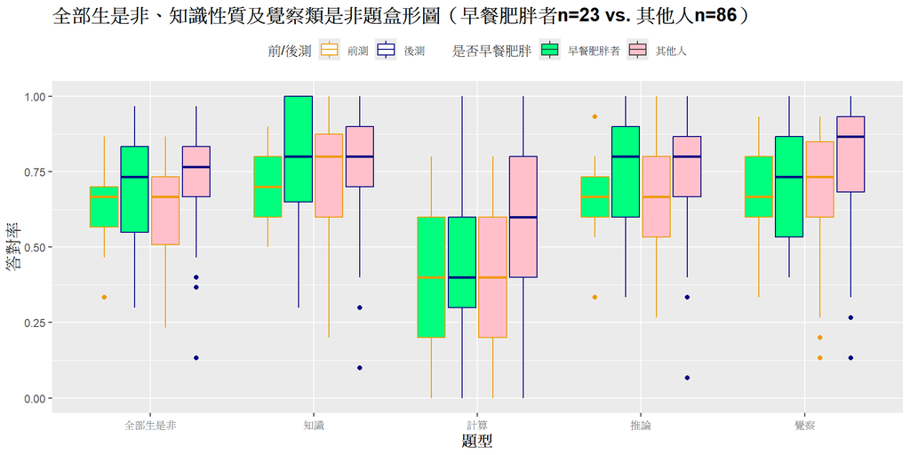

```r
yn.prepost.compare.boxplot(Cdat1_yn%>%filter(Cfat.bf), Cdat2_yn%>%filter(Cfat.bf),
                   Cdat1_yn%>%filter(Cnofat.bf), Cdat2_yn%>%filter(Cnofat.bf), state=3,
                   title="全部生是非、知識性質及覺察類是非題盒形圖（早餐肥胖者n=23 vs. 其他人n=86）")
```

# **9. 性別的影響分析**

```r
Cboy<-Cdat1_yn$流水號%in%(eat%>%filter(性別=="男"))$流水號
```

## **9-1 是非題前後測答對率（男n=79 vs. 女n=67）**

```r
kk<-yn.prepost.compare.table(Cdat1_yn%>%filter(Cboy), Cdat2_yn%>%filter(Cboy),
                             Cdat1_yn%>%filter(!Cboy), Cdat2_yn%>%filter(!Cboy), state=4)

colnames(kk)<-c("","","平均答對率","標準差","平均答對率","標準差","t統計量","p-value","檢定結果")


kk[,7]<-kk[,7]%>%as.numeric%>%round(digits=3)

kk[,8]<-str_c(kk[,8]%>%as.numeric%>%round(digits=3),cut(kk[,8]%>%as.numeric, breaks=c(0,0.001,0.01,0.05,1),labels=c("***","**","*","")))

kk%>%kable("html",escape = F,booktabs = TRUE, digits=c(0,0,3,2,3,2,3,3,3), caption="9-1 是非題前後測答對率（男n=79 vs. 女n=67）")%>%
  kable_styling(c("striped", "bordered"))%>%
  add_header_above(c(" " = 2, "前測" = 2, "後測" = 2,"前後測成對t檢定" = 3))%>%
  column_spec(1, bold = T)%>%
  collapse_rows(columns = 1)%>%
  group_rows("生是非", 1, 60)%>%
  group_rows("技是非", 61, 80)
```

9-1 是非題前後測答對率（男n=79 vs. 女n=67）

|  |  | 前測 平均答對率 | 前測 標準差 | 後測 平均答對率 | 後測 標準差 | 前後測成對t檢定 t統計量 | 前後測成對t檢定 p-value | 前後測成對t檢定 檢定結果 |
| --- | --- | --- | --- | --- | --- | --- | --- | --- |
| **生是非** |  |  |  |  |  |  |  |  |
| 生是非1 | 男 | 0.785 | 0.41 | 0.772 | 0.42 | -0.257 | 0.798 | Don’t Reject H0 |
|  | 女 | 0.716 | 0.45 | 0.746 | 0.44 | 0.469 | 0.641 | Don’t Reject H0 |
| 生是非2 | 男 | 0.911 | 0.29 | 0.886 | 0.32 | -0.575 | 0.567 | Don’t Reject H0 |
|  | 女 | 0.910 | 0.29 | 0.925 | 0.26 | 0.376 | 0.708 | Don’t Reject H0 |
| 生是非3 | 男 | 0.747 | 0.44 | 0.848 | 0.36 | 1.727 | 0.088 | Don’t Reject H0 |
|  | 女 | 0.791 | 0.41 | 0.806 | 0.40 | 0.256 | 0.798 | Don’t Reject H0 |
| 生是非4 | 男 | 0.861 | 0.35 | 0.810 | 0.39 | -1.070 | 0.288 | Don’t Reject H0 |
|  | 女 | 0.821 | 0.39 | 0.776 | 0.42 | -0.903 | 0.37 | Don’t Reject H0 |
| 生是非5 | 男 | 0.405 | 0.49 | 0.494 | 0.50 | 1.409 | 0.163 | Don’t Reject H0 |
|  | 女 | 0.388 | 0.49 | 0.493 | 0.50 | 1.625 | 0.109 | Don’t Reject H0 |
| 生是非6 | 男 | 0.722 | 0.45 | 0.747 | 0.44 | 0.445 | 0.658 | Don’t Reject H0 |
|  | 女 | 0.821 | 0.39 | 0.821 | 0.39 | 0.000 | 1 | No Change |
| 生是非7 | 男 | 0.810 | 0.39 | 0.848 | 0.36 | 0.652 | 0.516 | Don’t Reject H0 |
|  | 女 | 0.776 | 0.42 | 0.791 | 0.41 | 0.228 | 0.821 | Don’t Reject H0 |
| 生是非8 | 男 | 0.456 | 0.50 | 0.671 | 0.47 | 3.230 | 0.002** | Reject H0 |
|  | 女 | 0.448 | 0.50 | 0.642 | 0.48 | 2.851 | 0.006** | Reject H0 |
| 生是非9 | 男 | 0.924 | 0.27 | 0.835 | 0.37 | -1.977 | 0.052 | Don’t Reject H0 |
|  | 女 | 0.866 | 0.34 | 0.940 | 0.24 | 1.928 | 0.058 | Don’t Reject H0 |
| 生是非10 | 男 | 0.646 | 0.48 | 0.722 | 0.45 | 1.097 | 0.276 | Don’t Reject H0 |
|  | 女 | 0.642 | 0.48 | 0.746 | 0.44 | 1.410 | 0.163 | Don’t Reject H0 |
| 生是非11 | 男 | 0.089 | 0.29 | 0.456 | 0.50 | 5.613 | 0*** | Reject H0 |
|  | 女 | 0.299 | 0.46 | 0.299 | 0.46 | 0.000 | 1 | No Change |
| 生是非12 | 男 | 0.722 | 0.45 | 0.810 | 0.39 | 1.354 | 0.18 | Don’t Reject H0 |
|  | 女 | 0.791 | 0.41 | 0.836 | 0.37 | 0.725 | 0.471 | Don’t Reject H0 |
| 生是非13 | 男 | 0.633 | 0.49 | 0.835 | 0.37 | 2.778 | 0.007** | Reject H0 |
|  | 女 | 0.582 | 0.50 | 0.851 | 0.36 | 4.081 | 0*** | Reject H0 |
| 生是非14 | 男 | 0.797 | 0.40 | 0.709 | 0.46 | -1.409 | 0.163 | Don’t Reject H0 |
|  | 女 | 0.627 | 0.49 | 0.582 | 0.50 | -0.686 | 0.495 | Don’t Reject H0 |
| 生是非15 | 男 | 0.684 | 0.47 | 0.658 | 0.48 | -0.445 | 0.658 | Don’t Reject H0 |

[output cut: 52 more lines]

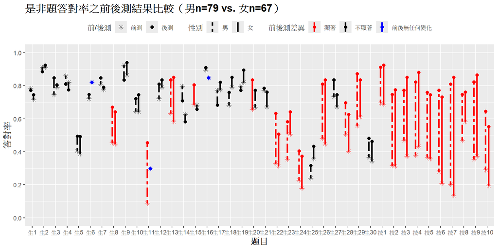

```r
res_boy<-yn.prepost.table(Cdat1_yn%>%filter(Cboy), Cdat2_yn%>%filter(Cboy))
res_girl<-yn.prepost.table(Cdat1_yn%>%filter(!Cboy), Cdat2_yn%>%filter(!Cboy))
res2<-rbind(res_boy, res_girl)

yn.prepost.compare.plot(res2, "是非題答對率之前後測結果比較（男n=79 vs. 女n=67）", state=4)
```

## **9-2 知識性質生是非前後測答對率（男n=79 vs. 女n=67）**

```r
kk<-yn_life.prepost.compare.table(Cdat1_yn%>%filter(Cboy), Cdat2_yn%>%filter(Cboy),
                                  Cdat1_yn%>%filter(!Cboy), Cdat2_yn%>%filter(!Cboy),state=4)%>%
  arrange(知識性質)%>%dplyr::select(!c("知識性質","生活主題","覺察"))

colnames(kk)<-c("","","平均答對率","標準差","平均答對率","標準差","t統計量","p-value","檢定結果")

kk[,7]<-kk[,7]%>%as.numeric%>%round(digits=3)

kk[,8]<-str_c(kk[,8]%>%as.numeric%>%round(digits=3),cut(kk[,8]%>%as.numeric, breaks=c(0,0.001,0.01,0.05,1),labels=c("***","**","*","")))

kk%>%kable("html",escape = F,booktabs = TRUE, digits=c(0,0,3,2,3,2,3,3,3), caption="9-2 知識性質生是非前後測答對率（男n=79 vs. 女n=67）")%>%
  kable_styling(c("striped", "bordered"))%>%
  add_header_above(c(" " = 2, "前測" = 2, "後測" = 2,"前後測成對t檢定" = 3))%>%
  column_spec(1, bold = T)%>%
  collapse_rows(columns = 1)%>%
  group_rows("知識", 1, 20)%>%
  group_rows("推論", 21, 50)%>%
  group_rows("計算", 51, 60)
```

9-2 知識性質生是非前後測答對率（男n=79 vs. 女n=67）

|  |  | 前測 平均答對率 | 前測 標準差 | 後測 平均答對率 | 後測 標準差 | 前後測成對t檢定 t統計量 | 前後測成對t檢定 p-value | 前後測成對t檢定 檢定結果 |
| --- | --- | --- | --- | --- | --- | --- | --- | --- |
| **知識** |  |  |  |  |  |  |  |  |
| 生是非1 | 男 | 0.785 | 0.41 | 0.772 | 0.42 | -0.257 | 0.798 | Don’t Reject H0 |
|  | 女 | 0.716 | 0.45 | 0.746 | 0.44 | 0.469 | 0.641 | Don’t Reject H0 |
| 生是非2 | 男 | 0.911 | 0.29 | 0.886 | 0.32 | -0.575 | 0.567 | Don’t Reject H0 |
|  | 女 | 0.910 | 0.29 | 0.925 | 0.26 | 0.376 | 0.708 | Don’t Reject H0 |
| 生是非4 | 男 | 0.861 | 0.35 | 0.810 | 0.39 | -1.070 | 0.288 | Don’t Reject H0 |
|  | 女 | 0.821 | 0.39 | 0.776 | 0.42 | -0.903 | 0.37 | Don’t Reject H0 |
| 生是非5 | 男 | 0.405 | 0.49 | 0.494 | 0.50 | 1.409 | 0.163 | Don’t Reject H0 |
|  | 女 | 0.388 | 0.49 | 0.493 | 0.50 | 1.625 | 0.109 | Don’t Reject H0 |
| 生是非6 | 男 | 0.722 | 0.45 | 0.747 | 0.44 | 0.445 | 0.658 | Don’t Reject H0 |
|  | 女 | 0.821 | 0.39 | 0.821 | 0.39 | 0.000 | 1 | No Change |
| 生是非7 | 男 | 0.810 | 0.39 | 0.848 | 0.36 | 0.652 | 0.516 | Don’t Reject H0 |
|  | 女 | 0.776 | 0.42 | 0.791 | 0.41 | 0.228 | 0.821 | Don’t Reject H0 |
| 生是非13 | 男 | 0.633 | 0.49 | 0.835 | 0.37 | 2.778 | 0.007** | Reject H0 |
|  | 女 | 0.582 | 0.50 | 0.851 | 0.36 | 4.081 | 0*** | Reject H0 |
| 生是非14 | 男 | 0.797 | 0.40 | 0.709 | 0.46 | -1.409 | 0.163 | Don’t Reject H0 |
|  | 女 | 0.627 | 0.49 | 0.582 | 0.50 | -0.686 | 0.495 | Don’t Reject H0 |
| 生是非18 | 男 | 0.684 | 0.47 | 0.759 | 0.43 | 1.180 | 0.242 | Don’t Reject H0 |
|  | 女 | 0.791 | 0.41 | 0.851 | 0.36 | 1.070 | 0.288 | Don’t Reject H0 |
| 生是非29 | 男 | 0.557 | 0.50 | 0.873 | 0.33 | 5.170 | 0*** | Reject H0 |
|  | 女 | 0.612 | 0.49 | 0.836 | 0.37 | 3.200 | 0.002** | Reject H0 |
| **推論** |  |  |  |  |  |  |  |  |
| 生是非3 | 男 | 0.747 | 0.44 | 0.848 | 0.36 | 1.727 | 0.088 | Don’t Reject H0 |
|  | 女 | 0.791 | 0.41 | 0.806 | 0.40 | 0.256 | 0.798 | Don’t Reject H0 |
| 生是非8 | 男 | 0.456 | 0.50 | 0.671 | 0.47 | 3.230 | 0.002** | Reject H0 |
|  | 女 | 0.448 | 0.50 | 0.642 | 0.48 | 2.851 | 0.006** | Reject H0 |
| 生是非9 | 男 | 0.924 | 0.27 | 0.835 | 0.37 | -1.977 | 0.052 | Don’t Reject H0 |
|  | 女 | 0.866 | 0.34 | 0.940 | 0.24 | 1.928 | 0.058 | Don’t Reject H0 |
| 生是非10 | 男 | 0.646 | 0.48 | 0.722 | 0.45 | 1.097 | 0.276 | Don’t Reject H0 |
|  | 女 | 0.642 | 0.48 | 0.746 | 0.44 | 1.410 | 0.163 | Don’t Reject H0 |
| 生是非11 | 男 | 0.089 | 0.29 | 0.456 | 0.50 | 5.613 | 0*** | Reject H0 |
|  | 女 | 0.299 | 0.46 | 0.299 | 0.46 | 0.000 | 1 | No Change |
| 生是非12 | 男 | 0.722 | 0.45 | 0.810 | 0.39 | 1.354 | 0.18 | Don’t Reject H0 |
|  | 女 | 0.791 | 0.41 | 0.836 | 0.37 | 0.725 | 0.471 | Don’t Reject H0 |
| 生是非15 | 男 | 0.684 | 0.47 | 0.658 | 0.48 | -0.445 | 0.658 | Don’t Reject H0 |
|  | 女 | 0.687 | 0.47 | 0.806 | 0.40 | 2.198 | 0.031* | Reject H0 |
| 生是非16 | 男 | 0.848 | 0.36 | 0.848 | 0.36 | 0.000 | 1 | No Change |
|  | 女 | 0.896 | 0.31 | 0.910 | 0.29 | 0.445 | 0.658 | Don’t Reject H0 |
| 生是非17 | 男 | 0.772 | 0.42 | 0.684 | 0.47 | -1.262 | 0.211 | Don’t Reject H0 |
|  | 女 | 0.776 | 0.42 | 0.821 | 0.39 | 0.725 | 0.471 | Don’t Reject H0 |
| 生是非19 | 男 | 0.797 | 0.40 | 0.772 | 0.42 | -0.469 | 0.64 | Don’t Reject H0 |
|  | 女 | 0.821 | 0.39 | 0.896 | 0.31 | 1.397 | 0.167 | Don’t Reject H0 |
| 生是非20 | 男 | 0.671 | 0.47 | 0.772 | 0.42 | 1.584 | 0.117 | Don’t Reject H0 |
|  | 女 | 0.657 | 0.48 | 0.836 | 0.37 | 2.673 | 0.009** | Reject H0 |
| 生是非21 | 男 | 0.772 | 0.42 | 0.785 | 0.41 | 0.228 | 0.82 | Don’t Reject H0 |
|  | 女 | 0.672 | 0.47 | 0.761 | 0.43 | 1.350 | 0.182 | Don’t Reject H0 |
| 生是非22 | 男 | 0.329 | 0.47 | 0.633 | 0.49 | 3.936 | 0*** | Reject H0 |
|  | 女 | 0.313 | 0.47 | 0.507 | 0.50 | 2.851 | 0.006** | Reject H0 |
| 生是非23 | 男 | 0.354 | 0.48 | 0.582 | 0.50 | 3.386 | 0.001** | Reject H0 |
|  | 女 | 0.507 | 0.50 | 0.642 | 0.48 | 2.405 | 0.019* | Reject H0 |
| 生是非27 | 男 | 0.734 | 0.44 | 0.835 | 0.37 | 1.651 | 0.103 | Don’t Reject H0 |
|  | 女 | 0.672 | 0.47 | 0.746 | 0.44 | 1.093 | 0.279 | Don’t Reject H0 |
| **計算** |  |  |  |  |  |  |  |  |
| 生是非24 | 男 | 0.228 | 0.42 | 0.405 | 0.49 | 2.652 | 0.01** | Reject H0 |
|  | 女 | 0.179 | 0.39 | 0.373 | 0.49 | 2.507 | 0.015* | Reject H0 |
| 生是非25 | 男 | 0.241 | 0.43 | 0.316 | 0.47 | 1.284 | 0.203 | Don’t Reject H0 |
|  | 女 | 0.358 | 0.48 | 0.433 | 0.50 | 1.093 | 0.279 | Don’t Reject H0 |
| 生是非26 | 男 | 0.481 | 0.50 | 0.810 | 0.39 | 4.761 | 0*** | Reject H0 |
|  | 女 | 0.448 | 0.50 | 0.836 | 0.37 | 5.783 | 0*** | Reject H0 |
| 生是非28 | 男 | 0.506 | 0.50 | 0.696 | 0.46 | 2.550 | 0.013* | Reject H0 |
|  | 女 | 0.403 | 0.49 | 0.627 | 0.49 | 2.647 | 0.01* | Reject H0 |
| 生是非30 | 男 | 0.367 | 0.49 | 0.481 | 0.50 | 1.691 | 0.095 | Don’t Reject H0 |
|  | 女 | 0.343 | 0.48 | 0.463 | 0.50 | 1.819 | 0.073 | Don’t Reject H0 |

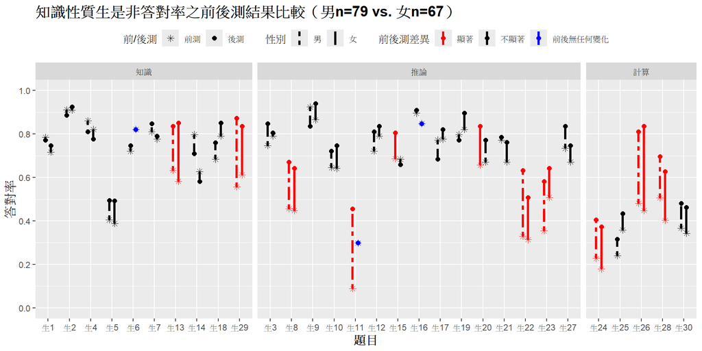

```r
res_boy<-yn_life.prepost.table(Cdat1_yn%>%filter(Cboy), Cdat2_yn%>%filter(Cboy))
res_girl<-yn_life.prepost.table(Cdat1_yn%>%filter(!Cboy), Cdat2_yn%>%filter(!Cboy))
res21<-rbind(res_boy, res_girl)

yn.prepost.compare.plot(res21, "知識性質生是非答對率之前後測結果比較（男n=79 vs. 女n=67）", state=4)+
  facet_grid(cols=vars(知識性質), scales = "free", space = "free")
```

## **9-3 生活主題生是非前後測答對率（男n=79 vs. 女n=67）**

```r
kk<-yn_life.prepost.compare.table(Cdat1_yn%>%filter(Cboy), Cdat2_yn%>%filter(Cboy),
                                  Cdat1_yn%>%filter(!Cboy), Cdat2_yn%>%filter(!Cboy), state=4)%>%
  arrange(生活主題)
kk1<-kk%>%dplyr::select(!c("知識性質","生活主題","覺察"))
colnames(kk1)<-c("","","平均答對率","標準差","平均答對率","標準差","t統計量","p-value","檢定結果")

kk1[,7]<-kk1[,7]%>%as.numeric%>%round(digits=3)

kk1[,8]<-str_c(kk1[,8]%>%as.numeric%>%round(digits=3),cut(kk1[,8]%>%as.numeric, breaks=c(0,0.001,0.01,0.05,1),labels=c("***","**","*","")))

kk1%>%kable("html",escape = F,booktabs = TRUE, digits=c(0,0,3,2,3,2,3,3,3), caption="9-3 生活主題生是非前後測答對率（男n=79 vs. 女n=67）")%>%
  kable_styling(c("striped", "bordered"))%>%
  add_header_above(c(" " = 2, "前測" = 2, "後測" = 2,"前後測成對t檢定" = 3))%>%
  column_spec(1, bold = T)%>%
  collapse_rows(columns = 1)%>%
  group_rows(levels(kk$生活主題)[1], 1, cumsum(table(kk$生活主題))[[1]])%>%
  group_rows(levels(kk$生活主題)[2], cumsum(table(kk$生活主題))[[1]]+1, cumsum(table(kk$生活主題))[[2]])%>%
  group_rows(levels(kk$生活主題)[3], cumsum(table(kk$生活主題))[[2]]+1, cumsum(table(kk$生活主題))[[3]])%>%
  group_rows(levels(kk$生活主題)[4], cumsum(table(kk$生活主題))[[3]]+1, cumsum(table(kk$生活主題))[[4]])%>%
  group_rows(levels(kk$生活主題)[5], cumsum(table(kk$生活主題))[[4]]+1, cumsum(table(kk$生活主題))[[5]])%>%
  group_rows(levels(kk$生活主題)[6], cumsum(table(kk$生活主題))[[5]]+1, cumsum(table(kk$生活主題))[[6]])%>%
  group_rows(levels(kk$生活主題)[7], cumsum(table(kk$生活主題))[[6]]+1, cumsum(table(kk$生活主題))[[7]])%>%
  group_rows(levels(kk$生活主題)[8], cumsum(table(kk$生活主題))[[7]]+1, cumsum(table(kk$生活主題))[[8]])
```

9-3 生活主題生是非前後測答對率（男n=79 vs. 女n=67）

|  |  | 前測 平均答對率 | 前測 標準差 | 後測 平均答對率 | 後測 標準差 | 前後測成對t檢定 t統計量 | 前後測成對t檢定 p-value | 前後測成對t檢定 檢定結果 |
| --- | --- | --- | --- | --- | --- | --- | --- | --- |
| **01營養素** |  |  |  |  |  |  |  |  |
| 生是非1 | 男 | 0.785 | 0.41 | 0.772 | 0.42 | -0.257 | 0.798 | Don’t Reject H0 |
|  | 女 | 0.716 | 0.45 | 0.746 | 0.44 | 0.469 | 0.641 | Don’t Reject H0 |
| 生是非2 | 男 | 0.911 | 0.29 | 0.886 | 0.32 | -0.575 | 0.567 | Don’t Reject H0 |
|  | 女 | 0.910 | 0.29 | 0.925 | 0.26 | 0.376 | 0.708 | Don’t Reject H0 |
| 生是非4 | 男 | 0.861 | 0.35 | 0.810 | 0.39 | -1.070 | 0.288 | Don’t Reject H0 |
|  | 女 | 0.821 | 0.39 | 0.776 | 0.42 | -0.903 | 0.37 | Don’t Reject H0 |
| 生是非24 | 男 | 0.228 | 0.42 | 0.405 | 0.49 | 2.652 | 0.01** | Reject H0 |
|  | 女 | 0.179 | 0.39 | 0.373 | 0.49 | 2.507 | 0.015* | Reject H0 |
| **02細胞** |  |  |  |  |  |  |  |  |
| 生是非3 | 男 | 0.747 | 0.44 | 0.848 | 0.36 | 1.727 | 0.088 | Don’t Reject H0 |
|  | 女 | 0.791 | 0.41 | 0.806 | 0.40 | 0.256 | 0.798 | Don’t Reject H0 |
| 生是非5 | 男 | 0.405 | 0.49 | 0.494 | 0.50 | 1.409 | 0.163 | Don’t Reject H0 |
|  | 女 | 0.388 | 0.49 | 0.493 | 0.50 | 1.625 | 0.109 | Don’t Reject H0 |
| 生是非8 | 男 | 0.456 | 0.50 | 0.671 | 0.47 | 3.230 | 0.002** | Reject H0 |
|  | 女 | 0.448 | 0.50 | 0.642 | 0.48 | 2.851 | 0.006** | Reject H0 |
| 生是非10 | 男 | 0.646 | 0.48 | 0.722 | 0.45 | 1.097 | 0.276 | Don’t Reject H0 |
|  | 女 | 0.642 | 0.48 | 0.746 | 0.44 | 1.410 | 0.163 | Don’t Reject H0 |
| **03食物** |  |  |  |  |  |  |  |  |
| 生是非12 | 男 | 0.722 | 0.45 | 0.810 | 0.39 | 1.354 | 0.18 | Don’t Reject H0 |
|  | 女 | 0.791 | 0.41 | 0.836 | 0.37 | 0.725 | 0.471 | Don’t Reject H0 |
| 生是非18 | 男 | 0.684 | 0.47 | 0.759 | 0.43 | 1.180 | 0.242 | Don’t Reject H0 |
|  | 女 | 0.791 | 0.41 | 0.851 | 0.36 | 1.070 | 0.288 | Don’t Reject H0 |
| 生是非20 | 男 | 0.671 | 0.47 | 0.772 | 0.42 | 1.584 | 0.117 | Don’t Reject H0 |
|  | 女 | 0.657 | 0.48 | 0.836 | 0.37 | 2.673 | 0.009** | Reject H0 |
| 生是非23 | 男 | 0.354 | 0.48 | 0.582 | 0.50 | 3.386 | 0.001** | Reject H0 |
|  | 女 | 0.507 | 0.50 | 0.642 | 0.48 | 2.405 | 0.019* | Reject H0 |
| 生是非30 | 男 | 0.367 | 0.49 | 0.481 | 0.50 | 1.691 | 0.095 | Don’t Reject H0 |
|  | 女 | 0.343 | 0.48 | 0.463 | 0.50 | 1.819 | 0.073 | Don’t Reject H0 |
| **04飲食習慣** |  |  |  |  |  |  |  |  |
| 生是非6 | 男 | 0.722 | 0.45 | 0.747 | 0.44 | 0.445 | 0.658 | Don’t Reject H0 |
|  | 女 | 0.821 | 0.39 | 0.821 | 0.39 | 0.000 | 1 | No Change |
| 生是非9 | 男 | 0.924 | 0.27 | 0.835 | 0.37 | -1.977 | 0.052 | Don’t Reject H0 |
|  | 女 | 0.866 | 0.34 | 0.940 | 0.24 | 1.928 | 0.058 | Don’t Reject H0 |
| 生是非15 | 男 | 0.684 | 0.47 | 0.658 | 0.48 | -0.445 | 0.658 | Don’t Reject H0 |
|  | 女 | 0.687 | 0.47 | 0.806 | 0.40 | 2.198 | 0.031* | Reject H0 |
| 生是非16 | 男 | 0.848 | 0.36 | 0.848 | 0.36 | 0.000 | 1 | No Change |
|  | 女 | 0.896 | 0.31 | 0.910 | 0.29 | 0.445 | 0.658 | Don’t Reject H0 |
| 生是非17 | 男 | 0.772 | 0.42 | 0.684 | 0.47 | -1.262 | 0.211 | Don’t Reject H0 |
|  | 女 | 0.776 | 0.42 | 0.821 | 0.39 | 0.725 | 0.471 | Don’t Reject H0 |
| **05運動** |  |  |  |  |  |  |  |  |
| 生是非7 | 男 | 0.810 | 0.39 | 0.848 | 0.36 | 0.652 | 0.516 | Don’t Reject H0 |
|  | 女 | 0.776 | 0.42 | 0.791 | 0.41 | 0.228 | 0.821 | Don’t Reject H0 |
| 生是非27 | 男 | 0.734 | 0.44 | 0.835 | 0.37 | 1.651 | 0.103 | Don’t Reject H0 |
|  | 女 | 0.672 | 0.47 | 0.746 | 0.44 | 1.093 | 0.279 | Don’t Reject H0 |
| **06肥胖** |  |  |  |  |  |  |  |  |
| 生是非11 | 男 | 0.089 | 0.29 | 0.456 | 0.50 | 5.613 | 0*** | Reject H0 |
|  | 女 | 0.299 | 0.46 | 0.299 | 0.46 | 0.000 | 1 | No Change |
| 生是非25 | 男 | 0.241 | 0.43 | 0.316 | 0.47 | 1.284 | 0.203 | Don’t Reject H0 |
|  | 女 | 0.358 | 0.48 | 0.433 | 0.50 | 1.093 | 0.279 | Don’t Reject H0 |
| 生是非26 | 男 | 0.481 | 0.50 | 0.810 | 0.39 | 4.761 | 0*** | Reject H0 |
|  | 女 | 0.448 | 0.50 | 0.836 | 0.37 | 5.783 | 0*** | Reject H0 |
| **07糖尿病** |  |  |  |  |  |  |  |  |
| 生是非13 | 男 | 0.633 | 0.49 | 0.835 | 0.37 | 2.778 | 0.007** | Reject H0 |
|  | 女 | 0.582 | 0.50 | 0.851 | 0.36 | 4.081 | 0*** | Reject H0 |
| 生是非14 | 男 | 0.797 | 0.40 | 0.709 | 0.46 | -1.409 | 0.163 | Don’t Reject H0 |
|  | 女 | 0.627 | 0.49 | 0.582 | 0.50 | -0.686 | 0.495 | Don’t Reject H0 |
| 生是非19 | 男 | 0.797 | 0.40 | 0.772 | 0.42 | -0.469 | 0.64 | Don’t Reject H0 |
|  | 女 | 0.821 | 0.39 | 0.896 | 0.31 | 1.397 | 0.167 | Don’t Reject H0 |
| 生是非21 | 男 | 0.772 | 0.42 | 0.785 | 0.41 | 0.228 | 0.82 | Don’t Reject H0 |
|  | 女 | 0.672 | 0.47 | 0.761 | 0.43 | 1.350 | 0.182 | Don’t Reject H0 |
| 生是非22 | 男 | 0.329 | 0.47 | 0.633 | 0.49 | 3.936 | 0*** | Reject H0 |
|  | 女 | 0.313 | 0.47 | 0.507 | 0.50 | 2.851 | 0.006** | Reject H0 |
| 生是非28 | 男 | 0.506 | 0.50 | 0.696 | 0.46 | 2.550 | 0.013* | Reject H0 |
|  | 女 | 0.403 | 0.49 | 0.627 | 0.49 | 2.647 | 0.01* | Reject H0 |
| **08量測** |  |  |  |  |  |  |  |  |
| 生是非29 | 男 | 0.557 | 0.50 | 0.873 | 0.33 | 5.170 | 0*** | Reject H0 |
|  | 女 | 0.612 | 0.49 | 0.836 | 0.37 | 3.200 | 0.002** | Reject H0 |

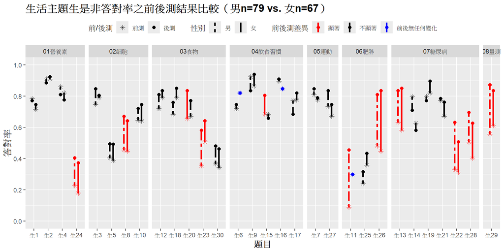

```r
yn.prepost.compare.plot(res21, "生活主題生是非答對率之前後測結果比較（男n=79 vs. 女n=67）", state=4)+
  facet_grid(cols=vars(生活主題), scales = "free", space = "free")
```

## **9-4 覺察類生是非前後測答對率（男n=79 vs. 女n=67）**

```r
kk<-yn_life.prepost.compare.table(Cdat1_yn%>%filter(Cboy), Cdat2_yn%>%filter(Cboy),
                                  Cdat1_yn%>%filter(!Cboy), Cdat2_yn%>%filter(!Cboy), state=4)%>%
  filter(覺察==1)%>%dplyr::select(!c("知識性質","生活主題","覺察"))

colnames(kk)<-c("","","平均答對率","標準差","平均答對率","標準差","t統計量","p-value","檢定結果")


kk[,7]<-kk[,7]%>%as.numeric%>%round(digits=3)

kk[,8]<-str_c(kk[,8]%>%as.numeric%>%round(digits=3),cut(kk[,8]%>%as.numeric, breaks=c(0,0.001,0.01,0.05,1),labels=c("***","**","*","")))

kk%>%kable("html",escape = F,booktabs = TRUE, digits=c(0,0,3,2,3,2,3,3,3), caption="9-4 覺察類生是非前後測答對率（男n=79 vs. 女n=67）")%>%
  kable_styling(c("striped", "bordered"))%>%
  add_header_above(c(" " = 2, "前測" = 2, "後測" = 2,"前後測成對t檢定" = 3))%>%
  column_spec(1, bold = T)%>%
  collapse_rows(columns = 1)%>%
  group_rows("覺察", 1, dim(kk)[1])
```

9-4 覺察類生是非前後測答對率（男n=79 vs. 女n=67）

|  |  | 前測 平均答對率 | 前測 標準差 | 後測 平均答對率 | 後測 標準差 | 前後測成對t檢定 t統計量 | 前後測成對t檢定 p-value | 前後測成對t檢定 檢定結果 |
| --- | --- | --- | --- | --- | --- | --- | --- | --- |
| **覺察** |  |  |  |  |  |  |  |  |
| 生是非2 | 男 | 0.911 | 0.29 | 0.886 | 0.32 | -0.575 | 0.567 | Don’t Reject H0 |
|  | 女 | 0.910 | 0.29 | 0.925 | 0.26 | 0.376 | 0.708 | Don’t Reject H0 |
| 生是非6 | 男 | 0.722 | 0.45 | 0.747 | 0.44 | 0.445 | 0.658 | Don’t Reject H0 |
|  | 女 | 0.821 | 0.39 | 0.821 | 0.39 | 0.000 | 1 | No Change |
| 生是非9 | 男 | 0.924 | 0.27 | 0.835 | 0.37 | -1.977 | 0.052 | Don’t Reject H0 |
|  | 女 | 0.866 | 0.34 | 0.940 | 0.24 | 1.928 | 0.058 | Don’t Reject H0 |
| 生是非11 | 男 | 0.089 | 0.29 | 0.456 | 0.50 | 5.613 | 0*** | Reject H0 |
|  | 女 | 0.299 | 0.46 | 0.299 | 0.46 | 0.000 | 1 | No Change |
| 生是非12 | 男 | 0.722 | 0.45 | 0.810 | 0.39 | 1.354 | 0.18 | Don’t Reject H0 |
|  | 女 | 0.791 | 0.41 | 0.836 | 0.37 | 0.725 | 0.471 | Don’t Reject H0 |
| 生是非13 | 男 | 0.633 | 0.49 | 0.835 | 0.37 | 2.778 | 0.007** | Reject H0 |
|  | 女 | 0.582 | 0.50 | 0.851 | 0.36 | 4.081 | 0*** | Reject H0 |
| 生是非15 | 男 | 0.684 | 0.47 | 0.658 | 0.48 | -0.445 | 0.658 | Don’t Reject H0 |
|  | 女 | 0.687 | 0.47 | 0.806 | 0.40 | 2.198 | 0.031* | Reject H0 |
| 生是非16 | 男 | 0.848 | 0.36 | 0.848 | 0.36 | 0.000 | 1 | No Change |
|  | 女 | 0.896 | 0.31 | 0.910 | 0.29 | 0.445 | 0.658 | Don’t Reject H0 |
| 生是非17 | 男 | 0.772 | 0.42 | 0.684 | 0.47 | -1.262 | 0.211 | Don’t Reject H0 |
|  | 女 | 0.776 | 0.42 | 0.821 | 0.39 | 0.725 | 0.471 | Don’t Reject H0 |
| 生是非18 | 男 | 0.684 | 0.47 | 0.759 | 0.43 | 1.180 | 0.242 | Don’t Reject H0 |
|  | 女 | 0.791 | 0.41 | 0.851 | 0.36 | 1.070 | 0.288 | Don’t Reject H0 |
| 生是非19 | 男 | 0.797 | 0.40 | 0.772 | 0.42 | -0.469 | 0.64 | Don’t Reject H0 |
|  | 女 | 0.821 | 0.39 | 0.896 | 0.31 | 1.397 | 0.167 | Don’t Reject H0 |
| 生是非20 | 男 | 0.671 | 0.47 | 0.772 | 0.42 | 1.584 | 0.117 | Don’t Reject H0 |
|  | 女 | 0.657 | 0.48 | 0.836 | 0.37 | 2.673 | 0.009** | Reject H0 |
| 生是非23 | 男 | 0.354 | 0.48 | 0.582 | 0.50 | 3.386 | 0.001** | Reject H0 |
|  | 女 | 0.507 | 0.50 | 0.642 | 0.48 | 2.405 | 0.019* | Reject H0 |
| 生是非26 | 男 | 0.481 | 0.50 | 0.810 | 0.39 | 4.761 | 0*** | Reject H0 |
|  | 女 | 0.448 | 0.50 | 0.836 | 0.37 | 5.783 | 0*** | Reject H0 |
| 生是非27 | 男 | 0.734 | 0.44 | 0.835 | 0.37 | 1.651 | 0.103 | Don’t Reject H0 |
|  | 女 | 0.672 | 0.47 | 0.746 | 0.44 | 1.093 | 0.279 | Don’t Reject H0 |

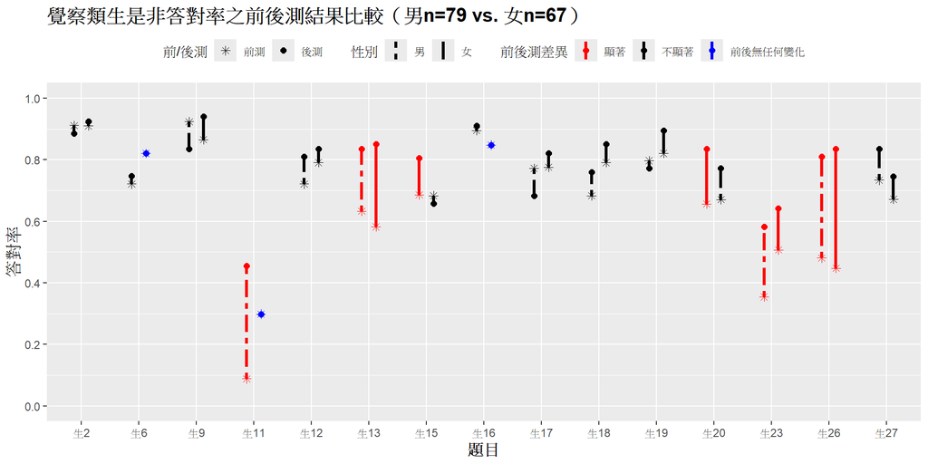

```r
yn.prepost.compare.plot(res21[res21$覺察==1,], "覺察類生是非答對率之前後測結果比較（男n=79 vs. 女n=67）", state=4)
```

## **9-5 計算全部人/男/女彙整表格（分成生是非、技是非兩種情形）**

```r
mean_score<-matrix(NA,3,12)
rownames(mean_score)<-c("全部人 (n=146)","男 (n=79)","女 (n=67)")
colnames(mean_score)<-rep(c("平均答對率","標準差","平均答對率","標準差","t統計量","p-value"),2)

mean_score[1,]<-mean_table(Cdat1_yn, Cdat2_yn)
mean_score[2,]<-mean_table(Cdat1_yn%>%filter(Cboy), Cdat2_yn%>%filter(Cboy))
mean_score[3,]<-mean_table(Cdat1_yn%>%filter(!Cboy), Cdat2_yn%>%filter(!Cboy))

mean_score[,6]<-str_c(mean_score[,6]%>%as.numeric()%>%round(digits=3),cut(mean_score[,6]%>%as.numeric(), breaks=c(0,0.001,0.01,0.05,1),labels=c("***","**","*","")))

mean_score[,12]<-str_c(mean_score[,12]%>%as.numeric()%>%round(digits=3),cut(mean_score[,12]%>%as.numeric(), breaks=c(0,0.001,0.01,0.05,1),labels=c("***","**","*","")))

mean_score%>%kableExtra::kable("html",escape = F,booktabs = TRUE, caption="9-5 計算全部人/男/女彙整表格（分成生是非、技是非兩種情形）")%>%
  kable_styling(c("striped", "bordered"))%>%
  add_header_above(c(" " = 1, "前測" = 2, "後測" = 2, "前後測成對t檢定" = 2,  "前測" = 2, "後測" = 2, "前後測成對t檢定" = 2))%>%
  add_header_above(c(" " = 1, "生是非" = 6, "技是非" = 6))%>%
  column_spec(1, bold = T)
```

9-5 計算全部人/男/女彙整表格（分成生是非、技是非兩種情形）

|  | 生是非 前測 平均答對率 | 生是非 前測 標準差 | 生是非 後測 平均答對率 | 生是非 後測 標準差 | 生是非 前後測成對t檢定 t統計量 | 生是非 前後測成對t檢定 p-value | 技是非 前測 平均答對率 | 技是非 前測 標準差 | 技是非 後測 平均答對率 | 技是非 後測 標準差 | 技是非 前後測成對t檢定 t統計量 | 技是非 前後測成對t檢定 p-value |
| --- | --- | --- | --- | --- | --- | --- | --- | --- | --- | --- | --- | --- |
| 全部人 (n=146) | 0.619 | 0.15 | 0.716 | 0.15 | 7.098 | 0*** | 0.375 | 0.29 | 0.787 | 0.26 | 14.56 | 0*** |
| 男 (n=79) | 0.618 | 0.16 | 0.712 | 0.16 | 4.639 | 0*** | 0.382 | 0.31 | 0.781 | 0.27 | 10.359 | 0*** |
| 女 (n=67) | 0.62 | 0.15 | 0.72 | 0.15 | 5.626 | 0*** | 0.366 | 0.27 | 0.794 | 0.24 | 10.189 | 0*** |

```r
#write.xlsx(mean_score, rowNames=T,startCol=1,"C:/Users/h2407/OneDrive/文件/1121/師培中心分析案/報表資料檔/生是非與技是非的整體平均.xlsx")
```

### **9-5-1 全部生是非、知識性質及覺察類是非題彙整表格（男n=79 vs. 女n=67）**

```r
kk<-mean_table_all2(Cdat1_yn%>%filter(Cboy), Cdat2_yn%>%filter(Cboy),
                   Cdat1_yn%>%filter(!Cboy), Cdat2_yn%>%filter(!Cboy), state=4)

kk[[1]]%>%kableExtra::kable("html",escape = F,booktabs = TRUE,digits=c(0,0,3,2,3,2,3,3,3,3,3,3,3,3,3,3,3,3),caption="9-5-1 全部生是非、知識性質及覺察類是非題彙整表格（男n=79 vs. 女n=67）")%>%
  kable_styling(c("striped", "bordered"))%>%
  add_header_above(c(" " = 2, "前測" = 2, "後測" = 2,"前後測成對t檢定" = 3, "男-女獨立t檢定 (進步量)"=3, "男-女獨立t檢定 (前測)"=3, "男-女獨立t檢定 (後測)"=3))%>%
  column_spec(1, bold = T)%>%
  collapse_rows(columns = c(1,10:18))
```

9-5-1 全部生是非、知識性質及覺察類是非題彙整表格（男n=79 vs. 女n=67）

|  |  | 前測 平均答對率 | 前測 標準差 | 後測 平均答對率 | 後測 標準差 | 前後測成對t檢定 平均進步量 | 前後測成對t檢定 t統計量 | 前後測成對t檢定 p-value | 男-女獨立t檢定 (進步量) 男-女進步量差異 | 男-女獨立t檢定 (進步量) t統計量 | 男-女獨立t檢定 (進步量) p-value | 男-女獨立t檢定 (前測) 男-女組間平均差異 | 男-女獨立t檢定 (前測) t統計量 | 男-女獨立t檢定 (前測) p-value | 男-女獨立t檢定 (後測) 男-女組間平均差異 | 男-女獨立t檢定 (後測) t統計量 | 男-女獨立t檢定 (後測) p-value |  |  |  |  |  |  |  |  |  |  |  |  | … |
| --- | --- | --- | --- | --- | --- | --- | --- | --- | --- | --- | --- | --- | --- | --- | --- | --- | --- | --- | --- | --- | --- | --- | --- | --- | --- | --- | --- | --- | --- | --- |
| 全部生是非 | 男 | 0.618 | 0.16 | 0.712 | 0.16 | 0.094 | 4.639 | 0*** | -0.005 | -0.201 | 0.841 | -0.003 | -0.104 | 0.917 | -0.008 | -0.315 | 0.753 |  |  |  |  |  |  |  |  |  |  |  |  | … |
|  | 女 | 0.620 | 0.15 | 0.720 | 0.15 | 0.100 | 5.626 | 0*** |  |  |  |  |  |  |  |  |  |  |  |  |  |  |  |  |  |  |  |  |  | … |
| 知識 | 男 | 0.716 | 0.17 | 0.773 | 0.18 | 0.057 | 2.550 | 0.013* |  |  |  |  |  |  |  |  |  | -0.006 | -0.183 | 0.855 | 0.012 | 0.413 | 0.68 | 0.006 | 0.207 | 0.836 |  |  |  | … |
|  | 女 | 0.704 | 0.18 | 0.767 | 0.18 | 0.063 | 2.865 | 0.006** |  |  |  |  |  |  |  |  |  |  |  |  |  |  |  |  |  |  |  |  |  | … |
| 推論 | 男 | 0.636 | 0.18 | 0.727 | 0.18 | 0.091 | 4.049 | 0*** | 0.001 | 0.020 | 0.984 | -0.019 | -0.678 | 0.499 | -0.019 | -0.670 | 0.504 |  |  |  |  |  |  |  |  |  |  |  |  | … |
|  | 女 | 0.656 | 0.17 | 0.746 | 0.16 | 0.091 | 4.777 | 0*** |  |  |  |  |  |  |  |  |  |  |  |  |  |  |  |  |  |  |  |  |  | … |
| 計算 | 男 | 0.365 | 0.25 | 0.542 | 0.24 | 0.177 | 5.046 | 0*** |  |  |  |  |  |  |  |  |  |  |  |  |  |  |  |  |  |  | -0.023 | -0.431 | 0.667 | … |
|  | 女 | 0.346 | 0.30 | 0.546 | 0.25 | 0.200 | 5.070 | 0*** |  |  |  |  |  |  |  |  |  |  |  |  |  |  |  |  |  |  |  |  |  | … |
| 覺察 | 男 | 0.668 | 0.19 | 0.753 | 0.19 | 0.084 | 3.277 | 0.002** | -0.015 | -0.478 | 0.633 | -0.033 | -1.105 | 0.271 | -0.048 | -1.591 | 0.114 |  |  |  |  |  |  |  |  |  |  |  |  | … |
|  | 女 | 0.701 | 0.17 | 0.801 | 0.17 | 0.100 | 5.425 | 0*** |  |  |  |  |  |  |  |  |  |  |  |  |  |  |  |  |  |  |  |  |  | … |

### **9-5-2 全部生是非、知識性質及覺察類是非題盒形圖（男n=79 vs. 女n=67）**

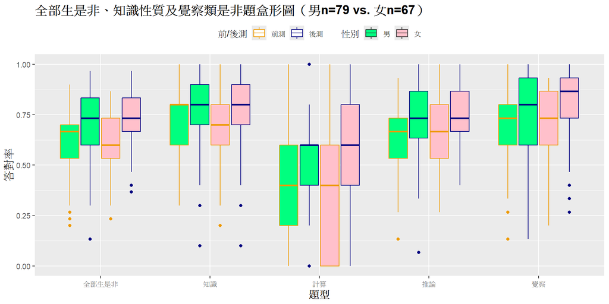

```r
yn.prepost.compare.boxplot(Cdat1_yn%>%filter(Cboy), Cdat2_yn%>%filter(Cboy),
                   Cdat1_yn%>%filter(!Cboy), Cdat2_yn%>%filter(!Cboy), state=4,
                   title="全部生是非、知識性質及覺察類是非題盒形圖（男n=79 vs. 女n=67）")
```

# **10. 早餐地點的影響分析**

```r
C711<-Cdat1_yn$流水號%in%(eat%>%filter(可能早餐來源%in%str_subset(eat$可能早餐來源%>%unique(),"超商")))$流水號
Cbf<-Cdat1_yn$流水號%in%(eat%>%filter(可能早餐來源%in%str_subset(eat$可能早餐來源%>%unique(),"傳統早餐店")))$流水號
Chome<-Cdat1_yn$流水號%in%(eat%>%filter(可能早餐來源%in%str_subset(eat$可能早餐來源%>%unique(),"家裡")))$流水號
```

## **10-1 是非題前後測答對率（超商n=75 vs. 早餐店n=17 vs. 家裡n=17）**

```r
kk<-yn.prepost.compare.table(Cdat1_yn%>%filter(C711&(Cfat.bf|Cnofat.bf)), Cdat2_yn%>%filter(C711&(Cfat.bf|Cnofat.bf)),
                             Cdat1_yn%>%filter(Cbf&(Cfat.bf|Cnofat.bf)), Cdat2_yn%>%filter(Cbf&(Cfat.bf|Cnofat.bf)),
                             data_c1=Cdat1_yn%>%filter(Chome&(Cfat.bf|Cnofat.bf)),
                             data_c2=Cdat2_yn%>%filter(Chome&(Cfat.bf|Cnofat.bf)), state=5)

colnames(kk)<-c("","","平均答對率","標準差","平均答對率","標準差","t統計量","p-value","檢定結果")


kk[,7]<-kk[,7]%>%as.numeric%>%round(digits=3)

kk[,8]<-str_c(kk[,8]%>%as.numeric%>%round(digits=3),cut(kk[,8]%>%as.numeric, breaks=c(0,0.001,0.01,0.05,1),labels=c("***","**","*","")))

kk%>%kable("html",escape = F,booktabs = TRUE, digits=c(0,0,3,2,3,2,3,3,3), caption="10-1 是非題前後測答對率（超商n=75 vs. 早餐店n=17 vs. 家裡n=17）")%>%
  kable_styling(c("striped", "bordered"))%>%
  add_header_above(c(" " = 2, "前測" = 2, "後測" = 2,"前後測成對t檢定" = 3))%>%
  column_spec(1, bold = T)%>%
  collapse_rows(columns = 1)%>%
  group_rows("生是非", 1, 30*3)%>%
  group_rows("技是非", 30*3+1, 30*4)
```

10-1 是非題前後測答對率（超商n=75 vs. 早餐店n=17 vs. 家裡n=17）

|  |  | 前測 平均答對率 | 前測 標準差 | 後測 平均答對率 | 後測 標準差 | 前後測成對t檢定 t統計量 | 前後測成對t檢定 p-value | 前後測成對t檢定 檢定結果 |
| --- | --- | --- | --- | --- | --- | --- | --- | --- |
| **生是非** |  |  |  |  |  |  |  |  |
| 生是非1 | 超商 | 0.813 | 0.39 | 0.813 | 0.39 | 0.000 | 1 | No Change |
|  | 傳統早餐店 | 0.647 | 0.49 | 0.765 | 0.44 | 1.461 | 0.163 | Don’t Reject H0 |
|  | 家裡 | 0.765 | 0.44 | 0.706 | 0.47 | -0.436 | 0.668 | Don’t Reject H0 |
| 生是非2 | 超商 | 0.907 | 0.29 | 0.893 | 0.31 | -0.300 | 0.765 | Don’t Reject H0 |
|  | 傳統早餐店 | 0.882 | 0.33 | 0.941 | 0.24 | 0.566 | 0.579 | Don’t Reject H0 |
|  | 家裡 | 0.941 | 0.24 | 0.882 | 0.33 | -0.566 | 0.579 | Don’t Reject H0 |
| 生是非3 | 超商 | 0.773 | 0.42 | 0.787 | 0.41 | 0.207 | 0.836 | Don’t Reject H0 |
|  | 傳統早餐店 | 0.765 | 0.44 | 1.000 | 0.00 | 2.219 | 0.041* | Reject H0 |
|  | 家裡 | 0.824 | 0.39 | 0.824 | 0.39 | 0.000 | 1 | No Change |
| 生是非4 | 超商 | 0.827 | 0.38 | 0.747 | 0.44 | -1.513 | 0.135 | Don’t Reject H0 |
|  | 傳統早餐店 | 0.882 | 0.33 | 0.882 | 0.33 | NaN | NA | No Change |
|  | 家裡 | 0.882 | 0.33 | 0.765 | 0.44 | -1.461 | 0.163 | Don’t Reject H0 |
| 生是非5 | 超商 | 0.467 | 0.50 | 0.560 | 0.50 | 1.471 | 0.146 | Don’t Reject H0 |
|  | 傳統早餐店 | 0.176 | 0.39 | 0.353 | 0.49 | 1.376 | 0.188 | Don’t Reject H0 |
|  | 家裡 | 0.412 | 0.51 | 0.647 | 0.49 | 2.219 | 0.041* | Reject H0 |
| 生是非6 | 超商 | 0.733 | 0.45 | 0.693 | 0.46 | -0.623 | 0.535 | Don’t Reject H0 |
|  | 傳統早餐店 | 0.765 | 0.44 | 0.824 | 0.39 | 0.566 | 0.579 | Don’t Reject H0 |
|  | 家裡 | 0.824 | 0.39 | 0.882 | 0.33 | 0.566 | 0.579 | Don’t Reject H0 |
| 生是非7 | 超商 | 0.813 | 0.39 | 0.840 | 0.37 | 0.445 | 0.658 | Don’t Reject H0 |
|  | 傳統早餐店 | 0.824 | 0.39 | 0.706 | 0.47 | -0.808 | 0.431 | Don’t Reject H0 |
|  | 家裡 | 0.824 | 0.39 | 0.706 | 0.47 | -0.808 | 0.431 | Don’t Reject H0 |
| 生是非8 | 超商 | 0.507 | 0.50 | 0.720 | 0.45 | 3.205 | 0.002** | Reject H0 |
|  | 傳統早餐店 | 0.529 | 0.51 | 0.647 | 0.49 | 0.808 | 0.431 | Don’t Reject H0 |
|  | 家裡 | 0.353 | 0.49 | 0.588 | 0.51 | 2.219 | 0.041* | Reject H0 |
| 生是非9 | 超商 | 0.907 | 0.29 | 0.880 | 0.33 | -0.630 | 0.531 | Don’t Reject H0 |
|  | 傳統早餐店 | 0.941 | 0.24 | 0.765 | 0.44 | -1.852 | 0.083 | Don’t Reject H0 |
|  | 家裡 | 0.882 | 0.33 | 1.000 | 0.00 | 1.461 | 0.163 | Don’t Reject H0 |
| 生是非10 | 超商 | 0.667 | 0.47 | 0.787 | 0.41 | 1.756 | 0.083 | Don’t Reject H0 |
|  | 傳統早餐店 | 0.647 | 0.49 | 0.647 | 0.49 | 0.000 | 1 | No Change |

[output cut: 92 more lines]

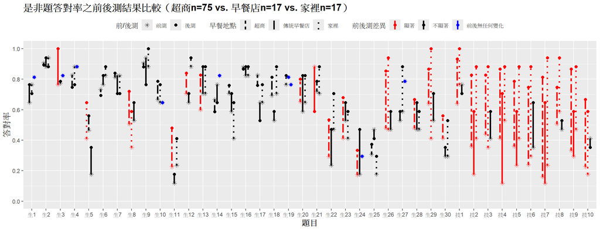

```r
res_711<-yn.prepost.table(Cdat1_yn%>%filter(C711&(Cfat.bf|Cnofat.bf)), Cdat2_yn%>%filter(C711&(Cfat.bf|Cnofat.bf)))
res_bf<-yn.prepost.table(Cdat1_yn%>%filter(Cbf&(Cfat.bf|Cnofat.bf)), Cdat2_yn%>%filter(Cbf&(Cfat.bf|Cnofat.bf)))
res_home<-yn.prepost.table(Cdat1_yn%>%filter(Chome&(Cfat.bf|Cnofat.bf)), Cdat2_yn%>%filter(Chome&(Cfat.bf|Cnofat.bf)))
res2<-rbind(res_711, res_bf, res_home)

yn.prepost.compare.plot(res2, "是非題答對率之前後測結果比較（超商n=75 vs. 早餐店n=17 vs. 家裡n=17）", state=5)
```

## **10-2 知識性質生是非前後測答對率（超商n=75 vs. 早餐店n=17 vs. 家裡n=17）**

```r
kk<-yn_life.prepost.compare.table(Cdat1_yn%>%filter(C711&(Cfat.bf|Cnofat.bf)), Cdat2_yn%>%filter(C711&(Cfat.bf|Cnofat.bf)),
                             Cdat1_yn%>%filter(Cbf&(Cfat.bf|Cnofat.bf)), Cdat2_yn%>%filter(Cbf&(Cfat.bf|Cnofat.bf)),
                             data_c1=Cdat1_yn%>%filter(Chome&(Cfat.bf|Cnofat.bf)),
                             data_c2=Cdat2_yn%>%filter(Chome&(Cfat.bf|Cnofat.bf)),state=5)%>%
  arrange(知識性質)%>%dplyr::select(!c("知識性質","生活主題","覺察"))

colnames(kk)<-c("","","平均答對率","標準差","平均答對率","標準差","t統計量","p-value","檢定結果")

kk[,7]<-kk[,7]%>%as.numeric%>%round(digits=3)

kk[,8]<-str_c(kk[,8]%>%as.numeric%>%round(digits=3),cut(kk[,8]%>%as.numeric, breaks=c(0,0.001,0.01,0.05,1),labels=c("***","**","*","")))

kk%>%kable("html",escape = F,booktabs = TRUE, digits=c(0,0,3,2,3,2,3,3,3), caption="10-2 知識性質生是非前後測答對率（超商n=75 vs. 早餐店n=17 vs. 家裡n=17）")%>%
  kable_styling(c("striped", "bordered"))%>%
  add_header_above(c(" " = 2, "前測" = 2, "後測" = 2,"前後測成對t檢定" = 3))%>%
  column_spec(1, bold = T)%>%
  collapse_rows(columns = 1)%>%
  group_rows("知識", 1, 10*3)%>%
  group_rows("推論", 10*3+1, 25*3)%>%
  group_rows("計算", 25*3+1, 30*3)
```

10-2 知識性質生是非前後測答對率（超商n=75 vs. 早餐店n=17 vs. 家裡n=17）

|  |  | 前測 平均答對率 | 前測 標準差 | 後測 平均答對率 | 後測 標準差 | 前後測成對t檢定 t統計量 | 前後測成對t檢定 p-value | 前後測成對t檢定 檢定結果 |
| --- | --- | --- | --- | --- | --- | --- | --- | --- |
| **知識** |  |  |  |  |  |  |  |  |
| 生是非1 | 超商 | 0.813 | 0.39 | 0.813 | 0.39 | 0.000 | 1 | No Change |
|  | 傳統早餐店 | 0.647 | 0.49 | 0.765 | 0.44 | 1.461 | 0.163 | Don’t Reject H0 |
|  | 家裡 | 0.765 | 0.44 | 0.706 | 0.47 | -0.436 | 0.668 | Don’t Reject H0 |
| 生是非2 | 超商 | 0.907 | 0.29 | 0.893 | 0.31 | -0.300 | 0.765 | Don’t Reject H0 |
|  | 傳統早餐店 | 0.882 | 0.33 | 0.941 | 0.24 | 0.566 | 0.579 | Don’t Reject H0 |
|  | 家裡 | 0.941 | 0.24 | 0.882 | 0.33 | -0.566 | 0.579 | Don’t Reject H0 |
| 生是非4 | 超商 | 0.827 | 0.38 | 0.747 | 0.44 | -1.513 | 0.135 | Don’t Reject H0 |
|  | 傳統早餐店 | 0.882 | 0.33 | 0.882 | 0.33 | NaN | NA | No Change |
|  | 家裡 | 0.882 | 0.33 | 0.765 | 0.44 | -1.461 | 0.163 | Don’t Reject H0 |
| 生是非5 | 超商 | 0.467 | 0.50 | 0.560 | 0.50 | 1.471 | 0.146 | Don’t Reject H0 |
|  | 傳統早餐店 | 0.176 | 0.39 | 0.353 | 0.49 | 1.376 | 0.188 | Don’t Reject H0 |
|  | 家裡 | 0.412 | 0.51 | 0.647 | 0.49 | 2.219 | 0.041* | Reject H0 |
| 生是非6 | 超商 | 0.733 | 0.45 | 0.693 | 0.46 | -0.623 | 0.535 | Don’t Reject H0 |
|  | 傳統早餐店 | 0.765 | 0.44 | 0.824 | 0.39 | 0.566 | 0.579 | Don’t Reject H0 |
|  | 家裡 | 0.824 | 0.39 | 0.882 | 0.33 | 0.566 | 0.579 | Don’t Reject H0 |
| 生是非7 | 超商 | 0.813 | 0.39 | 0.840 | 0.37 | 0.445 | 0.658 | Don’t Reject H0 |
|  | 傳統早餐店 | 0.824 | 0.39 | 0.706 | 0.47 | -0.808 | 0.431 | Don’t Reject H0 |
|  | 家裡 | 0.824 | 0.39 | 0.706 | 0.47 | -0.808 | 0.431 | Don’t Reject H0 |
| 生是非13 | 超商 | 0.600 | 0.49 | 0.827 | 0.38 | 3.510 | 0.001*** | Reject H0 |
|  | 傳統早餐店 | 0.706 | 0.47 | 0.882 | 0.33 | 1.144 | 0.269 | Don’t Reject H0 |
|  | 家裡 | 0.706 | 0.47 | 0.882 | 0.33 | 1.144 | 0.269 | Don’t Reject H0 |
| 生是非14 | 超商 | 0.667 | 0.47 | 0.587 | 0.50 | -1.180 | 0.242 | Don’t Reject H0 |
|  | 傳統早餐店 | 0.765 | 0.44 | 0.647 | 0.49 | -0.696 | 0.496 | Don’t Reject H0 |
|  | 家裡 | 0.824 | 0.39 | 0.824 | 0.39 | 0.000 | 1 | No Change |
| 生是非18 | 超商 | 0.693 | 0.46 | 0.813 | 0.39 | 1.909 | 0.06 | Don’t Reject H0 |
|  | 傳統早餐店 | 0.529 | 0.51 | 0.588 | 0.51 | 0.436 | 0.668 | Don’t Reject H0 |
|  | 家裡 | 0.706 | 0.47 | 0.882 | 0.33 | 1.376 | 0.188 | Don’t Reject H0 |
| 生是非29 | 超商 | 0.640 | 0.48 | 0.867 | 0.34 | 3.510 | 0.001*** | Reject H0 |
|  | 傳統早餐店 | 0.529 | 0.51 | 0.706 | 0.47 | 1.376 | 0.188 | Don’t Reject H0 |

[output cut: 63 more lines]

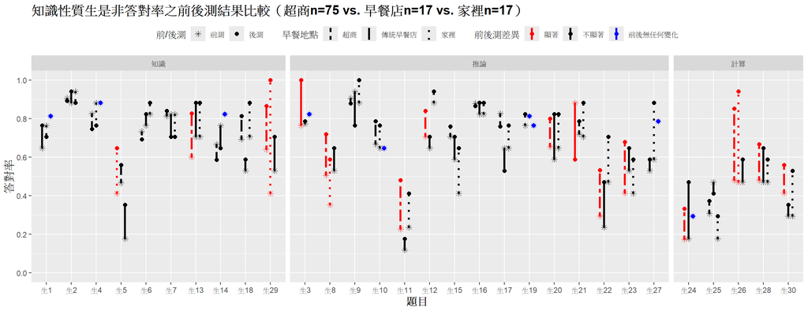

```r
res_711<-yn_life.prepost.table(Cdat1_yn%>%filter(C711&(Cfat.bf|Cnofat.bf)), Cdat2_yn%>%filter(C711&(Cfat.bf|Cnofat.bf)))
res_bf<-yn_life.prepost.table(Cdat1_yn%>%filter(Cbf&(Cfat.bf|Cnofat.bf)), Cdat2_yn%>%filter(Cbf&(Cfat.bf|Cnofat.bf)))
res_home<-yn_life.prepost.table(Cdat1_yn%>%filter(Chome&(Cfat.bf|Cnofat.bf)), Cdat2_yn%>%filter(Chome&(Cfat.bf|Cnofat.bf)))
res21<-rbind(res_711, res_bf, res_home)

yn.prepost.compare.plot(res21, "知識性質生是非答對率之前後測結果比較（超商n=75 vs. 早餐店n=17 vs. 家裡n=17）", state=5)+
  facet_grid(cols=vars(知識性質), scales = "free", space = "free")
```

## **10-3 生活主題生是非前後測答對率（超商n=75 vs. 早餐店n=17 vs. 家裡n=17）**

```r
kk<-yn_life.prepost.compare.table(Cdat1_yn%>%filter(C711&(Cfat.bf|Cnofat.bf)), Cdat2_yn%>%filter(C711&(Cfat.bf|Cnofat.bf)),
                             Cdat1_yn%>%filter(Cbf&(Cfat.bf|Cnofat.bf)), Cdat2_yn%>%filter(Cbf&(Cfat.bf|Cnofat.bf)),
                             data_c1=Cdat1_yn%>%filter(Chome&(Cfat.bf|Cnofat.bf)),
                             data_c2=Cdat2_yn%>%filter(Chome&(Cfat.bf|Cnofat.bf)), state=5)%>%
  arrange(生活主題)
kk1<-kk%>%dplyr::select(!c("知識性質","生活主題","覺察"))
colnames(kk1)<-c("","","平均答對率","標準差","平均答對率","標準差","t統計量","p-value","檢定結果")

kk1[,7]<-kk1[,7]%>%as.numeric%>%round(digits=3)

kk1[,8]<-str_c(kk1[,8]%>%as.numeric%>%round(digits=3),cut(kk1[,8]%>%as.numeric, breaks=c(0,0.001,0.01,0.05,1),labels=c("***","**","*","")))

kk1%>%kable("html",escape = F,booktabs = TRUE, digits=c(0,0,3,2,3,2,3,3,3), caption="10-3 生活主題生是非前後測答對率（超商n=75 vs. 早餐店n=17 vs. 家裡n=17）")%>%
  kable_styling(c("striped", "bordered"))%>%
  add_header_above(c(" " = 2, "前測" = 2, "後測" = 2,"前後測成對t檢定" = 3))%>%
  column_spec(1, bold = T)%>%
  collapse_rows(columns = 1)%>%
  group_rows(levels(kk$生活主題)[1], 1, cumsum(table(kk$生活主題))[[1]])%>%
  group_rows(levels(kk$生活主題)[2], cumsum(table(kk$生活主題))[[1]]+1, cumsum(table(kk$生活主題))[[2]])%>%
  group_rows(levels(kk$生活主題)[3], cumsum(table(kk$生活主題))[[2]]+1, cumsum(table(kk$生活主題))[[3]])%>%
  group_rows(levels(kk$生活主題)[4], cumsum(table(kk$生活主題))[[3]]+1, cumsum(table(kk$生活主題))[[4]])%>%
  group_rows(levels(kk$生活主題)[5], cumsum(table(kk$生活主題))[[4]]+1, cumsum(table(kk$生活主題))[[5]])%>%
  group_rows(levels(kk$生活主題)[6], cumsum(table(kk$生活主題))[[5]]+1, cumsum(table(kk$生活主題))[[6]])%>%
  group_rows(levels(kk$生活主題)[7], cumsum(table(kk$生活主題))[[6]]+1, cumsum(table(kk$生活主題))[[7]])%>%
  group_rows(levels(kk$生活主題)[8], cumsum(table(kk$生活主題))[[7]]+1, cumsum(table(kk$生活主題))[[8]])
```

10-3 生活主題生是非前後測答對率（超商n=75 vs. 早餐店n=17 vs. 家裡n=17）

|  |  | 前測 平均答對率 | 前測 標準差 | 後測 平均答對率 | 後測 標準差 | 前後測成對t檢定 t統計量 | 前後測成對t檢定 p-value | 前後測成對t檢定 檢定結果 |
| --- | --- | --- | --- | --- | --- | --- | --- | --- |
| **01營養素** |  |  |  |  |  |  |  |  |
| 生是非1 | 超商 | 0.813 | 0.39 | 0.813 | 0.39 | 0.000 | 1 | No Change |
|  | 傳統早餐店 | 0.647 | 0.49 | 0.765 | 0.44 | 1.461 | 0.163 | Don’t Reject H0 |
|  | 家裡 | 0.765 | 0.44 | 0.706 | 0.47 | -0.436 | 0.668 | Don’t Reject H0 |
| 生是非2 | 超商 | 0.907 | 0.29 | 0.893 | 0.31 | -0.300 | 0.765 | Don’t Reject H0 |
|  | 傳統早餐店 | 0.882 | 0.33 | 0.941 | 0.24 | 0.566 | 0.579 | Don’t Reject H0 |
|  | 家裡 | 0.941 | 0.24 | 0.882 | 0.33 | -0.566 | 0.579 | Don’t Reject H0 |
| 生是非4 | 超商 | 0.827 | 0.38 | 0.747 | 0.44 | -1.513 | 0.135 | Don’t Reject H0 |
|  | 傳統早餐店 | 0.882 | 0.33 | 0.882 | 0.33 | NaN | NA | No Change |
|  | 家裡 | 0.882 | 0.33 | 0.765 | 0.44 | -1.461 | 0.163 | Don’t Reject H0 |
| 生是非24 | 超商 | 0.173 | 0.38 | 0.333 | 0.47 | 2.249 | 0.027* | Reject H0 |
|  | 傳統早餐店 | 0.176 | 0.39 | 0.471 | 0.51 | 2.063 | 0.056 | Don’t Reject H0 |
|  | 家裡 | 0.294 | 0.47 | 0.294 | 0.47 | 0.000 | 1 | No Change |
| **02細胞** |  |  |  |  |  |  |  |  |
| 生是非3 | 超商 | 0.773 | 0.42 | 0.787 | 0.41 | 0.207 | 0.836 | Don’t Reject H0 |
|  | 傳統早餐店 | 0.765 | 0.44 | 1.000 | 0.00 | 2.219 | 0.041* | Reject H0 |
|  | 家裡 | 0.824 | 0.39 | 0.824 | 0.39 | 0.000 | 1 | No Change |
| 生是非5 | 超商 | 0.467 | 0.50 | 0.560 | 0.50 | 1.471 | 0.146 | Don’t Reject H0 |
|  | 傳統早餐店 | 0.176 | 0.39 | 0.353 | 0.49 | 1.376 | 0.188 | Don’t Reject H0 |
|  | 家裡 | 0.412 | 0.51 | 0.647 | 0.49 | 2.219 | 0.041* | Reject H0 |
| 生是非8 | 超商 | 0.507 | 0.50 | 0.720 | 0.45 | 3.205 | 0.002** | Reject H0 |
|  | 傳統早餐店 | 0.529 | 0.51 | 0.647 | 0.49 | 0.808 | 0.431 | Don’t Reject H0 |
|  | 家裡 | 0.353 | 0.49 | 0.588 | 0.51 | 2.219 | 0.041* | Reject H0 |
| 生是非10 | 超商 | 0.667 | 0.47 | 0.787 | 0.41 | 1.756 | 0.083 | Don’t Reject H0 |
|  | 傳統早餐店 | 0.647 | 0.49 | 0.647 | 0.49 | 0.000 | 1 | No Change |
|  | 家裡 | 0.647 | 0.49 | 0.765 | 0.44 | 1.000 | 0.332 | Don’t Reject H0 |
| **03食物** |  |  |  |  |  |  |  |  |
| 生是非12 | 超商 | 0.707 | 0.46 | 0.840 | 0.37 | 2.185 | 0.032* | Reject H0 |
|  | 傳統早餐店 | 0.647 | 0.49 | 0.706 | 0.47 | 0.324 | 0.75 | Don’t Reject H0 |
|  | 家裡 | 0.882 | 0.33 | 0.941 | 0.24 | 0.566 | 0.579 | Don’t Reject H0 |

[output cut: 68 more lines]

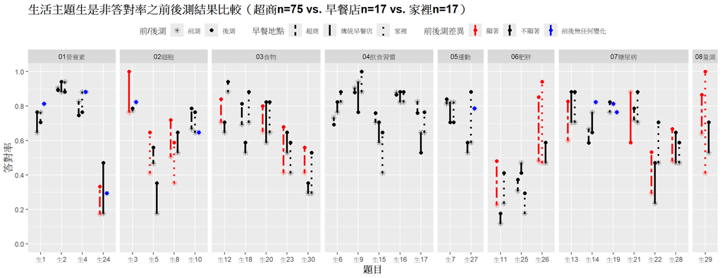

```r
yn.prepost.compare.plot(res21, "生活主題生是非答對率之前後測結果比較（超商n=75 vs. 早餐店n=17 vs. 家裡n=17）", state=5)+
  facet_grid(cols=vars(生活主題), scales = "free", space = "free")
```

## **10-4 覺察類生是非前後測答對率（超商n=75 vs. 早餐店n=17 vs. 家裡n=17）**

```r
kk<-yn_life.prepost.compare.table(Cdat1_yn%>%filter(C711&(Cfat.bf|Cnofat.bf)), Cdat2_yn%>%filter(C711&(Cfat.bf|Cnofat.bf)),
                             Cdat1_yn%>%filter(Cbf&(Cfat.bf|Cnofat.bf)), Cdat2_yn%>%filter(Cbf&(Cfat.bf|Cnofat.bf)),
                             data_c1=Cdat1_yn%>%filter(Chome&(Cfat.bf|Cnofat.bf)),
                             data_c2=Cdat2_yn%>%filter(Chome&(Cfat.bf|Cnofat.bf)),state=5)%>%
  filter(覺察==1)%>%dplyr::select(!c("知識性質","生活主題","覺察"))

colnames(kk)<-c("","","平均答對率","標準差","平均答對率","標準差","t統計量","p-value","檢定結果")


kk[,7]<-kk[,7]%>%as.numeric%>%round(digits=3)

kk[,8]<-str_c(kk[,8]%>%as.numeric%>%round(digits=3),cut(kk[,8]%>%as.numeric, breaks=c(0,0.001,0.01,0.05,1),labels=c("***","**","*","")))

kk%>%kable("html",escape = F,booktabs = TRUE, digits=c(0,0,3,2,3,2,3,3,3), caption="10-4 覺察類生是非前後測答對率（超商n=75 vs. 早餐店n=17 vs. 家裡n=17）")%>%
  kable_styling(c("striped", "bordered"))%>%
  add_header_above(c(" " = 2, "前測" = 2, "後測" = 2,"前後測成對t檢定" = 3))%>%
  column_spec(1, bold = T)%>%
  collapse_rows(columns = 1)%>%
  group_rows("覺察", 1, dim(kk)[1])
```

10-4 覺察類生是非前後測答對率（超商n=75 vs. 早餐店n=17 vs. 家裡n=17）

|  |  | 前測 平均答對率 | 前測 標準差 | 後測 平均答對率 | 後測 標準差 | 前後測成對t檢定 t統計量 | 前後測成對t檢定 p-value | 前後測成對t檢定 檢定結果 |
| --- | --- | --- | --- | --- | --- | --- | --- | --- |
| **覺察** |  |  |  |  |  |  |  |  |
| 生是非2 | 超商 | 0.907 | 0.29 | 0.893 | 0.31 | -0.300 | 0.765 | Don’t Reject H0 |
|  | 傳統早餐店 | 0.882 | 0.33 | 0.941 | 0.24 | 0.566 | 0.579 | Don’t Reject H0 |
|  | 家裡 | 0.941 | 0.24 | 0.882 | 0.33 | -0.566 | 0.579 | Don’t Reject H0 |
| 生是非6 | 超商 | 0.733 | 0.45 | 0.693 | 0.46 | -0.623 | 0.535 | Don’t Reject H0 |
|  | 傳統早餐店 | 0.765 | 0.44 | 0.824 | 0.39 | 0.566 | 0.579 | Don’t Reject H0 |
|  | 家裡 | 0.824 | 0.39 | 0.882 | 0.33 | 0.566 | 0.579 | Don’t Reject H0 |
| 生是非9 | 超商 | 0.907 | 0.29 | 0.880 | 0.33 | -0.630 | 0.531 | Don’t Reject H0 |
|  | 傳統早餐店 | 0.941 | 0.24 | 0.765 | 0.44 | -1.852 | 0.083 | Don’t Reject H0 |
|  | 家裡 | 0.882 | 0.33 | 1.000 | 0.00 | 1.461 | 0.163 | Don’t Reject H0 |
| 生是非11 | 超商 | 0.227 | 0.42 | 0.480 | 0.50 | 3.228 | 0.002** | Reject H0 |
|  | 傳統早餐店 | 0.118 | 0.33 | 0.176 | 0.39 | 0.566 | 0.579 | Don’t Reject H0 |
|  | 家裡 | 0.235 | 0.44 | 0.412 | 0.51 | 1.852 | 0.083 | Don’t Reject H0 |
| 生是非12 | 超商 | 0.707 | 0.46 | 0.840 | 0.37 | 2.185 | 0.032* | Reject H0 |
|  | 傳統早餐店 | 0.647 | 0.49 | 0.706 | 0.47 | 0.324 | 0.75 | Don’t Reject H0 |
|  | 家裡 | 0.882 | 0.33 | 0.941 | 0.24 | 0.566 | 0.579 | Don’t Reject H0 |
| 生是非13 | 超商 | 0.600 | 0.49 | 0.827 | 0.38 | 3.510 | 0.001*** | Reject H0 |
|  | 傳統早餐店 | 0.706 | 0.47 | 0.882 | 0.33 | 1.144 | 0.269 | Don’t Reject H0 |
|  | 家裡 | 0.706 | 0.47 | 0.882 | 0.33 | 1.144 | 0.269 | Don’t Reject H0 |
| 生是非15 | 超商 | 0.707 | 0.46 | 0.760 | 0.43 | 0.942 | 0.349 | Don’t Reject H0 |
|  | 傳統早餐店 | 0.588 | 0.51 | 0.706 | 0.47 | 1.000 | 0.332 | Don’t Reject H0 |
|  | 家裡 | 0.412 | 0.51 | 0.647 | 0.49 | 1.725 | 0.104 | Don’t Reject H0 |
| 生是非16 | 超商 | 0.880 | 0.33 | 0.867 | 0.34 | -0.300 | 0.765 | Don’t Reject H0 |
|  | 傳統早餐店 | 0.824 | 0.39 | 0.882 | 0.33 | 0.436 | 0.668 | Don’t Reject H0 |
|  | 家裡 | 0.824 | 0.39 | 0.882 | 0.33 | 0.566 | 0.579 | Don’t Reject H0 |
| 生是非17 | 超商 | 0.827 | 0.38 | 0.760 | 0.43 | -1.000 | 0.321 | Don’t Reject H0 |
|  | 傳統早餐店 | 0.647 | 0.49 | 0.529 | 0.51 | -0.808 | 0.431 | Don’t Reject H0 |
|  | 家裡 | 0.647 | 0.49 | 0.765 | 0.44 | 0.808 | 0.431 | Don’t Reject H0 |
| 生是非18 | 超商 | 0.693 | 0.46 | 0.813 | 0.39 | 1.909 | 0.06 | Don’t Reject H0 |
|  | 傳統早餐店 | 0.529 | 0.51 | 0.588 | 0.51 | 0.436 | 0.668 | Don’t Reject H0 |
|  | 家裡 | 0.706 | 0.47 | 0.882 | 0.33 | 1.376 | 0.188 | Don’t Reject H0 |
| 生是非19 | 超商 | 0.813 | 0.39 | 0.813 | 0.39 | 0.000 | 1 | No Change |
|  | 傳統早餐店 | 0.765 | 0.44 | 0.765 | 0.44 | 0.000 | 1 | No Change |
|  | 家裡 | 0.765 | 0.44 | 0.824 | 0.39 | 0.566 | 0.579 | Don’t Reject H0 |
| 生是非20 | 超商 | 0.653 | 0.48 | 0.800 | 0.40 | 2.259 | 0.027* | Reject H0 |
|  | 傳統早餐店 | 0.588 | 0.51 | 0.824 | 0.39 | 1.725 | 0.104 | Don’t Reject H0 |
|  | 家裡 | 0.647 | 0.49 | 0.824 | 0.39 | 1.144 | 0.269 | Don’t Reject H0 |
| 生是非23 | 超商 | 0.413 | 0.50 | 0.680 | 0.47 | 4.000 | 0*** | Reject H0 |
|  | 傳統早餐店 | 0.529 | 0.51 | 0.647 | 0.49 | 0.808 | 0.431 | Don’t Reject H0 |
|  | 家裡 | 0.412 | 0.51 | 0.588 | 0.51 | 1.376 | 0.188 | Don’t Reject H0 |
| 生是非26 | 超商 | 0.480 | 0.50 | 0.853 | 0.36 | 5.732 | 0*** | Reject H0 |
|  | 傳統早餐店 | 0.471 | 0.51 | 0.588 | 0.51 | 0.696 | 0.496 | Don’t Reject H0 |
|  | 家裡 | 0.471 | 0.51 | 0.941 | 0.24 | 3.108 | 0.007** | Reject H0 |
| 生是非27 | 超商 | 0.787 | 0.41 | 0.787 | 0.41 | 0.000 | 1 | No Change |
|  | 傳統早餐店 | 0.529 | 0.51 | 0.588 | 0.51 | 0.368 | 0.718 | Don’t Reject H0 |
|  | 家裡 | 0.588 | 0.51 | 0.882 | 0.33 | 2.063 | 0.056 | Don’t Reject H0 |

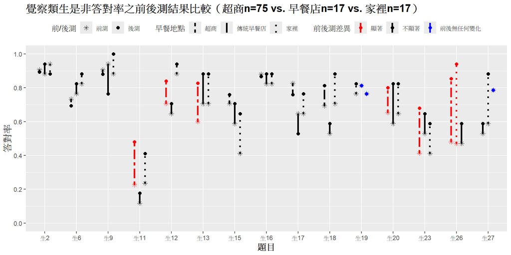

```r
yn.prepost.compare.plot(res21[res21$覺察==1,], "覺察類生是非答對率之前後測結果比較（超商n=75 vs. 早餐店n=17 vs. 家裡n=17）", state=5)
```

## **10-5 計算全部人/超商/早餐店/家裡彙整表格（分成生是非、技是非兩種情形）**

```r
mean_score<-matrix(NA,4,12)
rownames(mean_score)<-c("全部人 (n=109)","超商 (n=75)","早餐店 (n=17)","家裡 (n=17)")
colnames(mean_score)<-rep(c("平均答對率","標準差","平均答對率","標準差","t統計量","p-value"),2)

mean_score[1,]<-mean_table(Cdat1_yn, Cdat2_yn)
mean_score[2,]<-mean_table(Cdat1_yn%>%filter(C711&(Cfat.bf|Cnofat.bf)), Cdat2_yn%>%filter(C711&(Cfat.bf|Cnofat.bf)))
mean_score[3,]<-mean_table(Cdat1_yn%>%filter(Cbf&(Cfat.bf|Cnofat.bf)), Cdat2_yn%>%filter(Cbf&(Cfat.bf|Cnofat.bf)))
mean_score[4,]<-mean_table(Cdat1_yn%>%filter(Chome&(Cfat.bf|Cnofat.bf)), Cdat2_yn%>%filter(Chome&(Cfat.bf|Cnofat.bf)))

mean_score[,6]<-str_c(mean_score[,6]%>%as.numeric()%>%round(digits=3),cut(mean_score[,6]%>%as.numeric(), breaks=c(0,0.001,0.01,0.05,1),labels=c("***","**","*","")))

mean_score[,12]<-str_c(mean_score[,12]%>%as.numeric()%>%round(digits=3),cut(mean_score[,12]%>%as.numeric(), breaks=c(0,0.001,0.01,0.05,1),labels=c("***","**","*","")))

mean_score%>%kableExtra::kable("html",escape = F,booktabs = TRUE, caption="10-5 計算全部人/超商/早餐店/家裡彙整表格（分成生是非、技是非兩種情形）")%>%
  kable_styling(c("striped", "bordered"))%>%
  add_header_above(c(" " = 1, "前測" = 2, "後測" = 2, "前後測成對t檢定" = 2,  "前測" = 2, "後測" = 2, "前後測成對t檢定" = 2))%>%
  add_header_above(c(" " = 1, "生是非" = 6, "技是非" = 6))%>%
  column_spec(1, bold = T)
```

10-5 計算全部人/超商/早餐店/家裡彙整表格（分成生是非、技是非兩種情形）

|  | 生是非 前測 平均答對率 | 生是非 前測 標準差 | 生是非 後測 平均答對率 | 生是非 後測 標準差 | 生是非 前後測成對t檢定 t統計量 | 生是非 前後測成對t檢定 p-value | 技是非 前測 平均答對率 | 技是非 前測 標準差 | 技是非 後測 平均答對率 | 技是非 後測 標準差 | 技是非 前後測成對t檢定 t統計量 | 技是非 前後測成對t檢定 p-value |
| --- | --- | --- | --- | --- | --- | --- | --- | --- | --- | --- | --- | --- |
| 全部人 (n=109) | 0.619 | 0.15 | 0.716 | 0.15 | 7.098 | 0*** | 0.375 | 0.29 | 0.787 | 0.26 | 14.56 | 0*** |
| 超商 (n=75) | 0.63 | 0.16 | 0.724 | 0.17 | 4.903 | 0*** | 0.368 | 0.31 | 0.808 | 0.23 | 12.001 | 0*** |
| 早餐店 (n=17) | 0.594 | 0.15 | 0.657 | 0.19 | 1.259 | 0.226 | 0.335 | 0.26 | 0.594 | 0.35 | 3.484 | 0.003** |
| 家裡 (n=17) | 0.61 | 0.16 | 0.745 | 0.12 | 3.104 | 0.007** | 0.424 | 0.3 | 0.876 | 0.21 | 5.534 | 0*** |

```r
#write.xlsx(mean_score, rowNames=T,startCol=1,"C:/Users/h2407/OneDrive/文件/1121/師培中心分析案/報表資料檔/生是非與技是非的整體平均.xlsx")
```

### **10-5-1 全部生是非、知識性質及覺察類是非題彙整表格（超商n=75 vs. 早餐店n=17 vs. 家裡n=17）**

```r
kk<-mean_table_all2(Cdat1_yn%>%filter(C711&(Cfat.bf|Cnofat.bf)), Cdat2_yn%>%filter(C711&(Cfat.bf|Cnofat.bf)),
               Cdat1_yn%>%filter(Cbf&(Cfat.bf|Cnofat.bf)), Cdat2_yn%>%filter(Cbf&(Cfat.bf|Cnofat.bf)),
               state=5,
               data_c1 = Cdat1_yn%>%filter(Chome&(Cfat.bf|Cnofat.bf)),
               data_c2  = Cdat2_yn%>%filter(Chome&(Cfat.bf|Cnofat.bf)))

#kk<-mean_table_all(Cdat1_yn%>%filter(Cfat), Cdat2_yn%>%filter(Cfat),Cdat1_yn%>%filter(!Cfat), Cdat2_yn%>%filter(!Cfat), state=2)

kk[[1]]%>%kableExtra::kable("html",escape = F,booktabs = TRUE,digits=c(0,0,3,2,3,2,3,3,3,3,3,3,3,3,3),caption="10-5-1 全部生是非、知識性質及覺察類是非題彙整表格（超商n=75 vs. 早餐店n=17 vs. 家裡n=17）")%>%
  kable_styling(c("striped", "bordered"))%>%
  add_header_above(c(" " = 2, "前測" = 2, "後測" = 2,"前後測成對t檢定" = 3, "三組早餐地點anova檢定 (進步量)"=2, "三組早餐地點anova檢定 (前測)"=2, "三組早餐地點anova檢定 (後測)"=2))%>%
  column_spec(1, bold = T)%>%
  collapse_rows(columns = c(1,10:15))
```

10-5-1 全部生是非、知識性質及覺察類是非題彙整表格（超商n=75 vs. 早餐店n=17 vs. 家裡n=17）

|  |  | 前測 平均答對率 | 前測 標準差 | 後測 平均答對率 | 後測 標準差 | 前後測成對t檢定 平均進步量 | 前後測成對t檢定 t統計量 | 前後測成對t檢定 p-value | 三組早餐地點anova檢定 (進步量) F統計量 | 三組早餐地點anova檢定 (進步量) p-value | 三組早餐地點anova檢定 (前測) F統計量 | 三組早餐地點anova檢定 (前測) p-value | 三組早餐地點anova檢定 (後測) F統計量 | 三組早餐地點anova檢定 (後測) p-value |  |  |  |  |  |  |  |  |  |  |  |  |  |  |  | … |
| --- | --- | --- | --- | --- | --- | --- | --- | --- | --- | --- | --- | --- | --- | --- | --- | --- | --- | --- | --- | --- | --- | --- | --- | --- | --- | --- | --- | --- | --- | --- |
| 全部生是非 | 超商 | 0.630 | 0.16 | 0.724 | 0.17 | 0.094 | 4.903 | 0*** | 0.746 | 0.477 | 0.396 | 0.674 | 1.433 | 0.243 |  |  |  |  |  |  |  |  |  |  |  |  |  |  |  | … |
|  | 傳統早餐店 | 0.594 | 0.15 | 0.657 | 0.19 | 0.063 | 1.259 | 0.226 |  |  |  |  |  |  |  |  |  |  |  |  |  |  |  |  |  |  |  |  |  | … |
|  | 家裡 | 0.610 | 0.16 | 0.745 | 0.12 | 0.135 | 3.104 | 0.007** |  |  |  |  |  |  |  |  |  |  |  |  |  |  |  |  |  |  |  |  |  | … |
| 知識 | 超商 | 0.716 | 0.19 | 0.764 | 0.20 | 0.048 | 2.062 | 0.043* |  |  |  |  |  |  | 0.285 | 0.753 | 0.557 | 0.575 | 0.911 | 0.405 |  |  |  |  |  |  |  |  |  | … |
|  | 傳統早餐店 | 0.671 | 0.18 | 0.729 | 0.19 | 0.059 | 1.429 | 0.172 |  |  |  |  |  |  |  |  |  |  |  |  |  |  |  |  |  |  |  |  |  | … |
|  | 家裡 | 0.729 | 0.14 | 0.818 | 0.17 | 0.088 | 1.694 | 0.11 |  |  |  |  |  |  |  |  |  |  |  |  |  |  |  |  |  |  |  |  |  | … |
| 推論 | 超商 | 0.659 | 0.18 | 0.752 | 0.18 | 0.093 | 4.565 | 0*** |  |  |  |  |  |  |  |  |  |  |  |  | 1.249 | 0.291 | 0.614 | 0.543 | 1.938 | 0.149 |  |  |  | … |
|  | 傳統早餐店 | 0.616 | 0.15 | 0.663 | 0.20 | 0.047 | 0.789 | 0.441 |  |  |  |  |  |  |  |  |  |  |  |  |  |  |  |  |  |  |  |  |  | … |
|  | 家裡 | 0.620 | 0.19 | 0.769 | 0.15 | 0.149 | 3.530 | 0.003** |  |  |  |  |  |  |  |  |  |  |  |  |  |  |  |  |  |  |  |  |  | … |
| 計算 | 超商 | 0.371 | 0.26 | 0.557 | 0.25 | 0.187 | 5.292 | 0*** | 0.341 | 0.712 | 0.098 | 0.906 | 0.465 | 0.63 |  |  |  |  |  |  |  |  |  |  |  |  |  |  |  | … |
|  | 傳統早餐店 | 0.376 | 0.26 | 0.494 | 0.30 | 0.118 | 1.370 | 0.189 |  |  |  |  |  |  |  |  |  |  |  |  |  |  |  |  |  |  |  |  |  | … |
|  | 家裡 | 0.341 | 0.30 | 0.529 | 0.19 | 0.188 | 2.315 | 0.034* |  |  |  |  |  |  |  |  |  |  |  |  |  |  |  |  |  |  |  |  |  | … |
| 覺察 | 超商 | 0.689 | 0.19 | 0.783 | 0.20 | 0.094 | 4.014 | 0*** |  |  |  |  |  |  |  |  |  |  |  |  |  |  |  |  |  |  | 0.878 | 0.418 | 0.616 | … |
|  | 傳統早餐店 | 0.635 | 0.16 | 0.694 | 0.22 | 0.059 | 1.010 | 0.328 |  |  |  |  |  |  |  |  |  |  |  |  |  |  |  |  |  |  |  |  |  | … |
|  | 家裡 | 0.663 | 0.19 | 0.816 | 0.17 | 0.153 | 2.906 | 0.01* |  |  |  |  |  |  |  |  |  |  |  |  |  |  |  |  |  |  |  |  |  | … |

### **10-5-2 三組早餐地點的全部生是非、知識性質及覺察類是非題的事後檢定（超商n=75 vs. 早餐店n=17 vs. 家裡n=17）**

```r
kk<-mean_table_all2_pair(Cdat1_yn%>%filter(C711&(Cfat.bf|Cnofat.bf)), Cdat2_yn%>%filter(C711&(Cfat.bf|Cnofat.bf)),
               Cdat1_yn%>%filter(Cbf&(Cfat.bf|Cnofat.bf)), Cdat2_yn%>%filter(Cbf&(Cfat.bf|Cnofat.bf)),
               state=5,
               data_c1 = Cdat1_yn%>%filter(Chome&(Cfat.bf|Cnofat.bf)),
               data_c2  = Cdat2_yn%>%filter(Chome&(Cfat.bf|Cnofat.bf)))

kk[[1]]%>%kableExtra::kable("html",escape = F,booktabs = TRUE,digits=c(0,3,3,3,3,0,3,3,3),caption="10-5-2 三組早餐地點的全部生是非、知識性質及覺察類是非題的事後檢定（超商n=75 vs. 早餐店n=17 vs. 家裡n=17）")%>%
  kable_styling(c("striped", "bordered"))%>%
  add_header_above(c(" " = 1, "三組早餐地點anova檢定(進步量)" = 2, "三組早餐地點Kruskal-Wallis檢定(進步量)" = 2, "事後檢定(進步量)" = 4))%>%
  column_spec(c(1,6), bold = T)%>%
  collapse_rows(columns = c(1,2,3,4,5))
```

10-5-2 三組早餐地點的全部生是非、知識性質及覺察類是非題的事後檢定（超商n=75 vs. 早餐店n=17 vs. 家裡n=17）

|  | 三組早餐地點anova檢定(進步量) F統計量 | 三組早餐地點anova檢定(進步量) p-value | 三組早餐地點Kruskal-Wallis檢定(進步量) chi2統計量 | 三組早餐地點Kruskal-Wallis檢定(進步量) p-value | 事後檢定(進步量) 組別 | 事後檢定(進步量) 組間平均差異 | 事後檢定(進步量) Adjust p-value (TukeyHSD) | 事後檢定(進步量) Adjust p-value (Dunn) |
| --- | --- | --- | --- | --- | --- | --- | --- | --- |
| 全部生是非 | 0.746 | 0.477 | 1.402 | 0.496 | 超商-家裡 | -0.042 | 0.65 | 0.617 |
|  |  |  |  |  | 傳統早餐店-家裡 | -0.073 | 0.448 | 0.797 |
|  |  |  |  |  | 傳統早餐店-超商 | -0.031 | 0.786 | 0.687 |
| 知識 | 0.285 | 0.753 | 1.000 | 0.607 | 超商-家裡 | -0.040 | 0.733 | 0.964 |
|  |  |  |  |  | 傳統早餐店-家裡 | -0.029 | 0.903 | 1 |
|  |  |  |  |  | 傳統早餐店-超商 | 0.011 | 0.978 | 0.825 |
| 推論 | 1.249 | 0.291 | 1.542 | 0.462 | 超商-家裡 | -0.056 | 0.517 | 0.662 |
|  |  |  |  |  | 傳統早餐店-家裡 | -0.102 | 0.261 | 0.676 |
|  |  |  |  |  | 傳統早餐店-超商 | -0.046 | 0.633 | 0.564 |
| 計算 | 0.341 | 0.712 | 0.543 | 0.762 | 超商-家裡 | -0.002 | 1 | 0.969 |
|  |  |  |  |  | 傳統早餐店-家裡 | -0.071 | 0.794 | 1 |
|  |  |  |  |  | 傳統早餐店-超商 | -0.069 | 0.699 | 1 |
| 覺察 | 0.878 | 0.418 | 2.088 | 0.352 | 超商-家裡 | -0.059 | 0.557 | 0.49 |
|  |  |  |  |  | 傳統早餐店-家裡 | -0.094 | 0.399 | 0.481 |
|  |  |  |  |  | 傳統早餐店-超商 | -0.035 | 0.808 | 0.916 |

### **10-5-3 全部生是非、知識性質及覺察類是非題盒形圖（超商n=75 vs. 早餐店n=17 vs. 家裡n=17）**

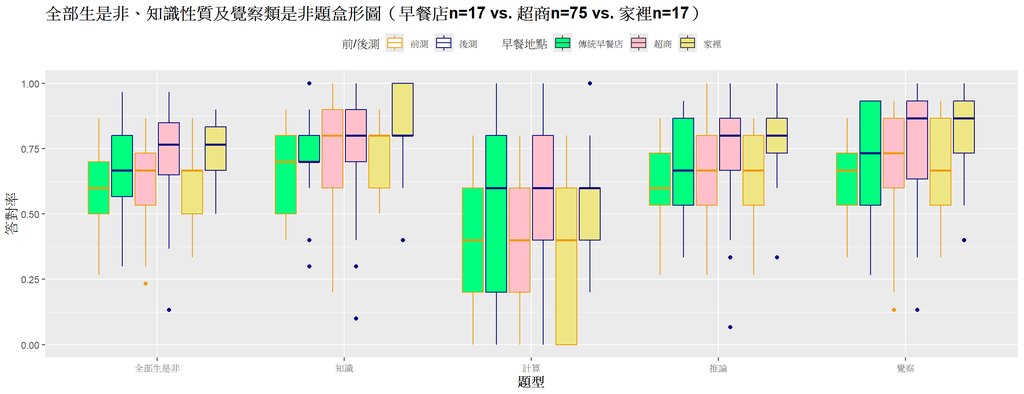

```r
yn.prepost.compare.boxplot(Cdat1_yn%>%filter(C711&(Cfat.bf|Cnofat.bf)),
                           Cdat2_yn%>%filter(C711&(Cfat.bf|Cnofat.bf)),
                           Cdat1_yn%>%filter(Cbf&(Cfat.bf|Cnofat.bf)),
                           Cdat2_yn%>%filter(Cbf&(Cfat.bf|Cnofat.bf)),
                           state=5,
                           data_c1 = Cdat1_yn%>%filter(Chome&(Cfat.bf|Cnofat.bf)),
                           data_c2  = Cdat2_yn%>%filter(Chome&(Cfat.bf|Cnofat.bf)), title="全部生是非、知識性質及覺察類是非題盒形圖（早餐店n=17 vs. 超商n=75 vs. 家裡n=17）")
```

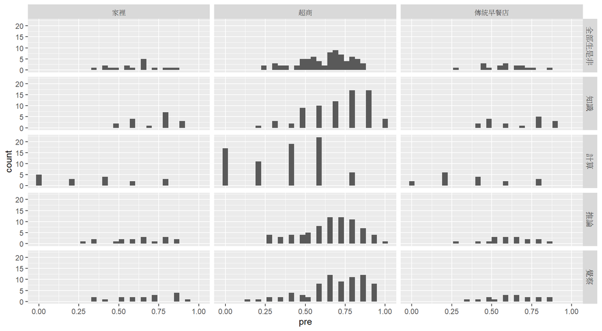

```r
data_a1=Cdat1_yn%>%filter(C711&(Cfat.bf|Cnofat.bf))
data_a2=Cdat2_yn%>%filter(C711&(Cfat.bf|Cnofat.bf))
data_b1=Cdat1_yn%>%filter(Cbf&(Cfat.bf|Cnofat.bf))
data_b2=Cdat2_yn%>%filter(Cbf&(Cfat.bf|Cnofat.bf))
state=5
data_c1=Cdat1_yn%>%filter(Chome&(Cfat.bf|Cnofat.bf))
data_c2=Cdat2_yn%>%filter(Chome&(Cfat.bf|Cnofat.bf))
res<-list()
res[[1]]<-list(data_a1, data_a2)
res[[2]]<-list(data_b1, data_b2)
res[[3]]<-list(data_c1, data_c2)
kk2<-c("超商","傳統早餐店","家裡")

ansrate<-function(ques){

    ansrate<-list()
    for(i in 1:2){
      ansrate[[i]]<-list()
      for(j in 1:length(kk2)){
        ansrate[[i]][[j]]<-rowMeans(sapply(ques,function(ii) (res[[j]][[i]][[ii]]%>%as.numeric()==ans[[ii]]%>%as.numeric())))
      }
    }

    ansrate0<-data.frame(pre=ansrate[[1]]%>%unlist(),post=ansrate[[2]]%>%unlist(),
               type=sapply(1:length(kk2), function(i) rep(kk2[i],dim(res[[i]][[1]])[1]))%>%unlist())

    return(ansrate0)
}

dat<-list()
dat[[1]]<-ansrate(names(ans1))
dat[[2]]<-ansrate(names(ans1)[typee$know==levels(typee$know)[1]])
dat[[3]]<-ansrate(names(ans1)[typee$know==levels(typee$know)[2]])
dat[[4]]<-ansrate(names(ans1)[typee$know==levels(typee$know)[3]])
dat[[5]]<-ansrate(names(ans1)[typee$sense==1])

datt<-rbind(dat[[1]], dat[[2]], dat[[3]], dat[[4]], dat[[5]])
datt$group<-rep(c("全部生是非","知識","推論","計算","覺察"), each=109)

ggplot(datt, aes(x=pre))+
  geom_histogram()+
  facet_grid(group~type)
```

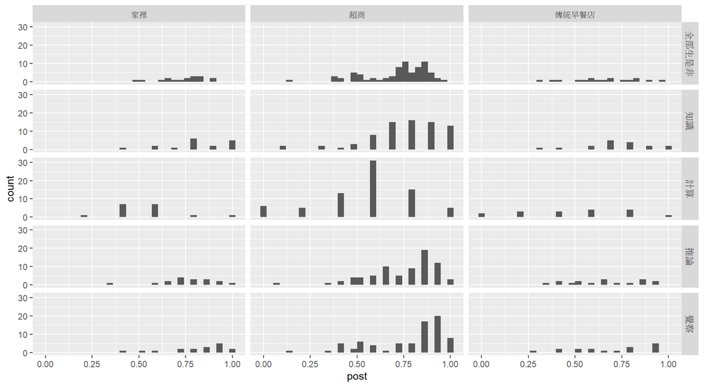

```r
ggplot(datt, aes(x=post))+
  geom_histogram()+
  facet_grid(group~type)
```

# **11. 迴歸分析**

```r
school<-factor(Cdat1_yn$班級)
levels(school)<-c(rep("和平",6), rep("桃農",2),rep("錦和",2))

reg_data<-data.frame(ID=Cdat1_yn$ID,流水號=Cdat1_yn$流水號,
                     前測生是非得分=Cdat1_yn$生是非得分, 前測技是非得分=Cdat1_yn$技是非得分,
                     前測總得分=Cdat1_yn$總得分,
                     後測生是非得分=Cdat2_yn$生是非得分, 後測技是非得分=Cdat2_yn$技是非得分,
                     後測總得分=Cdat2_yn$總得分,
                     Cdat1_yn.st[,7:36], Cdat2_yn.st[,7:36],
                     性別=ifelse(Cboy,"男","女")%>%as.factor(),
                     教育程度=ifelse(Cdat1_yn$班級%in%c("901.0","902.0","903.0","904.0","905.0","906.0","國中"),"國中","高中")%>%as.factor(),
                     有無肥胖=ifelse(Cfat, "有", ifelse(Cnofat,"無",NA)),
                     有無早餐肥胖=ifelse(Cfat.bf, "有", ifelse(Cnofat.bf,"無",NA)),
                     早餐地點=ifelse(C711,"超商",ifelse(Cbf,"早餐店", ifelse(Chome,"家裡",NA))),
                     學校=school)

# reg_data%>%filter(學校=="桃農")%>%summarise(mean(後測生是非得分))

# reg_data%>%filter(教育程度=="高中")%>%summarise(mean(後測生是非得分))
```

## **11-1-1 後測生是非得分（只看性別、教育程度）**

```r
fit1<-lm(後測生是非得分~前測生是非得分+性別*教育程度, data=reg_data)

summary(fit1)
```

```
##
## Call:
## lm(formula = 後測生是非得分 ~ 前測生是非得分 +
##     性別 * 教育程度, data = reg_data)
##
## Residuals:
##     Min      1Q  Median      3Q     Max
## -35.359  -5.701   2.137   7.388  23.447
##
## Coefficients:
##                     Estimate Std. Error t value Pr(>|t|)
## (Intercept)         36.76171    4.29682   8.556 1.78e-14 ***
## 前測生是非得分       0.41562    0.07737   5.372 3.13e-07 ***
## 性別男              -2.37015    2.75972  -0.859    0.392
## 教育程度國中        -3.71633    2.62202  -1.417    0.159
## 性別男:教育程度國中  3.25450    3.56795   0.912    0.363
## ---
## Signif. codes:  0 '***' 0.001 '**' 0.01 '*' 0.05 '.' 0.1 ' ' 1
##
## Residual standard error: 10.51 on 141 degrees of freedom
## Multiple R-squared:  0.2012, Adjusted R-squared:  0.1785
## F-statistic: 8.879 on 4 and 141 DF,  p-value: 2.009e-06
```

## **11-1-2 後測生是非得分**

```r
fit1.1<-lm(後測生是非得分~前測生是非得分+性別*學校*教育程度*有無肥胖*有無早餐肥胖*早餐地點, data=reg_data%>%filter(!is.na(有無早餐肥胖)))

summary(fit1.1)

fit1.1.a<-stepAIC(fit1.1, direction="both")
```

```r
summary(fit1.1.a)
```

```
##
## Call:
## lm(formula = 後測生是非得分 ~ 前測生是非得分 +
##     性別 + 學校 + 有無肥胖 + 有無早餐肥胖 + 早餐地點 +
##     性別:學校 + 學校:有無肥胖 + 學校:有無早餐肥胖 +
##     有無肥胖:有無早餐肥胖 + 性別:早餐地點 + 學校:早餐地點 +
##     有無肥胖:早餐地點 + 學校:有無肥胖:有無早餐肥胖 +
##     性別:學校:早餐地點 + 學校:有無肥胖:早餐地點,
##     data = reg_data %>% filter(!is.na(有無早餐肥胖)))
##
## Residuals:
##      Min       1Q   Median       3Q      Max
## -25.0886  -3.7751   0.1451   4.5100  22.3613
##
## Coefficients: (4 not defined because of singularities)
##                                    Estimate Std. Error t value Pr(>|t|)
## (Intercept)                         24.4599    14.3471   1.705 0.092148 .
## 前測生是非得分                       0.3960     0.1003   3.949 0.000169 ***
## 性別男                              12.4855    11.2283   1.112 0.269524
## 學校桃農                            34.6876    15.9928   2.169 0.033094 *
## 學校錦和                            -3.0198    16.9008  -0.179 0.858647
## 有無肥胖無                         -27.3218     9.3703  -2.916 0.004616 **
## 有無早餐肥胖無                     -20.4348     7.4801  -2.732 0.007765 **
## 早餐地點家裡                        28.8892    20.6897   1.396 0.166533
## 早餐地點超商                        17.5908    14.9877   1.174 0.244050
## 性別男:學校桃農                     -5.3667     6.4400  -0.833 0.407159
## 性別男:學校錦和                    -15.7105    14.0313  -1.120 0.266244
## 學校桃農:有無肥胖無                 -6.2941    18.1518  -0.347 0.729701
## 學校錦和:有無肥胖無                 44.9791    13.5215   3.326 0.001337 **
## 學校桃農:有無早餐肥胖無            -15.6060     7.9779  -1.956 0.053981 .
## 學校錦和:有無早餐肥胖無             44.6547    14.2528   3.133 0.002427 **
## 有無肥胖無:有無早餐肥胖無           35.4771     8.8114   4.026 0.000129 ***
## 性別男:早餐地點家裡                  2.7205    15.0382   0.181 0.856905
## 性別男:早餐地點超商                -10.1691    11.9134  -0.854 0.395914
## 學校桃農:早餐地點家裡              -12.2424    17.5747  -0.697 0.488102
## 學校錦和:早餐地點家裡               18.9831    26.0147   0.730 0.467729
## 學校桃農:早餐地點超商               -8.9568    13.5406  -0.661 0.510234
## 學校錦和:早餐地點超商              -26.4048    11.7299  -2.251 0.027159 *
## 有無肥胖無:早餐地點家裡             -5.8942    16.7062  -0.353 0.725167
## 有無肥胖無:早餐地點超商              4.9978    10.9208   0.458 0.648468
## 學校桃農:有無肥胖無:有無早餐肥胖無       NA         NA      NA       NA
## 學校錦和:有無肥胖無:有無早餐肥胖無 -58.6241    16.4223  -3.570 0.000612 ***
## 性別男:學校桃農:早餐地點家裡        -7.7653    14.4474  -0.537 0.592443
## 性別男:學校錦和:早餐地點家裡       -29.8825    22.1467  -1.349 0.181097
## 性別男:學校桃農:早餐地點超商             NA         NA      NA       NA
## 性別男:學校錦和:早餐地點超商        21.4384    15.6090   1.373 0.173493
## 學校桃農:有無肥胖無:早餐地點家裡         NA         NA      NA       NA
## 學校錦和:有無肥胖無:早餐地點家裡   -37.9380    21.5148  -1.763 0.081709 .
## 學校桃農:有無肥胖無:早餐地點超商    -0.7517    19.5071  -0.039 0.969357
## 學校錦和:有無肥胖無:早餐地點超商         NA         NA      NA       NA
## ---
## Signif. codes:  0 '***' 0.001 '**' 0.01 '*' 0.05 '.' 0.1 ' ' 1
##
## Residual standard error: 9.973 on 79 degrees of freedom
## Multiple R-squared:  0.529,  Adjusted R-squared:  0.3561
## F-statistic:  3.06 on 29 and 79 DF,  p-value: 4.519e-05
```

## **11-1-3 後測生是非得分（國高中分開建模，全部變數均考慮）**

```r
# fit1.2<-lm(後測生是非得分~前測生是非得分+性別*學校*有無肥胖*有無早餐肥胖*早餐地點, data=reg_data%>%filter(!is.na(有無早餐肥胖)))
#
# fit1.2.a<-stepAIC(fit1.2, direction="both")

fit1.2.ju<-lm(後測生是非得分~前測生是非得分+性別*學校*有無肥胖*有無早餐肥胖*早餐地點, data=reg_data%>%filter(!is.na(有無早餐肥胖))%>%filter(教育程度=="國中"))

fit1.2.ju.a<-stepAIC(fit1.2.ju, direction="both")

fit1.2.se<-lm(後測生是非得分~前測生是非得分+性別*學校*有無肥胖*有無早餐肥胖*早餐地點, data=reg_data%>%filter(!is.na(有無早餐肥胖))%>%filter(教育程度=="高中"))

fit1.2.se.a<-stepAIC(fit1.2.se, direction="both")
```

```r
summary(fit1.2.ju.a)
```

```
##
## Call:
## lm(formula = 後測生是非得分 ~ 前測生是非得分 +
##     學校 + 有無肥胖 + 有無早餐肥胖 + 早餐地點 +
##     有無肥胖:有無早餐肥胖, data = reg_data %>% filter(!is.na(有無早餐肥胖)) %>%
##     filter(教育程度 == "國中"))
##
## Residuals:
##     Min      1Q  Median      3Q     Max
## -28.247  -8.490   1.212   8.795  22.098
##
## Coefficients:
##                           Estimate Std. Error t value Pr(>|t|)
## (Intercept)                38.4420     8.7720   4.382 5.87e-05 ***
## 前測生是非得分              0.3321     0.1407   2.361  0.02210 *
## 學校錦和                   11.7328     3.9626   2.961  0.00465 **
## 有無肥胖無                -21.4656     7.0004  -3.066  0.00346 **
## 有無早餐肥胖無            -19.5253     7.5446  -2.588  0.01255 *
## 早餐地點家裡               16.6316     6.0887   2.732  0.00864 **
## 早餐地點超商               10.1965     4.5148   2.258  0.02822 *
## 有無肥胖無:有無早餐肥胖無  29.4602     8.9265   3.300  0.00177 **
## ---
## Signif. codes:  0 '***' 0.001 '**' 0.01 '*' 0.05 '.' 0.1 ' ' 1
##
## Residual standard error: 11.76 on 51 degrees of freedom
## Multiple R-squared:  0.4302, Adjusted R-squared:  0.352
## F-statistic:   5.5 on 7 and 51 DF,  p-value: 9.48e-05
```

```r
summary(fit1.2.se.a)
```

```
##
## Call:
## lm(formula = 後測生是非得分 ~ 前測生是非得分 +
##     學校 + 有無肥胖 + 有無早餐肥胖 + 早餐地點 +
##     學校:有無肥胖 + 有無肥胖:有無早餐肥胖 + 學校:早餐地點 +
##     有無肥胖:早餐地點, data = reg_data %>% filter(!is.na(有無早餐肥胖)) %>%
##     filter(教育程度 == "高中"))
##
## Residuals:
##     Min      1Q  Median      3Q     Max
## -16.907  -3.397   1.452   4.448  12.361
##
## Coefficients:
##                           Estimate Std. Error t value Pr(>|t|)
## (Intercept)                -6.0092    14.6555  -0.410 0.684151
## 前測生是非得分              0.4723     0.1218   3.877 0.000418 ***
## 學校錦和                   29.7502    12.6974   2.343 0.024614 *
## 有無肥胖無                 35.7997    14.2204   2.517 0.016279 *
## 有無早餐肥胖無             31.9450    10.4288   3.063 0.004070 **
## 早餐地點家裡               47.4809    14.6327   3.245 0.002495 **
## 早餐地點超商               -0.8678     7.2490  -0.120 0.905358
## 學校錦和:有無肥胖無       -21.9471     9.3517  -2.347 0.024395 *
## 有無肥胖無:有無早餐肥胖無 -35.0262    10.8678  -3.223 0.002649 **
## 學校錦和:早餐地點家裡     -35.6330    12.7589  -2.793 0.008224 **
## 學校錦和:早餐地點超商      -5.4440     9.7073  -0.561 0.578306
## 有無肥胖無:早餐地點家裡   -41.4574    16.4246  -2.524 0.016021 *
## 有無肥胖無:早餐地點超商     6.2720    11.4247   0.549 0.586313
## ---
## Signif. codes:  0 '***' 0.001 '**' 0.01 '*' 0.05 '.' 0.1 ' ' 1
##
## Residual standard error: 7.17 on 37 degrees of freedom
## Multiple R-squared:  0.5129, Adjusted R-squared:  0.355
## F-statistic: 3.247 on 12 and 37 DF,  p-value: 0.002893
```

```r
#summary(aov(fit1.2.ju.a))

# pred_data<-data.frame(前測生是非得分=0, 學校=rep(c("錦和","和平"),each=12),有無肥胖=rep(c("有","無"),each=6),有無早餐肥胖=rep(c("有","無"),each=3),早餐地點=rep(c("超商","早餐店","家裡")))
# pred_data$pred<-predict(fit1.2.ju.a, pred_data)%>%round(digits=1)
```

## **11-1-4 後測生是非得分（排除性別、學校）**

```r
fit1.3.ju<-lm(後測生是非得分~前測生是非得分+有無肥胖*有無早餐肥胖*早餐地點, data=reg_data%>%filter(!is.na(有無早餐肥胖))%>%filter(教育程度=="國中"))

fit1.3.ju.a<-stepAIC(fit1.3.ju, direction="both")

fit1.3.se<-lm(後測生是非得分~前測生是非得分+有無肥胖*有無早餐肥胖*早餐地點, data=reg_data%>%filter(!is.na(有無早餐肥胖))%>%filter(教育程度=="高中"))

fit1.3.se.a<-stepAIC(fit1.3.se, direction="both")
```

```r
summary(fit1.3.ju.a)
```

```
##
## Call:
## lm(formula = 後測生是非得分 ~ 前測生是非得分 +
##     有無肥胖 + 有無早餐肥胖 + 早餐地點 + 有無肥胖:有無早餐肥胖,
##     data = reg_data %>% filter(!is.na(有無早餐肥胖)) %>%
##         filter(教育程度 == "國中"))
##
## Residuals:
##     Min      1Q  Median      3Q     Max
## -29.095  -7.005   1.058   9.384  20.854
##
## Coefficients:
##                           Estimate Std. Error t value Pr(>|t|)
## (Intercept)                34.8151     9.3122   3.739 0.000462 ***
## 前測生是非得分              0.4197     0.1475   2.846 0.006319 **
## 有無肥胖無                -17.8548     7.3902  -2.416 0.019240 *
## 有無早餐肥胖無            -16.2796     8.0026  -2.034 0.047039 *
## 早餐地點家裡               16.8715     6.5270   2.585 0.012587 *
## 早餐地點超商                9.0179     4.8214   1.870 0.067060 .
## 有無肥胖無:有無早餐肥胖無  25.8078     9.4782   2.723 0.008788 **
## ---
## Signif. codes:  0 '***' 0.001 '**' 0.01 '*' 0.05 '.' 0.1 ' ' 1
##
## Residual standard error: 12.61 on 52 degrees of freedom
## Multiple R-squared:  0.3322, Adjusted R-squared:  0.2552
## F-statistic: 4.312 on 6 and 52 DF,  p-value: 0.001334
```

```r
summary(fit1.3.se.a)
```

```
##
## Call:
## lm(formula = 後測生是非得分 ~ 前測生是非得分 +
##     有無肥胖 + 有無早餐肥胖 + 早餐地點 + 有無肥胖:有無早餐肥胖 +
##     有無肥胖:早餐地點 + 有無早餐肥胖:早餐地點,
##     data = reg_data %>% filter(!is.na(有無早餐肥胖)) %>%
##         filter(教育程度 == "高中"))
##
## Residuals:
##      Min       1Q   Median       3Q      Max
## -18.1182  -3.5707   0.5815   5.2213  13.2728
##
## Coefficients:
##                             Estimate Std. Error t value Pr(>|t|)
## (Intercept)                  10.3333    15.7971   0.654   0.5169
## 前測生是非得分                0.2964     0.1164   2.547   0.0149 *
## 有無肥胖無                   26.0530    12.5008   2.084   0.0437 *
## 有無早餐肥胖無               25.4961    13.8140   1.846   0.0725 .
## 早餐地點家裡                 32.9507    15.9983   2.060   0.0462 *
## 早餐地點超商                 14.5711    12.4753   1.168   0.2499
## 有無肥胖無:有無早餐肥胖無   -19.3670    10.4355  -1.856   0.0710 .
## 有無肥胖無:早餐地點家裡     -37.3962    15.0309  -2.488   0.0172 *
## 有無肥胖無:早餐地點超商      -4.8734     8.8661  -0.550   0.5857
## 有無早餐肥胖無:早餐地點家裡   3.4080    11.2276   0.304   0.7631
## 有無早餐肥胖無:早餐地點超商 -10.3416    10.1393  -1.020   0.3140
## ---
## Signif. codes:  0 '***' 0.001 '**' 0.01 '*' 0.05 '.' 0.1 ' ' 1
##
## Residual standard error: 8.18 on 39 degrees of freedom
## Multiple R-squared:  0.3318, Adjusted R-squared:  0.1605
## F-statistic: 1.937 on 10 and 39 DF,  p-value: 0.06908
```

## **11-1-5 生是非得分”進步量”（國高中分開建模，全部變數均考慮）**

```r
fit1.4.ju<-lm((後測生是非得分-前測生是非得分)~性別*學校*有無肥胖*有無早餐肥胖*早餐地點, data=reg_data%>%filter(!is.na(有無早餐肥胖))%>%filter(教育程度=="國中"))

fit1.4.ju.a<-stepAIC(fit1.4.ju, direction="both")

fit1.4.se<-lm((後測生是非得分-前測生是非得分)~性別*學校*有無肥胖*有無早餐肥胖*早餐地點, data=reg_data%>%filter(!is.na(有無早餐肥胖))%>%filter(教育程度=="高中"))

fit1.4.se.a<-stepAIC(fit1.4.se, direction="both")
```

```r
summary(fit1.4.ju.a)
```

```
##
## Call:
## lm(formula = (後測生是非得分 - 前測生是非得分) ~
##     性別 + 學校 + 有無肥胖 + 有無早餐肥胖 + 早餐地點 +
##         有無肥胖:有無早餐肥胖 + 性別:早餐地點,
##     data = reg_data %>% filter(!is.na(有無早餐肥胖)) %>%
##         filter(教育程度 == "國中"))
##
## Residuals:
##     Min      1Q  Median      3Q     Max
## -27.007  -7.129  -1.833   5.656  30.493
##
## Coefficients:
##                            Estimate Std. Error t value Pr(>|t|)
## (Intercept)                 6.67217   10.79340   0.618   0.5393
## 性別男                      0.57901   10.43407   0.055   0.9560
## 學校錦和                   10.07945    5.06861   1.989   0.0523 .
## 有無肥胖無                -18.33165    8.17029  -2.244   0.0294 *
## 有無早餐肥胖無            -10.78905    8.43109  -1.280   0.2067
## 早餐地點家裡                5.63824   10.42164   0.541   0.5909
## 早餐地點超商                7.06000    9.03157   0.782   0.4382
## 有無肥胖無:有無早餐肥胖無  22.39557   10.19622   2.196   0.0328 *
## 性別男:早餐地點家裡        26.55920   14.48045   1.834   0.0727 .
## 性別男:早餐地點超商         0.02138   11.60670   0.002   0.9985
## ---
## Signif. codes:  0 '***' 0.001 '**' 0.01 '*' 0.05 '.' 0.1 ' ' 1
##
## Residual standard error: 13.6 on 49 degrees of freedom
## Multiple R-squared:  0.266,  Adjusted R-squared:  0.1311
## F-statistic: 1.973 on 9 and 49 DF,  p-value: 0.0631
```

```r
summary(fit1.4.se.a)
```

```
##
## Call:
## lm(formula = (後測生是非得分 - 前測生是非得分) ~
##     性別 + 學校 + 有無肥胖 + 有無早餐肥胖 + 早餐地點 +
##         性別:學校 + 學校:有無肥胖 + 有無肥胖:有無早餐肥胖 +
##         性別:早餐地點 + 學校:早餐地點 + 有無肥胖:早餐地點 +
##         有無早餐肥胖:早餐地點, data = reg_data %>%
##     filter(!is.na(有無早餐肥胖)) %>% filter(教育程度 ==
##     "高中"))
##
## Residuals:
##     Min      1Q  Median      3Q     Max
## -15.000  -5.714   0.000   4.286  15.000
##
## Coefficients: (1 not defined because of singularities)
##                             Estimate Std. Error t value Pr(>|t|)
## (Intercept)                  -27.415     18.168  -1.509 0.140822
## 性別男                       -18.835     11.859  -1.588 0.121779
## 學校錦和                      -4.798     24.445  -0.196 0.845598
## 有無肥胖無                    56.250     16.286   3.454 0.001537 **
## 有無早餐肥胖無                42.500     12.311   3.452 0.001544 **
## 早餐地點家裡                  55.539     21.760   2.552 0.015512 *
## 早餐地點超商                 -10.207     13.771  -0.741 0.463825
## 性別男:學校錦和               13.835      8.803   1.572 0.125580
## 學校錦和:有無肥胖無          -18.543     12.821  -1.446 0.157521
## 有無肥胖無:有無早餐肥胖無    -35.493     13.582  -2.613 0.013401 *
## 性別男:早餐地點家裡           24.668     13.826   1.784 0.083594 .
## 性別男:早餐地點超商           13.957     10.670   1.308 0.199919
## 學校錦和:早餐地點家裡        -30.493     17.267  -1.766 0.086640 .
## 學校錦和:早餐地點超商         28.463     15.529   1.833 0.075854 .
## 有無肥胖無:早餐地點家裡      -75.207     19.792  -3.800 0.000592 ***
## 有無肥胖無:早餐地點超商      -20.042     13.975  -1.434 0.160925
## 有無早餐肥胖無:早餐地點家裡  -13.673     11.573  -1.181 0.245874
## 有無早餐肥胖無:早餐地點超商       NA         NA      NA       NA
## ---
## Signif. codes:  0 '***' 0.001 '**' 0.01 '*' 0.05 '.' 0.1 ' ' 1
##
## Residual standard error: 8.705 on 33 degrees of freedom
## Multiple R-squared:  0.579,  Adjusted R-squared:  0.3749
## F-statistic: 2.837 on 16 and 33 DF,  p-value: 0.005528
```

```r
#fit1.4.se.a$coefficients[18]<-0

# pred_data<-data.frame(學校=rep(c("錦和","桃農"),each=12*2),有無肥胖=rep(c("有","無"),each=6*2),有無早餐肥胖=rep(c("有","無"),each=3*2),早餐地點=rep(c("超商","早餐店","家裡"),each=2), 性別=rep(c("男","女")))
# pred_data$pred<-predict(fit1.4.se.a, pred_data)%>%round(digits=1)
```

## **11-2-1 後測總分（只看性別、教育程度）**

```r
fit2<-lm(後測總得分~前測總得分+性別*教育程度, data=reg_data)

summary(fit2)

fit2.1<-stepAIC(fit2, direction="both")
```

```r
summary(fit2.1)
```

```
##
## Call:
## lm(formula = 後測總得分 ~ 前測總得分 + 教育程度,
##     data = reg_data)
##
## Residuals:
##     Min      1Q  Median      3Q     Max
## -45.973  -7.368   2.264   8.698  25.634
##
## Coefficients:
##              Estimate Std. Error t value Pr(>|t|)
## (Intercept)  52.60696    5.21414  10.089  < 2e-16 ***
## 前測總得分    0.41064    0.07963   5.157 8.22e-07 ***
## 教育程度國中 -3.63947    2.48147  -1.467    0.145
## ---
## Signif. codes:  0 '***' 0.001 '**' 0.01 '*' 0.05 '.' 0.1 ' ' 1
##
## Residual standard error: 14.04 on 143 degrees of freedom
## Multiple R-squared:  0.202,  Adjusted R-squared:  0.1909
## F-statistic:  18.1 on 2 and 143 DF,  p-value: 9.822e-08
```

## **11-2-2 後測總分**

```r
fit2.1<-lm(後測總得分~前測總得分+性別*學校*教育程度*有無肥胖*有無早餐肥胖*早餐地點, data=reg_data%>%filter(!is.na(有無早餐肥胖)))

summary(fit2.1)

fit2.1.a<-stepAIC(fit2.1, direction="both")
```

```r
summary(fit2.1.a)
```

```
##
## Call:
## lm(formula = 後測總得分 ~ 前測總得分 + 性別 + 學校 +
##     有無肥胖 + 有無早餐肥胖 + 早餐地點 + 性別:學校 +
##     學校:有無肥胖 + 性別:有無早餐肥胖 + 學校:有無早餐肥胖 +
##     有無肥胖:有無早餐肥胖 + 學校:早餐地點 + 有無肥胖:早餐地點 +
##     有無早餐肥胖:早餐地點 + 性別:學校:有無早餐肥胖 +
##     學校:有無肥胖:有無早餐肥胖, data = reg_data %>%
##     filter(!is.na(有無早餐肥胖)))
##
## Residuals:
##     Min      1Q  Median      3Q     Max
## -32.759  -5.402   0.545   6.428  28.226
##
## Coefficients: (2 not defined because of singularities)
##                                     Estimate Std. Error t value Pr(>|t|)
## (Intercept)                         32.99734   16.09532   2.050 0.043548 *
## 前測總得分                           0.35314    0.09877   3.576 0.000589 ***
## 性別男                              13.23009   12.41990   1.065 0.289897
## 學校桃農                            36.58750   22.13885   1.653 0.102229
## 學校錦和                            -0.26374   18.82720  -0.014 0.988857
## 有無肥胖無                         -39.86832   12.26388  -3.251 0.001670 **
## 有無早餐肥胖無                       0.70387   21.48728   0.033 0.973948
## 早餐地點家裡                        36.63465   18.39837   1.991 0.049790 *
## 早餐地點超商                        21.46580   11.41541   1.880 0.063601 .
## 性別男:學校桃農                     24.77562   20.86516   1.187 0.238492
## 性別男:學校錦和                      3.54618    8.05405   0.440 0.660880
## 學校桃農:有無肥胖無                -14.81315   12.38254  -1.196 0.235030
## 學校錦和:有無肥胖無                 27.69413   16.41462   1.687 0.095373 .
## 性別男:有無早餐肥胖無              -10.74873   13.39197  -0.803 0.424511
## 學校桃農:有無早餐肥胖無            -13.38439   14.20429  -0.942 0.348818
## 學校錦和:有無早餐肥胖無             45.31950   17.86816   2.536 0.013099 *
## 有無肥胖無:有無早餐肥胖無           35.28482   12.60553   2.799 0.006386 **
## 學校桃農:早餐地點家裡              -13.10834   15.70784  -0.835 0.406419
## 學校錦和:早餐地點家裡              -27.00981   13.09178  -2.063 0.042266 *
## 學校桃農:早餐地點超商               -2.07574   14.82319  -0.140 0.888977
## 學校錦和:早餐地點超商              -21.48209    9.58129  -2.242 0.027656 *
## 有無肥胖無:早餐地點家裡            -12.15866   17.41219  -0.698 0.486975
## 有無肥胖無:早餐地點超商             21.72093   13.56292   1.601 0.113113
## 有無早餐肥胖無:早餐地點家裡          9.62207   12.96398   0.742 0.460078
## 有無早餐肥胖無:早餐地點超商        -19.85103   12.21656  -1.625 0.108016
## 性別男:學校桃農:有無早餐肥胖無     -31.14860   22.06396  -1.412 0.161810
## 性別男:學校錦和:有無早餐肥胖無            NA         NA      NA       NA
## 學校桃農:有無肥胖無:有無早餐肥胖無        NA         NA      NA       NA
## 學校錦和:有無肥胖無:有無早餐肥胖無 -47.80276   21.18652  -2.256 0.026715 *
## ---
## Signif. codes:  0 '***' 0.001 '**' 0.01 '*' 0.05 '.' 0.1 ' ' 1
##
## Residual standard error: 13.04 on 82 degrees of freedom
## Multiple R-squared:  0.5431, Adjusted R-squared:  0.3982
## F-statistic: 3.749 on 26 and 82 DF,  p-value: 2.584e-06
```

```r
#
# library(olsrr)
# ols_step_both_adj_r2(fit2.1)
# ols_step_all_possible(fit2.1)
```

## **11-2-3 後測總得分（國高中分開建模，全部變數均考慮）**

```r
# fit2.2<-lm(後測總得分~前測總得分+性別*學校*有無肥胖*有無早餐肥胖*早餐地點, data=reg_data%>%filter(!is.na(有無早餐肥胖)))
#
# fit2.2.a<-stepAIC(fit2.2, direction="both")

#fit2.2.ju<-lm((後測總得分-前測總得分)~性別*學校*有無肥胖*有無早餐肥胖*早餐地點, data=reg_data%>%filter(!is.na(有無早餐肥胖))%>%filter(教育程度=="國中"))

fit2.2.ju<-lm(後測總得分~前測總得分+性別*學校*有無肥胖*有無早餐肥胖*早餐地點, data=reg_data%>%filter(!is.na(有無早餐肥胖))%>%filter(教育程度=="國中"))

fit2.2.ju.a<-stepAIC(fit2.2.ju, direction="both")

fit2.2.se<-lm(後測總得分~前測總得分+性別*學校*有無肥胖*有無早餐肥胖*早餐地點, data=reg_data%>%filter(!is.na(有無早餐肥胖))%>%filter(教育程度=="高中"))

fit2.2.se.a<-stepAIC(fit2.2.se, direction="both")
```

```r
summary(fit2.2.ju.a)
```

```
##
## Call:
## lm(formula = 後測總得分 ~ 前測總得分 + 學校 + 有無肥胖 +
##     有無早餐肥胖 + 早餐地點 + 有無肥胖:有無早餐肥胖,
##     data = reg_data %>% filter(!is.na(有無早餐肥胖)) %>%
##         filter(教育程度 == "國中"))
##
## Residuals:
##     Min      1Q  Median      3Q     Max
## -39.023  -8.713   1.963  11.591  21.890
##
## Coefficients:
##                           Estimate Std. Error t value Pr(>|t|)
## (Intercept)                46.6185    10.8223   4.308 7.52e-05 ***
## 前測總得分                  0.3651     0.1500   2.433  0.01851 *
## 學校錦和                   13.7839     5.6006   2.461  0.01727 *
## 有無肥胖無                -27.3061     9.3711  -2.914  0.00529 **
## 有無早餐肥胖無            -22.6236     9.8863  -2.288  0.02629 *
## 早餐地點家裡               28.2033     8.1504   3.460  0.00110 **
## 早餐地點超商               19.7508     6.0420   3.269  0.00194 **
## 有無肥胖無:有無早餐肥胖無  35.4223    11.9112   2.974  0.00448 **
## ---
## Signif. codes:  0 '***' 0.001 '**' 0.01 '*' 0.05 '.' 0.1 ' ' 1
##
## Residual standard error: 15.75 on 51 degrees of freedom
## Multiple R-squared:  0.4586, Adjusted R-squared:  0.3842
## F-statistic: 6.171 on 7 and 51 DF,  p-value: 2.98e-05
```

```r
summary(fit2.2.se.a)
```

```
##
## Call:
## lm(formula = 後測總得分 ~ 前測總得分 + 性別 + 學校 +
##     有無肥胖 + 有無早餐肥胖 + 早餐地點 + 性別:學校 +
##     有無肥胖:有無早餐肥胖 + 性別:早餐地點 + 學校:早餐地點 +
##     有無肥胖:早餐地點, data = reg_data %>% filter(!is.na(有無早餐肥胖)) %>%
##     filter(教育程度 == "高中"))
##
## Residuals:
##     Min      1Q  Median      3Q     Max
## -16.277  -3.790   0.000   5.493  12.889
##
## Coefficients:
##                           Estimate Std. Error t value Pr(>|t|)
## (Intercept)                34.3437    17.1344   2.004 0.053047 .
## 前測總得分                  0.4444     0.1110   4.004 0.000320 ***
## 性別男                    -14.1458    10.8996  -1.298 0.203083
## 學校錦和                  -17.2910    15.2559  -1.133 0.264975
## 有無肥胖無                 28.6929    15.6791   1.830 0.076027 .
## 有無早餐肥胖無             26.6104    10.9414   2.432 0.020430 *
## 早餐地點家裡               55.5218    20.0623   2.767 0.009074 **
## 早餐地點超商               -3.7244    13.5911  -0.274 0.785716
## 性別男:學校錦和            18.4977     7.5422   2.453 0.019472 *
## 有無肥胖無:有無早餐肥胖無 -24.2055    11.0832  -2.184 0.035957 *
## 性別男:早餐地點家裡        20.9501    13.4529   1.557 0.128661
## 性別男:早餐地點超商         6.5293    10.0153   0.652 0.518829
## 學校錦和:早餐地點家裡     -39.4021    16.5687  -2.378 0.023165 *
## 學校錦和:早餐地點超商      12.4594    14.5086   0.859 0.396489
## 有無肥胖無:早餐地點家裡   -72.7195    19.9118  -3.652 0.000867 ***
## 有無肥胖無:早餐地點超商    -7.9943    13.7618  -0.581 0.565135
## ---
## Signif. codes:  0 '***' 0.001 '**' 0.01 '*' 0.05 '.' 0.1 ' ' 1
##
## Residual standard error: 8.628 on 34 degrees of freedom
## Multiple R-squared:  0.548,  Adjusted R-squared:  0.3486
## F-statistic: 2.748 on 15 and 34 DF,  p-value: 0.007208
```

```r
# pred_data<-data.frame(前測總得分=0, 學校=rep(c("錦和","桃農"),each=12*2),有無肥胖=rep(c("有","無"),each=6*2),有無早餐肥胖=rep(c("有","無"),each=3*2),早餐地點=rep(c("超商","早餐店","家裡"),each=2), 性別=rep(c("男","女")))
# pred_data$pred<-predict(fit2.2.se.a, pred_data)%>%round(digits=1)
```

## **11-3-1 後測技是非得分**

```r
fit3.1<-lm(後測技是非得分~前測技是非得分+性別*學校*教育程度*有無肥胖*有無早餐肥胖*早餐地點, data=reg_data%>%filter(!is.na(有無早餐肥胖)))

summary(fit3.1)

fit3.1.a<-stepAIC(fit3.1, direction="both")
```

```r
summary(fit3.1.a)
```

```
##
## Call:
## lm(formula = 後測技是非得分 ~ 前測技是非得分 +
##     性別 + 學校 + 有無肥胖 + 有無早餐肥胖 + 早餐地點 +
##     性別:學校 + 性別:有無早餐肥胖 + 學校:有無早餐肥胖 +
##     有無肥胖:早餐地點 + 有無早餐肥胖:早餐地點 +
##     性別:學校:有無早餐肥胖, data = reg_data %>% filter(!is.na(有無早餐肥胖)))
##
## Residuals:
##      Min       1Q   Median       3Q      Max
## -17.5967  -2.7307   0.4588   3.5951  10.0000
##
## Coefficients: (1 not defined because of singularities)
##                                 Estimate Std. Error t value Pr(>|t|)
## (Intercept)                      4.68683    5.44598   0.861  0.39174
## 前測技是非得分                   0.22294    0.07995   2.789  0.00646 **
## 性別男                           3.52881    4.46054   0.791  0.43096
## 學校桃農                         2.49189    5.34647   0.466  0.64228
## 學校錦和                        -3.63393    4.28823  -0.847  0.39901
## 有無肥胖無                      -7.18336    3.51827  -2.042  0.04411 *
## 有無早餐肥胖無                  15.57505    5.71903   2.723  0.00776 **
## 早餐地點家裡                    12.31084    5.17875   2.377  0.01956 *
## 早餐地點超商                    11.88395    3.97079   2.993  0.00357 **
## 性別男:學校桃農                 14.82401    7.02111   2.111  0.03751 *
## 性別男:學校錦和                  4.47554    2.91217   1.537  0.12784
## 性別男:有無早餐肥胖無           -6.93400    4.72842  -1.466  0.14601
## 學校桃農:有無早餐肥胖無         -0.12115    5.64284  -0.021  0.98292
## 學校錦和:有無早餐肥胖無          4.47169    3.73286   1.198  0.23409
## 有無肥胖無:早餐地點家裡         -5.96604    5.22294  -1.142  0.25637
## 有無肥胖無:早餐地點超商          5.61258    3.93758   1.425  0.15750
## 有無早餐肥胖無:早餐地點家裡     -0.24785    4.67887  -0.053  0.95787
## 有無早餐肥胖無:早餐地點超商    -12.97838    4.20950  -3.083  0.00272 **
## 性別男:學校桃農:有無早餐肥胖無 -12.41857    7.60179  -1.634  0.10583
## 性別男:學校錦和:有無早餐肥胖無        NA         NA      NA       NA
## ---
## Signif. codes:  0 '***' 0.001 '**' 0.01 '*' 0.05 '.' 0.1 ' ' 1
##
## Residual standard error: 5.27 on 90 degrees of freedom
## Multiple R-squared:  0.4488, Adjusted R-squared:  0.3386
## F-statistic: 4.071 on 18 and 90 DF,  p-value: 4.196e-06
```

## **11-3-2 後測技是非得分（國高中分開建模，全部變數均考慮）**

```r
fit3.2.ju<-lm(後測技是非得分~前測技是非得分+性別*學校*有無肥胖*有無早餐肥胖*早餐地點, data=reg_data%>%filter(!is.na(有無早餐肥胖))%>%filter(教育程度=="國中"))

fit3.2.ju.a<-stepAIC(fit3.2.ju, direction="both")

fit3.2.se<-lm(後測技是非得分~前測技是非得分+性別*學校*有無肥胖*有無早餐肥胖*早餐地點, data=reg_data%>%filter(!is.na(有無早餐肥胖))%>%filter(教育程度=="高中"))

fit3.2.se.a<-stepAIC(fit3.2.se, direction="both")
```

```r
summary(fit3.2.ju.a)
```

```
##
## Call:
## lm(formula = 後測技是非得分 ~ 前測技是非得分 +
##     有無早餐肥胖 + 早餐地點 + 有無早餐肥胖:早餐地點,
##     data = reg_data %>% filter(!is.na(有無早餐肥胖)) %>%
##         filter(教育程度 == "國中"))
##
## Residuals:
##      Min       1Q   Median       3Q      Max
## -15.3184  -3.2914  -0.0215   4.1740   9.6816
##
## Coefficients:
##                             Estimate Std. Error t value Pr(>|t|)
## (Intercept)                   3.7293     3.6211   1.030  0.30782
## 前測技是非得分                0.4406     0.1269   3.471  0.00105 **
## 有無早餐肥胖無                4.7669     4.3124   1.105  0.27407
## 早餐地點家裡                  1.2707     7.0922   0.179  0.85850
## 早餐地點超商                 14.1241     4.0839   3.458  0.00109 **
## 有無早餐肥胖無:早餐地點家裡  10.0783     7.9435   1.269  0.21018
## 有無早餐肥胖無:早餐地點超商  -7.3019     4.9260  -1.482  0.14430
## ---
## Signif. codes:  0 '***' 0.001 '**' 0.01 '*' 0.05 '.' 0.1 ' ' 1
##
## Residual standard error: 6.098 on 52 degrees of freedom
## Multiple R-squared:  0.4371, Adjusted R-squared:  0.3721
## F-statistic: 6.729 on 6 and 52 DF,  p-value: 2.581e-05
```

```r
summary(fit3.2.se.a)
```

```
##
## Call:
## lm(formula = 後測技是非得分 ~ 性別 + 學校 + 有無肥胖 +
##     有無早餐肥胖 + 早餐地點 + 性別:有無早餐肥胖 +
##     學校:早餐地點 + 有無肥胖:早餐地點, data = reg_data %>%
##     filter(!is.na(有無早餐肥胖)) %>% filter(教育程度 ==
##     "高中"))
##
## Residuals:
##     Min      1Q  Median      3Q     Max
## -7.5559 -0.8153  0.0000  2.4441  5.3023
##
## Coefficients:
##                         Estimate Std. Error t value Pr(>|t|)
## (Intercept)              21.1941     3.6740   5.769 1.18e-06 ***
## 性別男                    4.8951     3.3238   1.473   0.1491
## 學校錦和                 -1.1558     4.3337  -0.267   0.7911
## 有無肥胖無               -3.5893     4.8017  -0.747   0.4594
## 有無早餐肥胖無            2.5476     2.6778   0.951   0.3474
## 早餐地點家裡             11.9908     5.1781   2.316   0.0261 *
## 早餐地點超商             -0.4099     3.1155  -0.132   0.8960
## 性別男:有無早餐肥胖無    -4.8869     3.5760  -1.367   0.1798
## 學校錦和:早餐地點家裡   -11.9243     6.5378  -1.824   0.0760 .
## 學校錦和:早餐地點超商    -1.6941     4.7766  -0.355   0.7248
## 有無肥胖無:早餐地點家裡  -8.9107     6.4401  -1.384   0.1745
## 有無肥胖無:早餐地點超商   2.8050     5.2247   0.537   0.5945
## ---
## Signif. codes:  0 '***' 0.001 '**' 0.01 '*' 0.05 '.' 0.1 ' ' 1
##
## Residual standard error: 3.504 on 38 degrees of freedom
## Multiple R-squared:  0.3386, Adjusted R-squared:  0.1472
## F-statistic: 1.769 on 11 and 38 DF,  p-value: 0.09498
```

```r
fit3.2.se.b<-lm(後測技是非得分 ~ 前測技是非得分 +
                  性別 + 學校 + 有無肥胖 + 有無早餐肥胖 +
    早餐地點 + 性別:有無早餐肥胖 + 學校:早餐地點 +
    有無肥胖:早餐地點, data=reg_data%>%filter(!is.na(有無早餐肥胖))%>%filter(教育程度=="高中"))
summary(fit3.2.se.b)
```

```
##
## Call:
## lm(formula = 後測技是非得分 ~ 前測技是非得分 +
##     性別 + 學校 + 有無肥胖 + 有無早餐肥胖 + 早餐地點 +
##     性別:有無早餐肥胖 + 學校:早餐地點 + 有無肥胖:早餐地點,
##     data = reg_data %>% filter(!is.na(有無早餐肥胖)) %>%
##         filter(教育程度 == "高中"))
##
## Residuals:
##     Min      1Q  Median      3Q     Max
## -8.1886 -1.0343  0.1321  1.9283  5.5104
##
## Coefficients:
##                          Estimate Std. Error t value Pr(>|t|)
## (Intercept)              20.75958    3.73564   5.557  2.5e-06 ***
## 前測技是非得分            0.05285    0.06814   0.776   0.4429
## 性別男                    4.71023    3.34991   1.406   0.1680
## 學校錦和                 -1.33264    4.36257  -0.305   0.7617
## 有無肥胖無               -3.49833    4.82852  -0.725   0.4733
## 有無早餐肥胖無            2.50877    2.69238   0.932   0.3575
## 早餐地點家裡             12.28216    5.21897   2.353   0.0240 *
## 早餐地點超商             -0.23645    3.13989  -0.075   0.9404
## 性別男:有無早餐肥胖無    -4.75710    3.59881  -1.322   0.1943
## 學校錦和:早餐地點家裡   -11.81572    6.57381  -1.797   0.0804 .
## 學校錦和:早餐地點超商    -1.48830    4.80916  -0.309   0.7587
## 有無肥胖無:早餐地點家裡  -9.53019    6.52318  -1.461   0.1525
## 有無肥胖無:早餐地點超商   2.38062    5.28076   0.451   0.6548
## ---
## Signif. codes:  0 '***' 0.001 '**' 0.01 '*' 0.05 '.' 0.1 ' ' 1
##
## Residual standard error: 3.523 on 37 degrees of freedom
## Multiple R-squared:  0.3492, Adjusted R-squared:  0.1382
## F-statistic: 1.655 on 12 and 37 DF,  p-value: 0.1186
```

```r
# pred_data<-data.frame(前測技是非得分=0,
#                       有無早餐肥胖=rep(c("有","無"),each=3),
#                       早餐地點=rep(c("超商","早餐店","家裡")))
# pred_data$pred<-predict(fit3.2.ju.a, pred_data)%>%round(digits=1)
#
#
# pred_data<-data.frame(前測技是非得分=0,
#                       學校=rep(c("錦和","桃農"),each=12*2),
#                       有無肥胖=rep(c("有","無"),each=6*2),
#                       有無早餐肥胖=rep(c("有","無"),each=3*2),
#                       早餐地點=rep(c("超商","早餐店","家裡"),each=2), 性別=rep(c("男","女")))
# pred_data$pred<-predict(fit3.2.se.b,pred_data)%>%round(digits=1)
```

## **11-3-3 後測技是非得分（排除性別、學校）**

```r
fit3.3.ju<-lm(後測技是非得分~前測技是非得分+有無肥胖*有無早餐肥胖*早餐地點, data=reg_data%>%filter(!is.na(有無早餐肥胖))%>%filter(教育程度=="國中"))

fit3.3.ju.a<-stepAIC(fit3.3.ju, direction="both")

fit3.3.se<-lm(後測技是非得分~前測技是非得分+有無肥胖*有無早餐肥胖*早餐地點, data=reg_data%>%filter(!is.na(有無早餐肥胖))%>%filter(教育程度=="高中"))

fit3.3.se.a<-stepAIC(fit3.3.se, direction="both")
```

```r
summary(fit3.3.ju.a)
```

```
##
## Call:
## lm(formula = 後測技是非得分 ~ 前測技是非得分 +
##     有無早餐肥胖 + 早餐地點 + 有無早餐肥胖:早餐地點,
##     data = reg_data %>% filter(!is.na(有無早餐肥胖)) %>%
##         filter(教育程度 == "國中"))
##
## Residuals:
##      Min       1Q   Median       3Q      Max
## -15.3184  -3.2914  -0.0215   4.1740   9.6816
##
## Coefficients:
##                             Estimate Std. Error t value Pr(>|t|)
## (Intercept)                   3.7293     3.6211   1.030  0.30782
## 前測技是非得分                0.4406     0.1269   3.471  0.00105 **
## 有無早餐肥胖無                4.7669     4.3124   1.105  0.27407
## 早餐地點家裡                  1.2707     7.0922   0.179  0.85850
## 早餐地點超商                 14.1241     4.0839   3.458  0.00109 **
## 有無早餐肥胖無:早餐地點家裡  10.0783     7.9435   1.269  0.21018
## 有無早餐肥胖無:早餐地點超商  -7.3019     4.9260  -1.482  0.14430
## ---
## Signif. codes:  0 '***' 0.001 '**' 0.01 '*' 0.05 '.' 0.1 ' ' 1
##
## Residual standard error: 6.098 on 52 degrees of freedom
## Multiple R-squared:  0.4371, Adjusted R-squared:  0.3721
## F-statistic: 6.729 on 6 and 52 DF,  p-value: 2.581e-05
```

```r
summary(fit3.3.se.a)
```

```
##
## Call:
## lm(formula = 後測技是非得分 ~ 有無肥胖, data = reg_data %>%
##     filter(!is.na(有無早餐肥胖)) %>% filter(教育程度 ==
##     "高中"))
##
## Residuals:
##    Min     1Q Median     3Q    Max
## -8.869 -1.369  1.131  3.631  3.631
##
## Coefficients:
##             Estimate Std. Error t value Pr(>|t|)
## (Intercept)   23.437      1.328  17.655   <2e-16 ***
## 有無肥胖無    -2.068      1.448  -1.428     0.16
## ---
## Signif. codes:  0 '***' 0.001 '**' 0.01 '*' 0.05 '.' 0.1 ' ' 1
##
## Residual standard error: 3.755 on 48 degrees of freedom
## Multiple R-squared:  0.04075,    Adjusted R-squared:  0.02077
## F-statistic: 2.039 on 1 and 48 DF,  p-value: 0.1598
```

## **11-3-4 技是非得分”進步量”（國高中分開建模，全部變數均考慮）**

```r
fit3.4.ju<-lm((後測技是非得分-前測技是非得分)~性別*學校*有無肥胖*有無早餐肥胖*早餐地點, data=reg_data%>%filter(!is.na(有無早餐肥胖))%>%filter(教育程度=="國中"))

fit3.4.ju.a<-stepAIC(fit3.4.ju, direction="both")

fit3.4.se<-lm((後測技是非得分-前測技是非得分)~性別*學校*有無肥胖*有無早餐肥胖*早餐地點, data=reg_data%>%filter(!is.na(有無早餐肥胖))%>%filter(教育程度=="高中"))

fit3.4.se.a<-stepAIC(fit3.4.se, direction="both")
```

```r
summary(fit3.4.ju.a)
```

```
##
## Call:
## lm(formula = (後測技是非得分 - 前測技是非得分) ~
##     性別 + 學校 + 有無肥胖 + 有無早餐肥胖 + 早餐地點 +
##         有無早餐肥胖:早餐地點, data = reg_data %>%
##     filter(!is.na(有無早餐肥胖)) %>% filter(教育程度 ==
##     "國中"))
##
## Residuals:
##      Min       1Q   Median       3Q      Max
## -13.1462  -4.2296   0.4151   4.1437  14.8678
##
## Coefficients:
##                             Estimate Std. Error t value Pr(>|t|)
## (Intercept)                    4.735      4.698   1.008 0.318423
## 性別男                        -3.296      2.098  -1.571 0.122394
## 學校錦和                      -3.699      2.280  -1.623 0.110935
## 有無肥胖無                    -4.315      2.604  -1.657 0.103842
## 有無早餐肥胖無                 7.461      5.094   1.465 0.149253
## 早餐地點家裡                   7.876      8.028   0.981 0.331260
## 早餐地點超商                  17.361      4.613   3.764 0.000441 ***
## 有無早餐肥胖無:早餐地點家裡    1.272      9.071   0.140 0.889070
## 有無早餐肥胖無:早餐地點超商  -13.115      5.607  -2.339 0.023376 *
## ---
## Signif. codes:  0 '***' 0.001 '**' 0.01 '*' 0.05 '.' 0.1 ' ' 1
##
## Residual standard error: 6.788 on 50 degrees of freedom
## Multiple R-squared:  0.3597, Adjusted R-squared:  0.2572
## F-statistic: 3.511 on 8 and 50 DF,  p-value: 0.00272
```

```r
summary(fit3.4.se.a)
```

```
##
## Call:
## lm(formula = (後測技是非得分 - 前測技是非得分) ~
##     有無肥胖, data = reg_data %>% filter(!is.na(有無早餐肥胖)) %>%
##     filter(教育程度 == "高中"))
##
## Residuals:
##     Min      1Q  Median      3Q     Max
## -18.869  -6.369  -0.997   6.131  16.131
##
## Coefficients:
##             Estimate Std. Error t value Pr(>|t|)
## (Intercept)   15.625      2.852   5.478 1.56e-06 ***
## 有無肥胖無    -6.756      3.112  -2.171   0.0349 *
## ---
## Signif. codes:  0 '***' 0.001 '**' 0.01 '*' 0.05 '.' 0.1 ' ' 1
##
## Residual standard error: 8.068 on 48 degrees of freedom
## Multiple R-squared:  0.08939,    Adjusted R-squared:  0.07042
## F-statistic: 4.712 on 1 and 48 DF,  p-value: 0.03493
```

```r
# pred_data<-data.frame(學校=rep(c("錦和","和平"),each=12*2),有無肥胖=rep(c("有","無"),each=6*2),有無早餐肥胖=rep(c("有","無"),each=3*2),早餐地點=rep(c("超商","早餐店","家裡"),each=2), 性別=rep(c("男","女")))
# pred_data$pred<-predict(fit3.4.ju.a, pred_data)%>%round(digits=1)
```

```r
#reg_data%>%filter(早餐地點=="家裡"& !(is.na(有無早餐肥胖)))%>%dplyr::group_by(有無早餐肥胖)%>%dplyr::summarise(人數=n(),前測生是非平均=mean(前測生是非得分),後測生是非平均=mean(後測生是非得分),生是非平均分數進步量=mean(後測生是非得分-前測生是非得分),前測技是非平均=mean(前測技是非得分),後側技是非平均=mean(後測技是非得分),技是非平均分數進步量=mean(後測技是非得分-前測技是非得分))

#reg_data%>%filter(早餐地點=="早餐店"& !(is.na(有無早餐肥胖)))%>%dplyr::summarise(人數=n(),前測生是非平均=mean(前測生是非得分),後測生是非平均=mean(後測生是非得分),生是非平均分數進步量=mean(後測生是非得分-前測生是非得分),前測技是非平均=mean(前測技是非得分),後側技是非平均=mean(後測技是非得分),技是非平均分數進步量=mean(後測技是非得分-前測技是非得分))
```